# 09. Logistic regression modelling in blocks

Author

David Ingerslev

Published

# Prepare

```python
# Setup code
import pandas as pd
from python_scripts import setup
from python_scripts import services
from python_scripts import helper
from python_scripts import routes
df, dffp = setup.setup(verbose=False)

from python_scripts import distinct_pathways
dpw_pls = distinct_pathways.get_distinct_pathways_routes(dffp)
qrows = dpw_pls["rt_end_cat"] == "[Not ended or invalid end reason]"
dpw_pls.loc[dpw_pls.pl_end_dt > distinct_pathways.dpw_end_dt, ["pl_end_dt", "pl_end_reason", "dur"]] = pd.NA
dpw_pls.loc[qrows, "rt_end_cat"] = dpw_pls.loc[qrows, "pl_end_dt"].isna().map({True: "[Not ended]", False: "Missing data/error"})
dpw_pls["rt_end_cat"] = dpw_pls["rt_end_cat"].str.replace("To care/hosp.", "To care/hospital")
dpw_rt_starts = dpw_pls.groupby("route_id").head(1)
dpw_rt_ends = dpw_pls.groupby("route_id").tail(1)
dpw_clis = dpw_pls.groupby(["o_cli_id"]).head(1)  # 1 duplicate client but first entry has more detailed answers

import matplotlib
import matplotlib.pyplot as plt
import numpy as np
import seaborn.objects as so
import seaborn as sns

matplotlib.rcParams.update({
    'figure.figsize': (6.2, 4.1),
    'font.size': 12,
    'figure.constrained_layout.use': True
})

import statsmodels.api as sm
from statsmodels.stats.outliers_influence import variance_inflation_factor as sm_vif
import scipy.stats as ss
import itertools
import json
from IPython.display import Markdown

asset_themes = {"opaque": "assets_output/",
                "transparent_lightbg": "assets_transparent_lightbg/",
                "transparent_darkbg": "assets_transparent_darkbg/"}
assets_output = asset_themes["opaque"]
output_dir = assets_output
transparent = False
excel_output = {}
dpw_pls_orig = dpw_pls
odds_r_tables = []
figure_major_i = 9
figure_minor_i = 0
# Alpha
alpha = 0.05


def get_frequencies(series, sort=True, dropna=True, dropna_pct=True):
    n = series.value_counts(sort=sort, dropna=dropna).rename("n")
    pct = 100 * series.value_counts(sort=sort, dropna=(dropna or dropna_pct), normalize=True).rename("pct")
    fq_tbl = pd.concat([n, pct], axis=1)
    return fq_tbl


def cols_with_dummies(cols, dummy_cols):
    return sum([dummy_cols[col] if col in dummy_cols.keys() else [col] for col in cols], [])


def get_ivs(dv, cols_to_exclude, selected_chrs=None):
    global dpw_pls, dpw_rt_starts, dpw_clis, characteristics
    if selected_chrs is None:
        iv_cols_used = sum(characteristics.values(), [])
    else:
        iv_cols_used = sum(selected_chrs.values(), [])
    iv_cols_used = [col for col in iv_cols_used if col not in cols_to_exclude]
    # Get relevant IVs
    idx_type = dv.index.name
    match idx_type:
        case "vac_id":
            iv_df = dpw_pls
        case "route_id":
            iv_df = dpw_rt_starts
        case "o_cli_id":
            iv_df = dpw_clis
    iv_df = iv_df[[idx_type] + iv_cols_used].set_index(idx_type).loc[dv.index]

    # Add non-categorical variables
    Xarr = [iv_df.select_dtypes(exclude="category")]

    # Add dummies for categorical variables
    ref_cats = {}
    dummy_cols = {}
    na_values = ["_[Missing data]", "_Unknown"]
    cat_cols = iv_df.select_dtypes(include="category")
    for col, content in cat_cols.items():
        cat_cols[col] = cat_cols[col].replace(na_values, pd.NA)
        cat_order = list(cat_cols[col].value_counts().index)
        ref_cats[col] = f"{col}_{cat_order[0]}"  # Reference category is most common one
        cat_cols[col] = cat_cols[col].cat.reorder_categories(cat_order)
        # Get dummies for this characteristic
        Xn = pd.get_dummies(cat_cols[col], prefix=col, drop_first=True).astype("boolean")
        Xn.loc[cat_cols[col].isnull()] = pd.NA
        dummy_cols[col] = list(Xn.columns)
        Xarr.append(Xn)
    binaries = list(iv_df.select_dtypes(include="boolean").columns)

    col_order = cols_with_dummies(iv_cols_used, dummy_cols)

    X = pd.concat(Xarr, axis=1)[col_order]
    # X = X.dropna()

    # Add a constant to ensure intercept is calculated
    Xc = sm.add_constant(X).rename(columns={"const": "(Intercept)"})
    return X, Xc, iv_df, iv_cols_used, ref_cats, binaries, dummy_cols


def dv_xc_remove_value(dv, xc, cols_d, value):
    selected_xc = Xc[~Xc[value]].drop(columns=value)
    selected_dv = dv.loc[selected_xc.index]
    cols_d = [x for x in cols_d if x != value]
    return selected_dv, selected_xc, cols_d


def chi2_cramers(iv_df_used, iv1, iv2):
    ct = pd.crosstab(iv_df_used[iv1], iv_df_used[iv2])
    chi2, pvalue, dof, arr = ss.chi2_contingency(ct)
    if pvalue < 0.001:
        p_sig = "***"
    elif pvalue < 0.01:
        p_sig = "**"
    elif pvalue < alpha:
        p_sig = "*"
    else:
        p_sig = ""
    cr_v = ss.contingency.association(ct, method="cramer")
    return (chi2, pvalue, p_sig, dof, cr_v)


def iv_assoc(iv_df, iv_cols):
    iv_df_used = iv_df[iv_cols]
    iv_df_used = iv_df_used.dropna()
    # Test chi squared and Cramer's V for contingency tables
    iv_prod = [(iv1, iv2)
               for iv1, iv2
               in itertools.product(iv_df_used.select_dtypes(exclude="number").columns, repeat=2)
               if iv1 != iv2]
    results = (pd.DataFrame([(iv1, iv2) + chi2_cramers(iv_df_used, iv1, iv2) for iv1, iv2 in iv_prod],
                            columns=["iv1", "iv2", "chi2", "p", "*", "df", "V"]))
    results["iv1"] = pd.Categorical(results["iv1"], categories=iv_cols)
    results["iv2"] = pd.Categorical(results["iv2"], categories=iv_cols)
    results["*"] = pd.Categorical(results["*"], categories=["", "*", "**", "***"])
    short_ivs = results["iv2"].cat.categories.str.replace(r"^(.)[^_]*|_(.)[^_]*", r"\1\2", regex=True)
    results["iv2"] = results["iv2"].cat.rename_categories(short_ivs)
    disp = results.pivot(index="iv2", columns="iv1", values=["V", "*"]).T.swaplevel().sort_index(ascending=[True, False])
    results["iv2"] = results["iv2"].cat.rename_categories(iv_cols)
    return results, disp


def vif(Xc):
    vif_data = pd.DataFrame()
    vif_data["Feature"] = Xc.columns
    vif_data["VIF"] = [sm_vif(Xc.dropna().astype("float").values, i) for i in range(len(Xc.columns))]
    vif_data = vif_data.set_index("Feature").sort_values("VIF", ascending=False)
    return vif_data
```

```python
def binomial_regression(dv, Xc, cols_to_remove, dummy_cols):
    global prev_results
    selectedXc = Xc.loc[:, ~Xc.columns.isin(cols_with_dummies(cols_to_remove, dummy_cols))].dropna()
    selecteddv = dv.loc[selectedXc.index]
    results = sm.Logit(selecteddv, selectedXc.astype("float")).fit()
    summary = results.summary(alpha=alpha)
    params = results.params
    coef = params.rename("odds_r")
    ci = results.conf_int()
    ci.columns = [f"[{alpha/2:.3f}", f"{1-alpha/2:.3f}]"]
    odds_ratios = np.exp(pd.concat([coef, ci], axis=1))
    pvalues = results.pvalues
    pvalues = pvalues.rename("p")
    pvalues_sig = (pvalues <= alpha).replace({True: "*", False: ""}).rename("*")
    results_or = pd.concat([pvalues, pvalues_sig, odds_ratios], axis=1)
    results_or.columns.name = "Odds Ratios"
    if len(cols_to_remove) != 0:
        summary.add_extra_txt([f"Variables removed: {cols_to_remove}"])
        prev_coef = prev_results.params
        prev_coef = prev_coef.rename("prev_coef")
        coef = results.params
        coef = coef.rename("coef")
        diff = (pd.concat([prev_coef.loc[coef.index], coef], axis=1)
                .assign(diff_pct=lambda x: 100*(x.diff(axis=1).iloc[:, -1]/x["prev_coef"]).round(3)))
        results_or = pd.concat([results_or, diff], axis=1)
    prev_results = results
    display(summary)
    results_or = results_or.loc[results_or["p"].sort_values(ascending=False).index]
    with pd.option_context("display.float_format", "{:,.3f}".format):
        display(results_or)
    print(f"Psuedo R^2: {results.prsquared}")
    print("-" * 50)
    print("")
    return results, summary, results_or


def multinomial_regression(dv, Xc, cols_to_remove, dummy_cols):
    global prev_results
    selectedXc = Xc.loc[:, ~Xc.columns.isin(cols_with_dummies(cols_to_remove, dummy_cols))].dropna()
    selecteddv = dv.loc[selectedXc.index]
    results = sm.MNLogit(selecteddv, selectedXc.astype("float")).fit()
    summary = results.summary(alpha=alpha)
    params = results.params
    params.columns = list(dv.cat.categories[1:])
    coef = params.unstack().rename("odds_r")
    ci = results.conf_int()
    ci.columns = [f"[{alpha/2:.3f}", f"{1-alpha/2:.3f}]"]
    odds_ratios = np.exp(pd.concat([coef, ci], axis=1))
    pvalues = results.pvalues
    pvalues.columns = list(dv.cat.categories[1:])
    pvalues = pvalues.unstack().rename("p")
    pvalues_sig = (pvalues <= alpha).replace({True: "*", False: ""}).rename("*")
    results_or = pd.concat([pvalues, pvalues_sig, odds_ratios], axis=1)
    results_or.columns.name = "Odds Ratios"
    if len(cols_to_remove) != 0:
        summary.add_extra_txt([f"Variables removed: {cols_to_remove}"])
        prev_coef = prev_results.params
        prev_coef.columns = list(dv.cat.categories[1:])
        prev_coef = prev_coef.unstack().rename("prev_coef")
        coef = results.params
        coef.columns = list(dv.cat.categories[1:])
        coef = coef.unstack().rename("coef")
        diff = (pd.concat([prev_coef.loc[coef.index], coef], axis=1)
                .assign(diff_pct=lambda x: 100*(x.diff(axis=1).iloc[:, -1]/x["prev_coef"]).round(3)))
        results_or = pd.concat([results_or, diff], axis=1)
    prev_results = results
    display(summary)
    results_or = results_or.loc[results_or["p"].groupby(level=1).transform("min").sort_values(ascending=False).index].swaplevel()
    with pd.option_context("display.float_format", "{:,.3f}".format, "display.max_rows", 120):
        display(results_or.head(120))
    print(f"Psuedo R^2: {results.prsquared}")
    print("-" * 50)
    print("")
    return results, summary, results_or


def plot_odds_r(dv_str, dv_ref_cat, iv_ref_cats, results_or_final, x_max=None, wrap=None, replacements={}, theme={}, figsize=(9.5, 6), cols_removed=[]):
    global figure_major_i, figure_minor_i
    f_i = f"{figure_major_i}.{figure_minor_i}"
    plot_or = results_or_final.dropna()
    ci_lo = plot_or.columns[-2]
    ci_hi = plot_or.columns[-1]

    if results.llr_pvalue < 0.001:
        pvalue_text = r"$p<0.001$. "
    else:
        pvalue_text = r"$p=" + f"{results.llr_pvalue:.3f}$. "
    if len(cols_removed) == 0:
        excluded_variables_text = "No variables excluded."
    else:
        excluded_variables_text = "Variables excluded (not statistically significant in this model): " + ", ".join(cols_removed) + "."
    footer_text = (r"Model statistics: pseudo-$R^2=" + f"{results.prsquared:.3f}$, " + pvalue_text + excluded_variables_text)

    if type(plot_or.index) is pd.MultiIndex:
        # 1. Remove Intercept rows
        plot_or = plot_or.drop(index=plot_or.loc[(slice(None), "(Intercept)"), :].index)
        # 2. Add iv_ref_cat rows with odds_r and both C.I.s == 1.0 for IVs still in the model
        ref_cat_data = {"p": pd.NA, "*": "", "odds_r": 1.0, ci_lo: 1.0, ci_hi: 1.0}
        ref_cat_idx = pd.MultiIndex.from_tuples(itertools.product(plot_or.index.levels[0], iv_ref_cats.values()))
        ref_cat_df = pd.DataFrame(data=ref_cat_data, index=ref_cat_idx)
        ref_cat_title_data = {"p": pd.NA, "*": "", "odds_r": pd.NA, ci_lo: pd.NA, ci_hi: pd.NA}
        ref_cat_title_bold = {i: r"$\bf{" + i.replace("_", r"\ ") + "}$" for i in iv_ref_cats.keys()}
        ref_cat_title_idx = pd.MultiIndex.from_tuples(itertools.product(plot_or.index.levels[0], iv_ref_cats.keys()))
        ref_cat_title_df = pd.DataFrame(data=ref_cat_title_data, index=ref_cat_title_idx)
        plot_or = pd.concat([plot_or, ref_cat_df, ref_cat_title_df]).sort_index().rename_axis(index=["dv", "iv"]).reset_index()
        # Shorten IVs by separating into groups
        plot_or["iv"] = plot_or["iv"].str.replace("|".join([x + "_" for x in iv_ref_cats.keys()]), "", regex=True)
        plot_or["iv"] = plot_or["iv"].replace(ref_cat_title_bold)
        # Bold binaries
        binaries_bold = {i: r"$\bf{" + i.replace("_", r"\ ") + "}$" for i in binaries}
        plot_or["iv"] = plot_or["iv"].replace(binaries_bold)
        # short_ivs = plot_or.index.levels[1].str.replace("|".join([x + "_" for x in iv_ref_cats.keys()]), "", regex=True)
        # 3. Add title "vs dv_ref_cat"
        # plot_or.index = plot_or.index.set_levels(plot_or.index.levels[0] + "\nvs.\n" + dv_ref_cat, level=0)
        # plot_or.index = plot_or.index + "\nvs.\n" + dv_ref_cat
        plot_or["dv"] = plot_or["dv"] + "\nvs.\n" + dv_ref_cat
    else:
        # 1. Remove Intercept rows
        plot_or = plot_or.drop(index="(Intercept)")
        # 2. Add iv_ref_cat rows with odds_r and both C.I.s == 1.0 for IVs still in the model
        ref_cat_data = {"p": pd.NA, "*": "", "odds_r": 1.0, ci_lo: 1.0, ci_hi: 1.0}
        ref_cat_idx = list(iv_ref_cats.values())
        ref_cat_df = pd.DataFrame(data=ref_cat_data, index=ref_cat_idx)
        ref_cat_title_data = {"p": pd.NA, "*": "", "odds_r": pd.NA, ci_lo: pd.NA, ci_hi: pd.NA}
        ref_cat_title_bold = {i: r"$\bf{" + i.replace("_", r"\ ") + "}$" for i in iv_ref_cats.keys()}
        ref_cat_title_idx = iv_ref_cats.keys()
        ref_cat_title_df = pd.DataFrame(data=ref_cat_title_data, index=ref_cat_title_idx)
        plot_or = pd.concat([plot_or, ref_cat_df, ref_cat_title_df]).sort_index().rename_axis(index="iv").reset_index()
        plot_or["iv"] = plot_or["iv"].str.replace("|".join([x + "_" for x in iv_ref_cats.keys()]), "", regex=True)
        plot_or["iv"] = plot_or["iv"].replace(ref_cat_title_bold)
        binaries_bold = {i: r"$\bf{" + i.replace("_", r"\ ") + "}$" for i in binaries}
        plot_or["iv"] = plot_or["iv"].replace(binaries_bold)
```

```python
    for pat, repl in replacements.items():
        plot_or["iv"] = plot_or["iv"].str.replace(pat, repl)
    plot_or["*"] = (plot_or["*"] == "*") & plot_or["*"].notna()
    # lines = plot_or[["dv", "iv"]].assign(line_1=1)
    # log_plot_or = pd.concat([plot_or.iloc[:, :-3], np.log(plot_or.iloc[:, -3:])], axis=1)
    fig = plt.figure(figsize=figsize)
    fig.suptitle("Odds ratios for " + dv_str[:1].lower() + dv_str[1:], wrap=True)
    txt = fig.supxlabel(t=footer_text, x=0.01, y=0.01, ha="left", va="bottom", fontsize="small", wrap=True)
    # fig_top, fig_bottom = fig.subfigures(2, 1, height_ratios=[44, 1])
    # fig_top = fig
    # fig_bottom = fig
    if x_max is None:
        max_x_axis_exp = 1.04 * np.log(plot_or[ci_hi].max())
        min_x_axis_exp_mag = 1.04 * abs(np.log(plot_or[ci_lo].min()))
        max_x_axis_exp = max(max_x_axis_exp, min_x_axis_exp_mag)
        max_x_axis_exp = np.log(10) if max_x_axis_exp < np.log(10) else max_x_axis_exp
    else:
        max_x_axis_exp = np.log(x_max)
    x_limits = (np.exp(-max_x_axis_exp), np.exp(max_x_axis_exp))
    palette = sns.color_palette("Paired")
    colours = [palette[1], palette[0]]
    colours[1] = tuple((c * 0.8 for c in colours[1]))
    updated_theme = {"font.size": 9, "xtick.labelsize": "small", "ytick.labelsize": "medium",
                     "axes.titlesize": "medium", "axes.grid.which": "major",
                     "xtick.bottom": True, "xtick.minor.size": 3.5, "xtick.major.size": 7}
    updated_theme.update(theme)
    p = (so.Plot(data=plot_or, y="iv", x="odds_r", xmin=ci_lo, xmax=ci_hi, color="*")
         .label(x="", y="")
         .limit(x=x_limits)
         # .layout(size=(9.5, 6), engine="constrained")
         .theme(updated_theme)
         .scale(color=colours)
         .add(so.Dots(pointsize=6, fillalpha=1.0, artist_kws={"zorder": 2.5}))
         .add(so.Range())
         .add(so.Dash(), x=ci_lo, width=0.2)
         .add(so.Dash(), x=ci_hi, width=0.2)
         )
    if type(results_or_final.index) is pd.MultiIndex:
        p = p.facet("dv", wrap=wrap)
    fig_str = assets_output + f"Figure_{f_i}.svg"
    pl = p.on(fig).plot()
    # txt_bb = txt.get_window_extent(renderer=fig.canvas.get_renderer())
    # fig.get_layout_engine().set(h_pad=(6/72, 0))
    fig.legends.pop(0)
    plt.xscale("log")
    for ax in fig.axes:
        ax.axvline(x=1, color="black", alpha=0.5, linestyle=(0, (5, 3)), zorder=1.01)
        ax.xaxis.grid(True, which="major")
        # ax.xaxis.set_major_formatter(matplotlib.ticker.LogFormatterExponent())
    ax.xaxis.set_major_formatter(matplotlib.ticker.StrMethodFormatter("{x:g}"))
    fig.tight_layout(rect=[0,0,1,1], pad=0.5, h_pad=1)
    fig.savefig(fig_str)
    return fig_str, fig


def add_interpretation_cols(results_or_final):
    pvalue = results_or_final.iloc[:, 0:2]  # First 2 cols
    odds_ratios = results_or_final.iloc[:, 2:]  # Last 3 cols
    odds_pct_diff = ((odds_ratios - 1).map("{:.1%}".format)
                     .where(pvalue["*"] == "*", other=""))
    return results_or_final.join(odds_pct_diff, rsuffix="_d%")
```

## Collect dependent variables

```python
dv_dict = {}
#####################################
# 3.1 Entry point into BAHSA services
#####################################
rt_entries = dpw_rt_starts.copy()
rt_entries["pathway"] = rt_entries["svc_type_short"]
rt_entries["pathway_type"] = (rt_entries["pathway"] == "Substance Misuse Pathway").map({True: "Substance Misuse", False: "Homelessness"})
dv_dict["Entry point into BAHSA services (pathway type and level)"] = (
    rt_entries[["route_id", "pathway_type", "pathway_level"]].set_index("route_id"))
#################################################
# 3.1.1 Entry point into BAHSA: pathway and level
#################################################
rt_entries = dpw_rt_starts.copy()
print(f"Routes: {len(rt_entries):,}")
rt_entries["pway_and_lvl"] = rt_entries["svc_typelvl"]
dv_dict["Entry point into BAHSA services (pathway and level)"] = (
    rt_entries[["route_id", "pway_and_lvl"]].set_index("route_id"))
#####################################
# 3.2 Route outcomes after 3.08 years
#####################################
periodMult = {"d": 1, "m": 365.25/12, "y": 365.25}
years = periodMult["y"]
time_measure = pd.Timedelta(days=(3.08 * years))
dpw_rt_ends = dpw_pls.groupby("route_id").tail(1)
dpw_rt_ends = dpw_rt_ends.set_index("route_id", drop=False)
end_cols_to_drop = dpw_rt_ends.columns[
    (
        dpw_rt_ends.columns.isin(["gap", "dur"])
        | dpw_rt_ends.columns.str.startswith("prev_")
        | dpw_rt_ends.columns.str.startswith("vac_")
        | dpw_rt_ends.columns.str.startswith("pl_")
    )]
dpw_routes = dpw_rt_ends.drop(columns=end_cols_to_drop)
dpw_routes["rt_start_dt"] = dpw_rt_starts.set_index("route_id")["pl_start_dt"].rename("rt_start_dt")
dpw_routes["rt_end_dt"] = dpw_rt_ends["pl_end_dt"].rename("rt_end_dt")
# Set up map from categories to outcomes
rt_outcomes_map = {
    'Independent accommodation': ['To social housing', 'To private rented'],
    'Insecure outcome': ['To friends/family', 'Custody', '[Not ended]', 'To care/hospital', 'To external supported'],
    'Returned to homelessness': ['Evicted', 'Abandoned'],
    'Died': ['Died'],
    # '_excluded': ['Other', 'Missing data/error']
}
rt_end_cat_map = {cat: outcome for outcome in rt_outcomes_map.keys() for cat in rt_outcomes_map[outcome]}
dpw_rt_outcomes = dpw_routes[
    # Only include routes where there has been long enough for the outcome to happen
    (dpw_routes["rt_start_dt"] <= distinct_pathways.dpw_end_dt - time_measure)
    # Only include routes that have a rt_end_cat that corresponds to an outcome
    & (dpw_routes["rt_end_cat"].isin(rt_end_cat_map.keys()))]
dpw_rt_outcomes["rt_outcome"] = dpw_rt_outcomes["rt_end_cat"].map(rt_end_cat_map)
# Still being in supported accommodation is generally an insecure outcome
dpw_rt_outcomes.loc[
    (dpw_rt_outcomes["rt_end_dt"] > (dpw_rt_outcomes["rt_start_dt"] + time_measure)),
    "rt_outcome"] = "Insecure outcome"
# But being in level 3 or 4 of the homelessness pathways in self-contained (not shared)
# means having your own flat with support staff occasionally visiting, i.e. similar
# to independent accommdoation
dpw_rt_timemeasure_dt = (dpw_rt_outcomes["rt_start_dt"] + time_measure).rename("rt_timemeasure_dt")
rt_pls = dpw_pls.join(dpw_rt_timemeasure_dt, on="route_id", how="inner")
rt_pls_at_timemeasures = rt_pls[(rt_pls["pl_start_dt"] < rt_pls["rt_timemeasure_dt"])
                                & (
                                    rt_pls["pl_end_dt"].isna()
                                    | (rt_pls["pl_end_dt"] > rt_pls["rt_timemeasure_dt"])
                                )].set_index("route_id")
dpw_rt_outcomes.loc[
    (dpw_rt_outcomes["rt_end_dt"] > (dpw_rt_outcomes["rt_start_dt"] + time_measure))
    & (rt_pls_at_timemeasures["pathway_level"].isin(["3", "4"]))
    & (rt_pls_at_timemeasures["shared"] == "No"),
    "rt_outcome"] = "Independent accommodation"
dv_dict["Route outcomes after 3.08 years"] = (
                          dpw_rt_outcomes[["route_id", "rt_outcome"]].set_index("route_id"))
#######################################################################
# 3.3 Outcomes at a period of time after a person's first route started
#######################################################################
# dpw_cli_outcomes is the dpw_rt_outcome that is active after the measured time since the person's first route started
time_measure = pd.Timedelta(days=(3.08 * years))
# Relevant date for each client is their first route start date plus the time measure period
dpw_cli_timemeasure_dt = (dpw_rt_outcomes
                          .set_index("o_cli_id")
                          .groupby("o_cli_id")
                          .head(1)
                          ["rt_start_dt"]
                          + time_measure).rename("cli_timemeasure_dt")
dpw_cli_outcomes = dpw_rt_outcomes.join(dpw_cli_timemeasure_dt, on="o_cli_id").set_index("o_cli_id")
# Select the latest route that started before the outcome date
dpw_cli_outcomes = ((dpw_cli_outcomes[dpw_cli_outcomes["rt_start_dt"] <= dpw_cli_outcomes["cli_timemeasure_dt"]])
                    .groupby("o_cli_id").tail(1)).rename(columns={"rt_outcome": "cli_outcome"})
cli_pls = dpw_pls.join(dpw_cli_timemeasure_dt, on="o_cli_id")
cli_pls_at_timemeasures = cli_pls[(cli_pls["pl_start_dt"] < cli_pls["cli_timemeasure_dt"])
                                  & (
                                      cli_pls["pl_end_dt"].isna()
                                      | (cli_pls["pl_end_dt"] > cli_pls["cli_timemeasure_dt"])
                                  )].set_index("o_cli_id")
# Still being in supported accommodation is generally an insecure outcome
dpw_cli_outcomes.loc[cli_pls_at_timemeasures.index, "cli_outcome"] = "Insecure outcome"
# But being in level 3 or 4 of the homelessness pathways in self-contained (not shared)
# means having your own flat with support staff occasionally visiting, i.e. similar
# to independent accommdoation
equiv_ind_at_time = cli_pls_at_timemeasures[
    (cli_pls_at_timemeasures["shared"] == "No")
    & cli_pls_at_timemeasures["pathway_level"].isin(["3", "4"])]
dpw_cli_outcomes.loc[equiv_ind_at_time.index, "cli_outcome"] = "Independent accommodation"
dpw_cli_outcomes["cli_start_dt"] = (dpw_rt_starts.set_index("o_cli_id")
                                    .groupby("o_cli_id").head(1)["pl_start_dt"])
dpw_cli_outcomes["cli_end_dt"] = (dpw_rt_ends.set_index("o_cli_id")
                                  .groupby("o_cli_id").tail(1)["pl_end_dt"])
dv_dict["Outcomes 3.08 years after a person's first route started"] = (
                          dpw_cli_outcomes[["cli_outcome"]])
##############################################
# 3.4 Returning to use services multiple times
##############################################
dpw_clis = dpw_pls.groupby(["o_cli_id"]).head(1).set_index("o_cli_id")
dpw_clis["multiple_returns"] = (dpw_rt_starts.groupby(['o_cli_id']).size() >= 3).rename("multiple_returns")
dv_dict["People with multiple returns during 7.5 yrs"] = (
                          dpw_clis[["multiple_returns"]])
################################
# 3.5 Using services longer-term
################################
durations = dpw_pls.set_index(["o_cli_id", "route_id"])[["dur", "pl_start_dt"]]
durations["dur_days"] = durations["dur"].dt.days
durations["dur_days"] = durations["dur_days"].fillna(1 + (distinct_pathways.dpw_end_dt - durations.pl_start_dt).dt.days)
durations = durations.drop(columns=["dur", "pl_start_dt"]).groupby(["o_cli_id", "route_id"]).sum()
# Set threshold to top 10% of route durations
longer_term_threshold_days = durations.quantile(0.9)
dpw_clis = dpw_pls.groupby(["o_cli_id"]).head(1).set_index("o_cli_id")
dpw_clis["has_longer_term_rt"] = ((durations > longer_term_threshold_days)
                                  .groupby("o_cli_id").any())
dv_dict["People with a route in top 10% of route durations"] = (
                          dpw_clis[["has_longer_term_rt"]])
######################################################################
# 3.6 Returns within 2 years after moving to independent accommodation
######################################################################
# Note: Not enough returns after moves to independent accommodation to analyse much further.
# time_measure options: ['90d', '6m', '15m', '18m', '2y', '5y']
time_measure = "2y"
time_offset = distinct_pathways.stable_offsets[time_measure]
return_col = f"after_rt_ret_within_{time_measure}"
eligible_route_ends = dpw_rt_ends[
    # Only include routes that have a rt_end_cat that corresponds to independent accommodation
    dpw_rt_ends["rt_end_cat"].isin(["To social housing", "To private rented"])
    # Only include routes where there has been long enough for the outcome to happen
    & (dpw_rt_ends["pl_end_dt"] < distinct_pathways.dpw_end_dt - time_offset)]
dv_dict["Returns within 2 years after moving to independent accommodation"] = (
                          eligible_route_ends[["route_id", return_col]].set_index("route_id"))
#########################################
# 3.7 Outcomes from individual placements
#########################################
pl_excluded = {}
pl_end_cat_map = routes.get_end_cats_map()
pl_outcomes = dpw_pls.set_index("vac_id")
pl_outcomes["pl_end_cat"] = pl_outcomes["pl_end_reason"].map(pl_end_cat_map)
next_pls = (dpw_pls.loc[dpw_pls["prev_vac_id"].notna()]
            .rename(columns={"vac_id": "next_vac_id", "prev_vac_id": "vac_id", "svc_type_short": "pathway"})
            .set_index("vac_id"))
next_pls["pathway"] = next_pls["pathway"].cat.remove_unused_categories()
pl_outcomes.loc[next_pls.index, "pl_end_cat"] = "Internal move"
pl_outcomes.loc[dpw_pls.loc[dpw_pls["prev_svc_id"] == dpw_pls["svc_id"], "prev_vac_id"].values, "pl_end_cat"] = "Internal move: same service"
pl_outcomes["pathway"] = pl_outcomes["svc_type_short"].cat.remove_unused_categories()
pl_outcomes["pathway_type"] = (pl_outcomes["pathway"] == "Substance Misuse Pathway").map({True: "Substance Misuse", False: "Homelessness"})
pl_outcomes["ended"] = pl_outcomes["pl_end_dt"].isna().map({True: "Current", False: "Ended"})
level_diff = (pl_outcomes.loc[pl_outcomes["pl_end_cat"] == "Internal move", ["pathway", "pathway_level"]]
              .join(next_pls[["pathway", "pathway_level"]].add_prefix("next_"))
              .assign(level_diff=lambda df: df[["pathway_level", "next_pathway_level"]]
              .astype("Int64").diff(axis=1).iloc[:, -1]))
# Difference in level is meaningful except that moves to/from SU pathway are different..
pl_outcomes = pl_outcomes.join((level_diff[["next_pathway_level", "level_diff"]]
                                .where((level_diff["pathway"] == level_diff["next_pathway"])
                                       | (level_diff["pathway"] != "Substance Misuse Pathway")
                                       | (level_diff["next_pathway"] != "Substance Misuse Pathway"))))
pl_outcomes.loc[pl_outcomes["level_diff"].notna(), "pl_end_cat"] = (
    "Internal move: " + np.sign(pl_outcomes.level_diff).map({-1: "backwards", 0: "sideways", 1: "forwards"})
)
# Exclude 738 placements that have not ended
pl_outcomes = pl_outcomes[pl_outcomes["dur"].notna()]
# Exclude 42 0-day placements
pl_outcomes = pl_outcomes[pl_outcomes["dur"] > pd.Timedelta(days=0)]
pl_outcomes_map = {
    'Independent accommodation': ['To social housing', 'To private rented'],
    'Insecure outcome (external)': ['To friends/family', 'Custody', '[Not ended]', 'To care/hospital', 'To external supported'],
    'Returned to homelessness': ['Evicted', 'Abandoned'],
    'Died': ['Died'],
    # '_excluded': ['Other', 'Missing data/error']
}
pl_end_cat_map = {cat: outcome for outcome in pl_outcomes_map.keys() for cat in pl_outcomes_map[outcome]}
pl_outcomes["pl_outcome"] = pl_outcomes["pl_end_cat"].map(pl_end_cat_map)
pl_outcomes.loc[
    pl_outcomes["pl_end_cat"].fillna("").str.startswith("Internal move"),
    "pl_outcome"] = pl_outcomes["pl_end_cat"]
# Exclude 1,310 moves within the same service
pl_outcomes_excl_same_svc = pl_outcomes[pl_outcomes["pl_end_cat"] != "Internal move: same service"]
```

```python
# Exclude 277 moves due to end reasons: 53 missing reaons, 200 "Other"
# TODO: Should "Other" really be excluded?
pl_outcomes_excl_same_svc = pl_outcomes_excl_same_svc[pl_outcomes_excl_same_svc["pl_outcome"].notna()]
dv_dict["Outcomes from individual placements"] = (
                              pl_outcomes_excl_same_svc[["pl_outcome"]])
dv_dict_desc = list(dv_dict.keys())
dv_dict_cats = {k: list(v.iloc[:, 0].astype("string").fillna("<N/A>").unique()) for k, v in dv_dict.items()}
display(dv_dict_desc)
```

Routes: 5,072

```
['Entry point into BAHSA services (pathway type and level)',
 'Entry point into BAHSA services (pathway and level)',
 'Route outcomes after 3.08 years',
 "Outcomes 3.08 years after a person's first route started",
 'People with multiple returns during 7.5 yrs',
 'People with a route in top 10% of route durations',
 'Returns within 2 years after moving to independent accommodation',
 'Outcomes from individual placements']
```

## Collect independent variables

```python
from collections import defaultdict
dpw_pls = dpw_pls_orig
# Add route entry point as an IV as well as a DV
tdf = dv_dict["Entry point into BAHSA services (pathway type and level)"]
rt_entry_point = (tdf["pathway_type"].map({"Homelessness": "H ", "Substance Misuse": "SU "})
                  + tdf["pathway_level"].astype("string")).rename("rt_entry_point").astype("category")
dpw_pls = dpw_pls.join(rt_entry_point, on="route_id")
# Age category at year of first route during studied period
dpw_pls["gender"] = dpw_pls["gender"].map({
    "Male": "Male", "Female": "Female", "Don't Know": "_Unknown",
    "Prefer not to say": "_Unknown", "Transgender": "Non-Binary",
    "Non-Binary": "Non-Binary"
}).astype("category")
dpw_pls["age_cat"] = (dpw_pls["pl_start_dt"].dt.year - dpw_pls["yob"]>= 35).map({True: "35+", False: "34-"}).astype("category")

dpw_pls["global_majority"] = dpw_pls["ethnicity"].map(defaultdict(
    lambda: True,
    {
      "English/Welsh/Scottish/Northern Irish/British": False, "White British": False,
      "White Other Origin": False, "Any other White background": False, "White European": False,
      "Eastern European": False, "Turkish": False, "White Irish": False, "Irish": False,
      "White Gypsy/Irish Traveller": False, "Gypsy (inc English, Scottish or Roma Gypsy) or Irish Traveller": False,
      "Don't know": pd.NA, "Prefer not to say": pd.NA, "Refused to answer question": pd.NA
    })).astype("boolean")
eth_dtl_map = {
    "White British": [
        "English/Welsh/Scottish/Northern Irish/British"
    ],
    pd.NA: [
        "Don't know",
        "Prefer not to say",
        "Refused to answer question"
    ],
    "Black/Black British - African": [
        "African (non Somali)",
        "Somali",
        "Black/Black British - Somali",
        "Black or Black British Ghanaian"
    ],
    "Black/Black British - Caribbean": [
        "Caribbean"
    ],
    "White Other": [
        "White Other Origin",
        "Any other White background",
        "White Irish",
        "Irish",
        "White European",
        "Eastern European",
        "Turkish"
    ],
    "Mixed/Dual Heritage - White+Black Caribbean": [
        "White and Black Caribbean"
    ],
    "Black/Black British - Other": [
        "Black/Black British - Other",
        "Any other Black/African/Caribbean background"
    ],
    "Arab": [
        "Iranian",
        "Iraqi",
    ],
    "Asian/Asian British": [
        "Asian/Asian British - Other",
        "Pakistani",
        "Bangladeshi",
        "Asian/Asian British - Chinese",
        "Asian/Asian British - Bangladeshi",
        "Asian/Asian British - Indian",
        "Indian",
        "Asian/Asian British - Asian African",
        "Chinese",
        "Asian/Asian British - Pakistani",
        "Asian or Asian British Sri Lankan",
        "Any other Asian background",
    ],
    "Any other Mixed/multiple ethnic background": [
        "Mixed/Dual Heritage - White+Asian",
        "Mixed/Dual Heritage - Other",
        "White and Asian",
        "Mixed/Dual Heritage - White+Chinese"
    ],
    "Mixed/Dual Heritage - White+Black African": [
        "White and Black African (non Somali)"
    ],
    "Other": [
        "Any other ethnic group",
        "Kurdish"
    ],
    "White Gypsy/Irish Traveller": [
        "Gypsy (inc English, Scottish or Roma Gypsy) or Irish Traveller"
    ]
}
mapper = {k: v for v, k in pd.Series(eth_dtl_map).explode().items()}
dpw_pls["ethnicity_detailed"] = dpw_pls["ethnicity"].replace(mapper).astype("string").astype("category")
eth_grp_map = {
    "White": [
        "White British",
        "White Other",
        "White Gypsy/Irish Traveller",
    ],
    "Black": [
        "Black/Black British - African",
        "Black/Black British - Caribbean",
        "Black/Black British - Other",
    ],
    "Mixed Heritage": [
        "Mixed/Dual Heritage - White+Black African",
        "Mixed/Dual Heritage - White+Black Caribbean",
        "Any other Mixed/multiple ethnic background",
    ],
    "Other": [
        "Asian/Asian British",
        "Arab",
    ]
}
mapper = {k: v for v,k in pd.Series(eth_grp_map).explode().items()}
dpw_pls["ethnicity_grouped"] = dpw_pls["ethnicity_detailed"].replace(mapper).astype("string").astype("category")
dpw_pls["lgbtq_plus"] = dpw_pls["sexual_orientation"].map({
    "Bi-sexual": True, "Gay/Lesbian": True, "other": True, "Lesbian": True,
    "Heterosexual": False, "Don't Know": pd.NA, "Rather not state": pd.NA,
}).astype("boolean")
dpw_pls["uk_immigration_status"] = dpw_pls["uk_immigration_status"].map({
    "Other Protection Leave to Remain": "Non-EEA National",
    "Indefinite Leave to Remain": "Non-EEA National",
    "Other Non-EEA National": "Non-EEA National",
    "Limited Leave to Remain": "Non-EEA National",
    "EEA National": "EEA National",
    "UK/Irish National": "UK/Irish National",
}).astype("category")
dpw_pls["english_2nd_language"] = dpw_pls["english_2nd_language"].map({"Yes": True, "No": False}).astype("boolean")
ref_cats = dpw_pls["ref_agency"].cat.categories
ref_cat_map = {
    "Local authority (Housing Options)": ["B.C.C. Homelessness Prevention Team"],
    "Local authority (_other)": list(ref_cats[ref_cats.str.startswith(("B.C.C", "Bcc"))
                                     & (ref_cats != "B.C.C. Homelessness Prevention Team")]),
    "Service provider (rough sleeping and SH)": ["St. Mungo's", "St Mungo's", "Outreach"],
    "Service provider (SU pathway, prison wk)": ["A.R.A"],
    "Service provider (_other SH)": ["E.C.H.G. Riverside", "Elim", "Livewest", "Missing Link", "Places For People",
                                     "Salvation Army", "Second Step", "Self Help"]
}
ref_cat_map["_Others"] = ref_cats[~ref_cats.isin(sum(list(ref_cat_map.values()), []))]
ref_agency_mapper = {k: v for v, k in pd.Series(ref_cat_map).explode().items()}
dpw_pls["referral_agency"] = (dpw_pls["ref_agency"].map(ref_agency_mapper)
                              .fillna("_[Missing data]")).astype("category")
support_need_cols = {
    "hsn_prison_leaveron_probationrisk_of_offending": "offending",
    "hsn_physical_health": "physical_health",
    "hsn_mental_health": "mental_health",
    "hsn_rough_sleeper": "rough_sleeping",
    "hsn_sex_working": "sex_working",  # only women recorded as sex working
    "hsn_risk_of_violenceabuse_victim": "risk_violence_abuse",
    "hsn_risk_of_exploitation": "risk_exploitation",
}
for k, v in support_need_cols.items():
    dpw_pls[v] = dpw_pls[k].astype("boolean")
dpw_pls
dpw_pls["hsn_drug_or_alcohol_use"] = (dpw_pls["hsn_drug_use"].astype("boolean")
                                      | dpw_pls["hsn_alcohol_use"].astype("boolean"))
dpw_pls["multiple_disadvantage"] = (  # Current support needs for 3 out of 5 SMD dimensions
  dpw_pls[["hsn_prison_leaveron_probationrisk_of_offending",
           "hsn_drug_or_alcohol_use",
           "hsn_risk_of_violenceabuse_victim",
           "hsn_mental_health"
           ]].assign(hsn_homelessness=True).astype("boolean").sum(axis=1, skipna=False) >= 3
  )
dpw_pls["substance_use"] = dpw_pls["hsn_drug_or_alcohol_use"]
dpw_pls["pl_duration_weeks"] = (dpw_pls["pl_end_dt"]
                                .fillna(distinct_pathways.dpw_end_dt + pd.Timedelta(days=1))
                                .sub(dpw_pls["pl_start_dt"])
                                .dt.days
                                .div(7)
                                )
dpw_pls["pl_prev_dur_sum_weeks"] = dpw_pls.groupby("route_id")["pl_duration_weeks"].cumsum() - dpw_pls["pl_duration_weeks"]
dpw_pls["rt_duration_weeks"] = dpw_pls.groupby("route_id")["pl_duration_weeks"].transform("sum")
dpw_pls["pway_lvl"] = (dpw_pls["svc_typelvl"]
                       .str.replace(r"M |M/F |F ", "H ", regex=True)
                       .str.replace(" ", "_")
                       .astype("category"))
dpw_rt_starts = dpw_pls.groupby("route_id").head(1)
dpw_rt_ends = dpw_pls.groupby("route_id").tail(1)
dpw_clis = dpw_pls.groupby(["o_cli_id"]).head(1)  # 1 duplicate client but first entry has more detailed answers
characteristics = {
    "demographics": [
        "gender",
        "global_majority",
        "ethnicity_grouped",
        "ethnicity_detailed",
        "age_cat",
        "lgbtq_plus",
        "uk_immigration_status",
        "english_2nd_language",
    ],
    "support_needs": [
        "offending",
        "physical_health",
        "mental_health",
        "substance_use",
        "multiple_disadvantage",
        "rough_sleeping",
        "sex_working",
        "risk_violence_abuse",
        "risk_exploitation",
    ],
    "placement_variables": [
        "pl_duration_weeks",
        "pl_prev_dur_sum_weeks",
        "pway_lvl"
    ],
    "route_variables": [
        "referral_agency",
        "rt_duration_weeks",
        "rt_entry_point",
    ]
}
print(json.dumps(characteristics, indent=4))
```

{ “demographics”: [ “gender”, “global_majority”, “ethnicity_grouped”, “ethnicity_detailed”, “age_cat”, “lgbtq_plus”, “uk_immigration_status”, “english_2nd_language” ], “support_needs”: [ “offending”, “physical_health”, “mental_health”, “substance_use”, “multiple_disadvantage”, “rough_sleeping”, “sex_working”, “risk_violence_abuse”, “risk_exploitation” ], “placement_variables”: [ “pl_duration_weeks”, “pl_prev_dur_sum_weeks”, “pway_lvl” ], “route_variables”: [ “referral_agency”, “rt_duration_weeks”, “rt_entry_point” ] }

# Route outcomes after 3.08 years

## Prepare DV

```python
# Get DV
dv_str = "Route outcomes after 3.08 years"
dv = dv_dict[dv_str].iloc[:, 0].astype("category")
dv = dv.cat.reorder_categories(['Independent accommodation', 'Insecure outcome', 'Returned to homelessness', 'Died'])
```

## Prepare IVs

```python
selected_ch = {
    "demographics":  ["gender", "age_cat", "global_majority", "lgbtq_plus",
                      # "ethnicity_detailed", "ethnicity_grouped",
                      # "uk_immigration_status", "english_2nd_language",
                      ],
    "ethnicity_related": ["ethnicity_grouped", "uk_immigration_status"],
    "support_needs": ["offending", "physical_health", "mental_health", "substance_use", "multiple_disadvantage",
                      "rough_sleeping", "sex_working", "risk_violence_abuse", "risk_exploitation",],
    "route_variables": ["referral_agency", "rt_duration_weeks", "rt_entry_point",]
}
cols_to_exclude = []
X, Xc, iv_df, iv_cols_used, ref_cats, binaries, dummy_cols = get_ivs(dv, cols_to_exclude, selected_ch)
```

## Model building

### Start with block for demographic variables

```python
block_ch = list(selected_ch.values())[0]
block_ch_d = ["(Intercept)"] + cols_with_dummies(block_ch, dummy_cols)
```

### Test associations between IVs for initial block

#### Cramer’s V

**Results**

p values indicated by asterisks: `***` if `p < 0.001`, `**` if `p < 0.01`, `*` if `p < 0.05`

```python
chi2_crv_results, disp = iv_assoc(iv_df, block_ch)
with pd.option_context("display.float_format", "{:,.3f}".format):
    display(disp)
```

| iv1 | iv2 | g | ac | gm | lp |
| --- | --- | --- | --- | --- | --- |
| gender | V | NaN | 0.138 | 0.045 | 0.161 |
|  | * | NaN | *** |  | *** |
| age_cat | V | 0.138 | NaN | 0.080 | 0.073 |
|  | * | *** | NaN | *** | *** |
| global_majority | V | 0.045 | 0.080 | NaN | 0.000 |
|  | * |  | *** | NaN |  |
| lgbtq_plus | V | 0.161 | 0.073 | 0.000 | NaN |
|  | * | *** | *** |  | NaN |

#### Variance Inflation Factor (VIF)

**Results**

```python
# Test multicollinearity with VIF
vif_data = vif(Xc[block_ch_d[1:]])
with pd.option_context("display.float_format", "{:,.3f}".format):
    display(vif_data)
```

| Feature | VIF |
| --- | --- |
| age_cat_34- | 1.321 |
| gender_Female | 1.213 |
| global_majority | 1.139 |
| lgbtq_plus | 1.075 |
| gender_Non-Binary | 1.020 |

### MNLogit iteration 0

**Results**

```python
cols_to_remove = []
values_to_remove = []
results, summary, results_or = multinomial_regression(dv, Xc[block_ch_d], cols_to_remove, dummy_cols)
```

```
Optimization terminated successfully.
         Current function value: 1.163664
         Iterations 33
```

MNLogit Regression Results

| Dep. Variable: | rt_outcome | No. Observations: | 2655 |
| --- | --- | --- | --- |
| Model: | MNLogit | Df Residuals: | 2637 |
| Method: | MLE | Df Model: | 15 |
| Date: | Sun, 21 Jun 2026 | Pseudo R-squ.: | 0.01578 |
| Time: | 14:49:16 | Log-Likelihood: | -3089.5 |
| converged: | True | LL-Null: | -3139.1 |
| Covariance Type: | nonrobust | LLR p-value: | 1.973e-14 |

| rt_outcome=Insecure outcome | coef | std err | z | P>\|z\| | [0.025 | 0.975] |
| --- | --- | --- | --- | --- | --- | --- |
| (Intercept) | 0.1874 | 0.071 | 2.624 | 0.009 | 0.047 | 0.327 |
| gender_Female | -0.2351 | 0.109 | -2.148 | 0.032 | -0.450 | -0.021 |
| gender_Non-Binary | -1.3071 | 1.164 | -1.123 | 0.261 | -3.588 | 0.974 |
| age_cat_34- | 0.1434 | 0.100 | 1.434 | 0.152 | -0.053 | 0.339 |
| global_majority | -0.5726 | 0.112 | -5.093 | 0.000 | -0.793 | -0.352 |
| lgbtq_plus | -0.1100 | 0.196 | -0.561 | 0.575 | -0.494 | 0.274 |
| rt_outcome=Returned to homelessness | coef | std err | z | P>\|z\| | [0.025 | 0.975] |
| (Intercept) | 0.2771 | 0.071 | 3.881 | 0.000 | 0.137 | 0.417 |
| gender_Female | -0.3931 | 0.115 | -3.418 | 0.001 | -0.618 | -0.168 |
| gender_Non-Binary | -0.3982 | 0.930 | -0.428 | 0.668 | -2.220 | 1.424 |
| age_cat_34- | 0.0344 | 0.104 | 0.332 | 0.740 | -0.169 | 0.237 |
| global_majority | -0.9724 | 0.125 | -7.803 | 0.000 | -1.217 | -0.728 |
| lgbtq_plus | -0.4701 | 0.222 | -2.119 | 0.034 | -0.905 | -0.035 |
| rt_outcome=Died | coef | std err | z | P>\|z\| | [0.025 | 0.975] |
| (Intercept) | -2.0814 | 0.171 | -12.191 | 0.000 | -2.416 | -1.747 |
| gender_Female | -0.4514 | 0.334 | -1.351 | 0.177 | -1.106 | 0.204 |
| gender_Non-Binary | -45.2802 | 1.5e+10 | -3.02e-09 | 1.000 | -2.94e+10 | 2.94e+10 |
| age_cat_34- | -0.7848 | 0.333 | -2.356 | 0.018 | -1.438 | -0.132 |
| global_majority | -1.1654 | 0.410 | -2.843 | 0.004 | -1.969 | -0.362 |
| lgbtq_plus | -0.2283 | 0.611 | -0.374 | 0.709 | -1.426 | 0.969 |

|  | Odds Ratios | p | * | odds_r | [0.025 | 0.975] |
| --- | --- | --- | --- | --- | --- | --- |
| gender_Non-Binary | Returned to homelessness | 0.668 |  | 0.672 | 0.109 | 4.152 |
|  | Insecure outcome | 0.261 |  | 0.271 | 0.028 | 2.649 |
|  | Died | 1.000 |  | 0.000 | 0.000 | inf |
| lgbtq_plus | Died | 0.709 |  | 0.796 | 0.240 | 2.636 |
|  | Insecure outcome | 0.575 |  | 0.896 | 0.610 | 1.316 |
|  | Returned to homelessness | 0.034 | * | 0.625 | 0.405 | 0.965 |
| age_cat_34- | Died | 0.018 | * | 0.456 | 0.237 | 0.876 |
|  | Returned to homelessness | 0.740 |  | 1.035 | 0.845 | 1.268 |
|  | Insecure outcome | 0.152 |  | 1.154 | 0.949 | 1.404 |
| gender_Female | Returned to homelessness | 0.001 | * | 0.675 | 0.539 | 0.846 |
|  | Insecure outcome | 0.032 | * | 0.790 | 0.638 | 0.980 |
|  | Died | 0.177 |  | 0.637 | 0.331 | 1.226 |
| global_majority | Returned to homelessness | 0.000 | * | 0.378 | 0.296 | 0.483 |
|  | Insecure outcome | 0.000 | * | 0.564 | 0.453 | 0.703 |
|  | Died | 0.004 | * | 0.312 | 0.140 | 0.696 |
| (Intercept) | Returned to homelessness | 0.000 | * | 1.319 | 1.147 | 1.517 |
|  | Died | 0.000 | * | 0.125 | 0.089 | 0.174 |
|  | Insecure outcome | 0.009 | * | 1.206 | 1.049 | 1.387 |

```
Psuedo R^2: 0.01577732154710665
--------------------------------------------------
```

### MNLogit iteration 1

Recode `gender=Non-Binary` as missing because there are too few data points: recode variable.

**Results**

```python
selected_dv, selected_xc, sel_block_ch_d = dv_xc_remove_value(dv, Xc, block_ch_d, "gender_Non-Binary")
# cols_to_remove += ["gender_Non-Binary"]
results, summary, results_or = multinomial_regression(selected_dv, selected_xc[sel_block_ch_d], cols_to_remove, dummy_cols)
```

```
Optimization terminated successfully.
         Current function value: 1.164055
         Iterations 8
```

MNLogit Regression Results

| Dep. Variable: | rt_outcome | No. Observations: | 2649 |
| --- | --- | --- | --- |
| Model: | MNLogit | Df Residuals: | 2634 |
| Method: | MLE | Df Model: | 12 |
| Date: | Sun, 21 Jun 2026 | Pseudo R-squ.: | 0.01555 |
| Time: | 14:49:17 | Log-Likelihood: | -3083.6 |
| converged: | True | LL-Null: | -3132.3 |
| Covariance Type: | nonrobust | LLR p-value: | 1.781e-15 |

| rt_outcome=Insecure outcome | coef | std err | z | P>\|z\| | [0.025 | 0.975] |
| --- | --- | --- | --- | --- | --- | --- |
| (Intercept) | 0.1882 | 0.071 | 2.635 | 0.008 | 0.048 | 0.328 |
| gender_Female | -0.2346 | 0.109 | -2.143 | 0.032 | -0.449 | -0.020 |
| age_cat_34- | 0.1422 | 0.100 | 1.420 | 0.156 | -0.054 | 0.338 |
| global_majority | -0.5725 | 0.112 | -5.092 | 0.000 | -0.793 | -0.352 |
| lgbtq_plus | -0.1181 | 0.197 | -0.600 | 0.549 | -0.504 | 0.268 |
| rt_outcome=Returned to homelessness | coef | std err | z | P>\|z\| | [0.025 | 0.975] |
| (Intercept) | 0.2765 | 0.071 | 3.871 | 0.000 | 0.136 | 0.416 |
| gender_Female | -0.3934 | 0.115 | -3.420 | 0.001 | -0.619 | -0.168 |
| age_cat_34- | 0.0360 | 0.104 | 0.347 | 0.728 | -0.167 | 0.239 |
| global_majority | -0.9725 | 0.125 | -7.804 | 0.000 | -1.217 | -0.728 |
| lgbtq_plus | -0.4662 | 0.223 | -2.092 | 0.036 | -0.903 | -0.029 |
| rt_outcome=Died | coef | std err | z | P>\|z\| | [0.025 | 0.975] |
| (Intercept) | -2.0813 | 0.171 | -12.190 | 0.000 | -2.416 | -1.747 |
| gender_Female | -0.4513 | 0.334 | -1.350 | 0.177 | -1.106 | 0.204 |
| age_cat_34- | -0.7847 | 0.333 | -2.356 | 0.018 | -1.438 | -0.132 |
| global_majority | -1.1654 | 0.410 | -2.843 | 0.004 | -1.969 | -0.362 |
| lgbtq_plus | -0.2302 | 0.611 | -0.377 | 0.706 | -1.428 | 0.967 |

|  | Odds Ratios | p | * | odds_r | [0.025 | 0.975] |
| --- | --- | --- | --- | --- | --- | --- |
| lgbtq_plus | Insecure outcome | 0.549 |  | 0.889 | 0.604 | 1.307 |
|  | Returned to homelessness | 0.036 | * | 0.627 | 0.405 | 0.971 |
|  | Died | 0.706 |  | 0.794 | 0.240 | 2.631 |
| age_cat_34- | Insecure outcome | 0.156 |  | 1.153 | 0.947 | 1.403 |
|  | Returned to homelessness | 0.728 |  | 1.037 | 0.846 | 1.270 |
|  | Died | 0.018 | * | 0.456 | 0.238 | 0.877 |
| gender_Female | Insecure outcome | 0.032 | * | 0.791 | 0.638 | 0.980 |
|  | Returned to homelessness | 0.001 | * | 0.675 | 0.539 | 0.845 |
|  | Died | 0.177 |  | 0.637 | 0.331 | 1.226 |
| global_majority | Insecure outcome | 0.000 | * | 0.564 | 0.453 | 0.703 |
|  | Returned to homelessness | 0.000 | * | 0.378 | 0.296 | 0.483 |
|  | Died | 0.004 | * | 0.312 | 0.140 | 0.696 |
| (Intercept) | Insecure outcome | 0.008 | * | 1.207 | 1.049 | 1.389 |
|  | Returned to homelessness | 0.000 | * | 1.318 | 1.146 | 1.517 |
|  | Died | 0.000 | * | 0.125 | 0.089 | 0.174 |

```
Psuedo R^2: 0.015550584595228512
--------------------------------------------------
```

All variables have significant findings. ALl are associated with reducing the odds of negative outcomes (compared to independent accommodation).

### Add block for grouped ethnicity data and drop “global_majority”

```python
new_block_ch = selected_ch["ethnicity_related"]
sel_block_ch = [ch for ch in block_ch + new_block_ch if ch != "global_majority"]
sel_block_ch_d = [ch for ch in sel_block_ch_d + cols_with_dummies(new_block_ch, dummy_cols) if ch != "global_majority"]
```

### Test associations between IVs now a block has been added

#### Cramer’s V

**Results**

p values indicated by asterisks: `***` if `p < 0.001`, `**` if `p < 0.01`, `*` if `p < 0.05`

```python
chi2_crv_results, disp = iv_assoc(iv_df, sel_block_ch)
with pd.option_context("display.float_format", "{:,.3f}".format):
    display(disp)
```

| iv1 | iv2 | g | ac | lp | eg | uis |
| --- | --- | --- | --- | --- | --- | --- |
| gender | V | NaN | 0.120 | 0.164 | 0.070 | 0.072 |
|  | * | NaN | *** | *** | *** | *** |
| age_cat | V | 0.120 | NaN | 0.072 | 0.070 | 0.080 |
|  | * | *** | NaN | *** | * | *** |
| lgbtq_plus | V | 0.164 | 0.072 | NaN | 0.052 | 0.053 |
|  | * | *** | *** | NaN |  | * |
| ethnicity_grouped | V | 0.070 | 0.070 | 0.052 | NaN | 0.378 |
|  | * | *** | * |  | NaN | *** |
| uk_immigration_status | V | 0.072 | 0.080 | 0.053 | 0.378 | NaN |
|  | * | *** | *** | * | *** | NaN |

#### Variance Inflation Factor (VIF)

**Results**

```python
# Test multicollinearity with VIF
vif_data = vif(Xc[sel_block_ch_d[1:]])
with pd.option_context("display.float_format", "{:,.3f}".format):
    display(vif_data)
```

| Feature | VIF |
| --- | --- |
| uk_immigration_status_Non-EEA National | 1.494 |
| ethnicity_grouped_Black | 1.303 |
| age_cat_34- | 1.303 |
| ethnicity_grouped_Other | 1.260 |
| gender_Female | 1.209 |
| lgbtq_plus | 1.059 |
| ethnicity_grouped_Mixed Heritage | 1.052 |
| uk_immigration_status_EEA National | 1.045 |

No significant multicollinearity. Proceeding with MNLogit.

### MNLogit iteration 2

**Results**

```python
results, summary, results_or = multinomial_regression(selected_dv, selected_xc[sel_block_ch_d], cols_to_remove, dummy_cols)
```

MNLogit Regression Results

| Dep. Variable: | rt_outcome | No. Observations: | 2213 |
| --- | --- | --- | --- |
| Model: | MNLogit | Df Residuals: | 2186 |
| Method: | MLE | Df Model: | 24 |
| Date: | Sun, 21 Jun 2026 | Pseudo R-squ.: | 0.02296 |
| Time: | 14:49:18 | Log-Likelihood: | -2505.6 |
| converged: | False | LL-Null: | -2564.5 |
| Covariance Type: | nonrobust | LLR p-value: | 2.421e-14 |

| rt_outcome=Insecure outcome | coef | std err | z | P>\|z\| | [0.025 | 0.975] |
| --- | --- | --- | --- | --- | --- | --- |
| (Intercept) | 0.4717 | 0.082 | 5.756 | 0.000 | 0.311 | 0.632 |
| gender_Female | -0.3660 | 0.123 | -2.969 | 0.003 | -0.608 | -0.124 |
| age_cat_34- | 0.0869 | 0.113 | 0.769 | 0.442 | -0.135 | 0.308 |
| lgbtq_plus | -0.1355 | 0.232 | -0.585 | 0.559 | -0.589 | 0.318 |
| ethnicity_grouped_Black | -0.6074 | 0.179 | -3.392 | 0.001 | -0.958 | -0.256 |
| ethnicity_grouped_Mixed Heritage | 0.0258 | 0.236 | 0.110 | 0.913 | -0.436 | 0.488 |
| ethnicity_grouped_Other | -0.4872 | 0.285 | -1.707 | 0.088 | -1.047 | 0.072 |
| uk_immigration_status_Non-EEA National | -0.6690 | 0.241 | -2.771 | 0.006 | -1.142 | -0.196 |
| uk_immigration_status_EEA National | -0.0715 | 0.337 | -0.213 | 0.832 | -0.731 | 0.588 |
| rt_outcome=Returned to homelessness | coef | std err | z | P>\|z\| | [0.025 | 0.975] |
| (Intercept) | 0.5927 | 0.081 | 7.283 | 0.000 | 0.433 | 0.752 |
| gender_Female | -0.5365 | 0.127 | -4.213 | 0.000 | -0.786 | -0.287 |
| age_cat_34- | -0.0350 | 0.116 | -0.302 | 0.762 | -0.262 | 0.192 |
| lgbtq_plus | -0.3123 | 0.248 | -1.261 | 0.207 | -0.798 | 0.173 |
| ethnicity_grouped_Black | -0.8610 | 0.191 | -4.513 | 0.000 | -1.235 | -0.487 |
| ethnicity_grouped_Mixed Heritage | -0.1693 | 0.247 | -0.684 | 0.494 | -0.654 | 0.316 |
| ethnicity_grouped_Other | -1.2682 | 0.362 | -3.507 | 0.000 | -1.977 | -0.559 |
| uk_immigration_status_Non-EEA National | -0.9649 | 0.286 | -3.368 | 0.001 | -1.526 | -0.403 |
| uk_immigration_status_EEA National | 0.0538 | 0.340 | 0.158 | 0.874 | -0.614 | 0.721 |
| rt_outcome=Died | coef | std err | z | P>\|z\| | [0.025 | 0.975] |
| (Intercept) | -2.3247 | 0.229 | -10.174 | 0.000 | -2.773 | -1.877 |
| gender_Female | -0.5424 | 0.436 | -1.245 | 0.213 | -1.396 | 0.311 |
| age_cat_34- | -0.8962 | 0.434 | -2.063 | 0.039 | -1.747 | -0.045 |
| lgbtq_plus | 0.0004 | 0.753 | 0.001 | 1.000 | -1.475 | 1.476 |
| ethnicity_grouped_Black | -0.6750 | 0.601 | -1.122 | 0.262 | -1.854 | 0.504 |
| ethnicity_grouped_Mixed Heritage | -31.1211 | 4.01e+06 | -7.76e-06 | 1.000 | -7.86e+06 | 7.86e+06 |
| ethnicity_grouped_Other | -0.3944 | 0.861 | -0.458 | 0.647 | -2.083 | 1.294 |
| uk_immigration_status_Non-EEA National | 0.0443 | 0.752 | 0.059 | 0.953 | -1.429 | 1.517 |
| uk_immigration_status_EEA National | 0.8483 | 0.783 | 1.084 | 0.278 | -0.686 | 2.382 |

|  | Odds Ratios | p | * | odds_r | [0.025 | 0.975] |
| --- | --- | --- | --- | --- | --- | --- |
| ethnicity_grouped_Mixed Heritage | Died | 1.000 |  | 0.000 | 0.000 | inf |
|  | Returned to homelessness | 0.494 |  | 0.844 | 0.520 | 1.371 |
|  | Insecure outcome | 0.913 |  | 1.026 | 0.646 | 1.629 |
| uk_immigration_status_EEA National | Died | 0.278 |  | 2.336 | 0.504 | 10.827 |
|  | Insecure outcome | 0.832 |  | 0.931 | 0.481 | 1.801 |
|  | Returned to homelessness | 0.874 |  | 1.055 | 0.541 | 2.057 |
| lgbtq_plus | Returned to homelessness | 0.207 |  | 0.732 | 0.450 | 1.189 |
|  | Died | 1.000 |  | 1.000 | 0.229 | 4.374 |
|  | Insecure outcome | 0.559 |  | 0.873 | 0.555 | 1.375 |
| age_cat_34- | Insecure outcome | 0.442 |  | 1.091 | 0.874 | 1.361 |
|  | Died | 0.039 | * | 0.408 | 0.174 | 0.956 |
|  | Returned to homelessness | 0.762 |  | 0.966 | 0.769 | 1.212 |
| uk_immigration_status_Non-EEA National | Insecure outcome | 0.006 | * | 0.512 | 0.319 | 0.822 |
|  | Died | 0.953 |  | 1.045 | 0.240 | 4.560 |
|  | Returned to homelessness | 0.001 | * | 0.381 | 0.217 | 0.668 |
| ethnicity_grouped_Other | Died | 0.647 |  | 0.674 | 0.125 | 3.646 |
|  | Insecure outcome | 0.088 |  | 0.614 | 0.351 | 1.075 |
|  | Returned to homelessness | 0.000 | * | 0.281 | 0.138 | 0.572 |
| gender_Female | Returned to homelessness | 0.000 | * | 0.585 | 0.456 | 0.751 |
|  | Insecure outcome | 0.003 | * | 0.694 | 0.545 | 0.883 |
|  | Died | 0.213 |  | 0.581 | 0.248 | 1.365 |
| ethnicity_grouped_Black | Died | 0.262 |  | 0.509 | 0.157 | 1.655 |
|  | Returned to homelessness | 0.000 | * | 0.423 | 0.291 | 0.614 |
|  | Insecure outcome | 0.001 | * | 0.545 | 0.384 | 0.774 |
| (Intercept) | Died | 0.000 | * | 0.098 | 0.063 | 0.153 |
|  | Returned to homelessness | 0.000 | * | 1.809 | 1.542 | 2.122 |
|  | Insecure outcome | 0.000 | * | 1.603 | 1.365 | 1.882 |

```
Psuedo R^2: 0.022960831861985498
--------------------------------------------------
```

Model did not converge because no-one with Mixed Heritage ethnicity died in accommodation – recoding as “other”

```python
selected_xc.loc[selected_xc["ethnicity_grouped_Mixed Heritage"], "ethnicity_grouped_Other"] = True
selected_xc = selected_xc.drop(columns="ethnicity_grouped_Mixed Heritage")
for lst in [sel_block_ch_d, dummy_cols["ethnicity_grouped"]]:
    lst.remove("ethnicity_grouped_Mixed Heritage")
```

### MNLogit iteration 3

**Results**

```python
results, summary, results_or = multinomial_regression(selected_dv, selected_xc[sel_block_ch_d], cols_to_remove, dummy_cols)
```

```
Optimization terminated successfully.
         Current function value: 1.134445
         Iterations 8
```

MNLogit Regression Results

| Dep. Variable: | rt_outcome | No. Observations: | 2213 |
| --- | --- | --- | --- |
| Model: | MNLogit | Df Residuals: | 2189 |
| Method: | MLE | Df Model: | 21 |
| Date: | Sun, 21 Jun 2026 | Pseudo R-squ.: | 0.02104 |
| Time: | 14:49:18 | Log-Likelihood: | -2510.5 |
| converged: | True | LL-Null: | -2564.5 |
| Covariance Type: | nonrobust | LLR p-value: | 1.111e-13 |

| rt_outcome=Insecure outcome | coef | std err | z | P>\|z\| | [0.025 | 0.975] |
| --- | --- | --- | --- | --- | --- | --- |
| (Intercept) | 0.4679 | 0.082 | 5.718 | 0.000 | 0.307 | 0.628 |
| gender_Female | -0.3458 | 0.122 | -2.823 | 0.005 | -0.586 | -0.106 |
| age_cat_34- | 0.0863 | 0.113 | 0.764 | 0.445 | -0.135 | 0.308 |
| lgbtq_plus | -0.1320 | 0.231 | -0.571 | 0.568 | -0.585 | 0.321 |
| ethnicity_grouped_Black | -0.5689 | 0.178 | -3.203 | 0.001 | -0.917 | -0.221 |
| ethnicity_grouped_Other | -0.1817 | 0.186 | -0.975 | 0.330 | -0.547 | 0.184 |
| uk_immigration_status_Non-EEA National | -0.7741 | 0.230 | -3.367 | 0.001 | -1.225 | -0.323 |
| uk_immigration_status_EEA National | -0.1284 | 0.333 | -0.385 | 0.700 | -0.782 | 0.525 |
| rt_outcome=Returned to homelessness | coef | std err | z | P>\|z\| | [0.025 | 0.975] |
| (Intercept) | 0.5881 | 0.081 | 7.237 | 0.000 | 0.429 | 0.747 |
| gender_Female | -0.5059 | 0.127 | -3.992 | 0.000 | -0.754 | -0.258 |
| age_cat_34- | -0.0366 | 0.116 | -0.316 | 0.752 | -0.263 | 0.190 |
| lgbtq_plus | -0.3053 | 0.247 | -1.235 | 0.217 | -0.790 | 0.179 |
| ethnicity_grouped_Black | -0.8054 | 0.189 | -4.259 | 0.000 | -1.176 | -0.435 |
| ethnicity_grouped_Other | -0.5345 | 0.204 | -2.615 | 0.009 | -0.935 | -0.134 |
| uk_immigration_status_Non-EEA National | -1.1684 | 0.276 | -4.232 | 0.000 | -1.710 | -0.627 |
| uk_immigration_status_EEA National | -0.0381 | 0.336 | -0.114 | 0.910 | -0.696 | 0.620 |
| rt_outcome=Died | coef | std err | z | P>\|z\| | [0.025 | 0.975] |
| (Intercept) | -2.3282 | 0.228 | -10.199 | 0.000 | -2.776 | -1.881 |
| gender_Female | -0.5659 | 0.434 | -1.304 | 0.192 | -1.416 | 0.284 |
| age_cat_34- | -0.8917 | 0.434 | -2.055 | 0.040 | -1.742 | -0.041 |
| lgbtq_plus | -0.0088 | 0.752 | -0.012 | 0.991 | -1.483 | 1.465 |
| ethnicity_grouped_Black | -0.7366 | 0.610 | -1.208 | 0.227 | -1.932 | 0.459 |
| ethnicity_grouped_Other | -0.9579 | 0.786 | -1.219 | 0.223 | -2.498 | 0.582 |
| uk_immigration_status_Non-EEA National | 0.2218 | 0.718 | 0.309 | 0.757 | -1.185 | 1.629 |
| uk_immigration_status_EEA National | 0.8663 | 0.777 | 1.115 | 0.265 | -0.656 | 2.389 |

|  | Odds Ratios | p | * | odds_r | [0.025 | 0.975] |
| --- | --- | --- | --- | --- | --- | --- |
| uk_immigration_status_EEA National | Died | 0.265 |  | 2.378 | 0.519 | 10.901 |
|  | Insecure outcome | 0.700 |  | 0.880 | 0.458 | 1.691 |
|  | Returned to homelessness | 0.910 |  | 0.963 | 0.499 | 1.858 |
| lgbtq_plus | Insecure outcome | 0.568 |  | 0.876 | 0.557 | 1.379 |
|  | Returned to homelessness | 0.217 |  | 0.737 | 0.454 | 1.196 |
|  | Died | 0.991 |  | 0.991 | 0.227 | 4.329 |
| age_cat_34- | Returned to homelessness | 0.752 |  | 0.964 | 0.768 | 1.210 |
|  | Died | 0.040 | * | 0.410 | 0.175 | 0.959 |
|  | Insecure outcome | 0.445 |  | 1.090 | 0.874 | 1.360 |
| ethnicity_grouped_Other | Died | 0.223 |  | 0.384 | 0.082 | 1.790 |
|  | Insecure outcome | 0.330 |  | 0.834 | 0.579 | 1.202 |
|  | Returned to homelessness | 0.009 | * | 0.586 | 0.393 | 0.875 |
| gender_Female | Insecure outcome | 0.005 | * | 0.708 | 0.557 | 0.900 |
|  | Died | 0.192 |  | 0.568 | 0.243 | 1.329 |
|  | Returned to homelessness | 0.000 | * | 0.603 | 0.470 | 0.773 |
| uk_immigration_status_Non-EEA National | Insecure outcome | 0.001 | * | 0.461 | 0.294 | 0.724 |
|  | Died | 0.757 |  | 1.248 | 0.306 | 5.098 |
|  | Returned to homelessness | 0.000 | * | 0.311 | 0.181 | 0.534 |
| ethnicity_grouped_Black | Died | 0.227 |  | 0.479 | 0.145 | 1.583 |
|  | Returned to homelessness | 0.000 | * | 0.447 | 0.308 | 0.647 |
|  | Insecure outcome | 0.001 | * | 0.566 | 0.400 | 0.802 |
| (Intercept) | Died | 0.000 | * | 0.097 | 0.062 | 0.152 |
|  | Returned to homelessness | 0.000 | * | 1.801 | 1.535 | 2.111 |
|  | Insecure outcome | 0.000 | * | 1.597 | 1.360 | 1.874 |

```
Psuedo R^2: 0.021043550376895093
--------------------------------------------------
```

`lgbtq_plus` no longer significant as variance better explained by other variables

### MNLogit iteration 4

**Results**

```python
cols_to_remove += ["lgbtq_plus"]
results, summary, results_or = multinomial_regression(selected_dv, selected_xc[sel_block_ch_d], cols_to_remove, dummy_cols)
```

```
Optimization terminated successfully.
         Current function value: 1.138013
         Iterations 9
```

MNLogit Regression Results

| Dep. Variable: | rt_outcome | No. Observations: | 2644 |
| --- | --- | --- | --- |
| Model: | MNLogit | Df Residuals: | 2623 |
| Method: | MLE | Df Model: | 18 |
| Date: | Sun, 21 Jun 2026 | Pseudo R-squ.: | 0.02404 |
| Time: | 14:49:19 | Log-Likelihood: | -3008.9 |
| converged: | True | LL-Null: | -3083.0 |
| Covariance Type: | nonrobust | LLR p-value: | 1.626e-22 |

| rt_outcome=Insecure outcome | coef | std err | z | P>\|z\| | [0.025 | 0.975] |
| --- | --- | --- | --- | --- | --- | --- |
| (Intercept) | 0.4080 | 0.074 | 5.496 | 0.000 | 0.263 | 0.554 |
| gender_Female | -0.3720 | 0.112 | -3.318 | 0.001 | -0.592 | -0.152 |
| age_cat_34- | 0.0923 | 0.102 | 0.901 | 0.367 | -0.108 | 0.293 |
| ethnicity_grouped_Black | -0.6102 | 0.161 | -3.801 | 0.000 | -0.925 | -0.296 |
| ethnicity_grouped_Other | -0.2530 | 0.164 | -1.542 | 0.123 | -0.575 | 0.069 |
| uk_immigration_status_Non-EEA National | -0.7189 | 0.200 | -3.587 | 0.000 | -1.112 | -0.326 |
| uk_immigration_status_EEA National | -0.4931 | 0.294 | -1.677 | 0.094 | -1.069 | 0.083 |
| rt_outcome=Returned to homelessness | coef | std err | z | P>\|z\| | [0.025 | 0.975] |
| (Intercept) | 0.5243 | 0.074 | 7.131 | 0.000 | 0.380 | 0.668 |
| gender_Female | -0.5665 | 0.116 | -4.877 | 0.000 | -0.794 | -0.339 |
| age_cat_34- | 0.0389 | 0.104 | 0.373 | 0.709 | -0.165 | 0.243 |
| ethnicity_grouped_Black | -0.8370 | 0.170 | -4.919 | 0.000 | -1.171 | -0.503 |
| ethnicity_grouped_Other | -0.6353 | 0.180 | -3.522 | 0.000 | -0.989 | -0.282 |
| uk_immigration_status_Non-EEA National | -1.1140 | 0.239 | -4.670 | 0.000 | -1.581 | -0.646 |
| uk_immigration_status_EEA National | -0.3188 | 0.286 | -1.114 | 0.265 | -0.879 | 0.242 |
| rt_outcome=Died | coef | std err | z | P>\|z\| | [0.025 | 0.975] |
| (Intercept) | -2.1712 | 0.192 | -11.283 | 0.000 | -2.548 | -1.794 |
| gender_Female | -0.7023 | 0.399 | -1.759 | 0.079 | -1.485 | 0.080 |
| age_cat_34- | -1.1817 | 0.419 | -2.822 | 0.005 | -2.002 | -0.361 |
| ethnicity_grouped_Black | -0.7239 | 0.529 | -1.369 | 0.171 | -1.761 | 0.313 |
| ethnicity_grouped_Other | -1.2169 | 0.758 | -1.606 | 0.108 | -2.702 | 0.268 |
| uk_immigration_status_Non-EEA National | -0.0994 | 0.678 | -0.147 | 0.883 | -1.428 | 1.229 |
| uk_immigration_status_EEA National | 0.7060 | 0.636 | 1.110 | 0.267 | -0.540 | 1.952 |

Variables removed: ['lgbtq_plus']

|  |  | p | * | odds_r | [0.025 | 0.975] | prev_coef | coef | diff_pct |
| --- | --- | --- | --- | --- | --- | --- | --- | --- | --- |
| uk_immigration_status_EEA National | Died | 0.267 |  | 2.026 | 0.583 | 7.044 | 0.866 | 0.706 | -18.500 |
|  | Insecure outcome | 0.094 |  | 0.611 | 0.343 | 1.087 | -0.128 | -0.493 | 284.200 |
|  | Returned to homelessness | 0.265 |  | 0.727 | 0.415 | 1.274 | -0.038 | -0.319 | 735.900 |
| age_cat_34- | Died | 0.005 | * | 0.307 | 0.135 | 0.697 | -0.892 | -1.182 | 32.500 |
|  | Insecure outcome | 0.367 |  | 1.097 | 0.897 | 1.340 | 0.086 | 0.092 | 7.000 |
|  | Returned to homelessness | 0.709 |  | 1.040 | 0.848 | 1.275 | -0.037 | 0.039 | -206.200 |
| ethnicity_grouped_Other | Insecure outcome | 0.123 |  | 0.776 | 0.563 | 1.071 | -0.182 | -0.253 | 39.200 |
|  | Died | 0.108 |  | 0.296 | 0.067 | 1.308 | -0.958 | -1.217 | 27.000 |
|  | Returned to homelessness | 0.000 | * | 0.530 | 0.372 | 0.754 | -0.534 | -0.635 | 18.900 |
| uk_immigration_status_Non-EEA National | Died | 0.883 |  | 0.905 | 0.240 | 3.417 | 0.222 | -0.099 | -144.800 |
|  | Insecure outcome | 0.000 | * | 0.487 | 0.329 | 0.722 | -0.774 | -0.719 | -7.100 |
|  | Returned to homelessness | 0.000 | * | 0.328 | 0.206 | 0.524 | -1.168 | -1.114 | -4.700 |
| gender_Female | Returned to homelessness | 0.000 | * | 0.567 | 0.452 | 0.713 | -0.506 | -0.567 | 12.000 |
|  | Insecure outcome | 0.001 | * | 0.689 | 0.553 | 0.859 | -0.346 | -0.372 | 7.600 |
|  | Died | 0.079 |  | 0.495 | 0.226 | 1.084 | -0.566 | -0.702 | 24.100 |
| ethnicity_grouped_Black | Died | 0.171 |  | 0.485 | 0.172 | 1.367 | -0.737 | -0.724 | -1.700 |
|  | Returned to homelessness | 0.000 | * | 0.433 | 0.310 | 0.604 | -0.805 | -0.837 | 3.900 |
|  | Insecure outcome | 0.000 | * | 0.543 | 0.397 | 0.744 | -0.569 | -0.610 | 7.300 |
| (Intercept) | Died | 0.000 | * | 0.114 | 0.078 | 0.166 | -2.328 | -2.171 | -6.700 |
|  | Returned to homelessness | 0.000 | * | 1.689 | 1.463 | 1.951 | 0.588 | 0.524 | -10.800 |
|  | Insecure outcome | 0.000 | * | 1.504 | 1.300 | 1.739 | 0.468 | 0.408 | -12.800 |

```
Psuedo R^2: 0.024042837500951486
--------------------------------------------------
```

### Add block for support needs variables

```python
new_block_ch = selected_ch["support_needs"]
sel_block_ch = block_ch + new_block_ch
sel_block_ch_d = sel_block_ch_d + cols_with_dummies(new_block_ch, dummy_cols)
```

### Test associations between IVs now a block has been added

#### Cramer’s V

**Results**

p values indicated by asterisks: `***` if `p < 0.001`, `**` if `p < 0.01`, `*` if `p < 0.05`

```python
chi2_crv_results, disp = iv_assoc(iv_df, sel_block_ch)
with pd.option_context("display.float_format", "{:,.3f}".format):
    display(disp)
```

| iv1 | iv2 | g | ac | gm | lp | o | ph | mh | su | md | rs | sw | rva | re |
| --- | --- | --- | --- | --- | --- | --- | --- | --- | --- | --- | --- | --- | --- | --- |
| gender | V | NaN | 0.117 | 0.058 | 0.165 | 0.182 | 0.075 | 0.126 | 0.073 | 0.037 | 0.046 | 0.288 | 0.358 | 0.130 |
|  | * | NaN | *** |  | *** | *** | ** | *** | ** |  |  | *** | *** | *** |
| age_cat | V | 0.117 | NaN | 0.067 | 0.075 | 0.003 | 0.212 | 0.061 | 0.149 | 0.040 | 0.012 | 0.002 | 0.038 | 0.018 |
|  | * | *** | NaN | ** | *** |  | *** | ** | *** |  |  |  |  |  |
| global_majority | V | 0.058 | 0.067 | NaN | 0.007 | 0.085 | 0.080 | 0.072 | 0.263 | 0.191 | 0.103 | 0.078 | 0.031 | 0.046 |
|  | * |  | ** | NaN |  | *** | *** | *** | *** | *** | *** | *** |  | * |
| lgbtq_plus | V | 0.165 | 0.075 | 0.007 | NaN | 0.072 | 0.003 | 0.027 | 0.073 | 0.046 | 0.016 | 0.005 | 0.002 | 0.018 |
|  | * | *** | *** |  | NaN | ** |  |  | *** | * |  |  |  |  |
| offending | V | 0.182 | 0.003 | 0.085 | 0.072 | NaN | 0.034 | 0.080 | 0.188 | 0.373 | 0.147 | 0.063 | 0.002 | 0.017 |
|  | * | *** |  | *** | ** | NaN |  | *** | *** | *** | *** | ** |  |  |
| physical_health | V | 0.075 | 0.212 | 0.080 | 0.003 | 0.034 | NaN | 0.112 | 0.141 | 0.137 | 0.126 | 0.097 | 0.077 | 0.091 |
|  | * | ** | *** | *** |  |  | NaN | *** | *** | *** | *** | *** | *** | *** |
| mental_health | V | 0.126 | 0.061 | 0.072 | 0.027 | 0.080 | 0.112 | NaN | 0.194 | 0.560 | 0.110 | 0.103 | 0.077 | 0.089 |
|  | * | *** | ** | *** |  | *** | *** | NaN | *** | *** | *** | *** | *** | *** |
| substance_use | V | 0.073 | 0.149 | 0.263 | 0.073 | 0.188 | 0.141 | 0.194 | NaN | 0.679 | 0.238 | 0.109 | 0.038 | 0.136 |
|  | * | ** | *** | *** | *** | *** | *** | *** | NaN | *** | *** | *** |  | *** |
| multiple_disadvantage | V | 0.037 | 0.040 | 0.191 | 0.046 | 0.373 | 0.137 | 0.560 | 0.679 | NaN | 0.236 | 0.126 | 0.258 | 0.157 |
|  | * |  |  | *** | * | *** | *** | *** | *** | NaN | *** | *** | *** | *** |
| rough_sleeping | V | 0.046 | 0.012 | 0.103 | 0.016 | 0.147 | 0.126 | 0.110 | 0.238 | 0.236 | NaN | 0.081 | 0.037 | 0.001 |
|  | * |  |  | *** |  | *** | *** | *** | *** | *** | NaN | *** |  |  |
| sex_working | V | 0.288 | 0.002 | 0.078 | 0.005 | 0.063 | 0.097 | 0.103 | 0.109 | 0.126 | 0.081 | NaN | 0.283 | 0.151 |
|  | * | *** |  | *** |  | ** | *** | *** | *** | *** | *** | NaN | *** | *** |
| risk_violence_abuse | V | 0.358 | 0.038 | 0.031 | 0.002 | 0.002 | 0.077 | 0.077 | 0.038 | 0.258 | 0.037 | 0.283 | NaN | 0.228 |
|  | * | *** |  |  |  |  | *** | *** |  | *** |  | *** | NaN | *** |
| risk_exploitation | V | 0.130 | 0.018 | 0.046 | 0.018 | 0.017 | 0.091 | 0.089 | 0.136 | 0.157 | 0.001 | 0.151 | 0.228 | NaN |
|  | * | *** |  | * |  |  | *** | *** | *** | *** |  | *** | *** | NaN |

#### Variance Inflation Factor (VIF)

**Results**

```python
# Test multicollinearity with VIF
vif_data = vif(Xc[sel_block_ch_d[1:]])
with pd.option_context("display.float_format", "{:,.3f}".format):
    display(vif_data)
```

| Feature | VIF |
| --- | --- |
| multiple_disadvantage | 8.766 |
| substance_use | 4.731 |
| mental_health | 4.634 |
| physical_health | 1.696 |
| gender_Female | 1.678 |
| risk_violence_abuse | 1.650 |
| offending | 1.621 |
| age_cat_34- | 1.574 |
| uk_immigration_status_Non-EEA National | 1.505 |
| rough_sleeping | 1.437 |
| ethnicity_grouped_Black | 1.340 |
| ethnicity_grouped_Other | 1.287 |
| risk_exploitation | 1.206 |
| sex_working | 1.203 |
| lgbtq_plus | 1.074 |
| uk_immigration_status_EEA National | 1.056 |

`multiple_disadvantage` has high VIF due to multicollinearity of `multiple_disadvantage`, `substance_use` and `mental_health`. Running models with MD instead of SU and MH, and with SU/MH instead of MD.

```python
cols_to_remove_nonMD = cols_to_remove + ["multiple_disadvantage"]
cols_to_remove_MD = cols_to_remove + ["substance_use", "mental_health"]
```

### MD iterations

```python
# Reset prev_results
results, summary, results_or = multinomial_regression(selected_dv, selected_xc[sel_block_ch_d], [], dummy_cols)
```

#### MNLogit iteration 5: MD

**Results**

```python
results, summary, results_or = multinomial_regression(selected_dv, selected_xc[sel_block_ch_d], cols_to_remove_MD, dummy_cols)
```

```
Optimization terminated successfully.
         Current function value: 1.060418
         Iterations 9
```

MNLogit Regression Results

| Dep. Variable: | rt_outcome | No. Observations: | 2600 |
| --- | --- | --- | --- |
| Model: | MNLogit | Df Residuals: | 2558 |
| Method: | MLE | Df Model: | 39 |
| Date: | Sun, 21 Jun 2026 | Pseudo R-squ.: | 0.09154 |
| Time: | 14:49:23 | Log-Likelihood: | -2757.1 |
| converged: | True | LL-Null: | -3034.9 |
| Covariance Type: | nonrobust | LLR p-value: | 1.381e-92 |

| rt_outcome=Insecure outcome | coef | std err | z | P>\|z\| | [0.025 | 0.975] |
| --- | --- | --- | --- | --- | --- | --- |
| (Intercept) | -0.4971 | 0.109 | -4.561 | 0.000 | -0.711 | -0.283 |
| gender_Female | -0.3488 | 0.128 | -2.728 | 0.006 | -0.599 | -0.098 |
| age_cat_34- | 0.1538 | 0.110 | 1.395 | 0.163 | -0.062 | 0.370 |
| ethnicity_grouped_Black | -0.3200 | 0.169 | -1.899 | 0.058 | -0.650 | 0.010 |
| ethnicity_grouped_Other | -0.1129 | 0.172 | -0.655 | 0.512 | -0.451 | 0.225 |
| uk_immigration_status_Non-EEA National | -0.4998 | 0.208 | -2.408 | 0.016 | -0.907 | -0.093 |
| uk_immigration_status_EEA National | -0.1224 | 0.303 | -0.403 | 0.687 | -0.717 | 0.472 |
| offending | 0.7696 | 0.165 | 4.673 | 0.000 | 0.447 | 1.092 |
| physical_health | 0.2598 | 0.112 | 2.324 | 0.020 | 0.041 | 0.479 |
| multiple_disadvantage | 0.9182 | 0.121 | 7.617 | 0.000 | 0.682 | 1.154 |
| rough_sleeping | 0.5418 | 0.148 | 3.668 | 0.000 | 0.252 | 0.831 |
| sex_working | 2.1971 | 0.750 | 2.929 | 0.003 | 0.727 | 3.667 |
| risk_violence_abuse | -0.3324 | 0.169 | -1.967 | 0.049 | -0.664 | -0.001 |
| risk_exploitation | 0.5056 | 0.202 | 2.505 | 0.012 | 0.110 | 0.901 |
| rt_outcome=Returned to homelessness | coef | std err | z | P>\|z\| | [0.025 | 0.975] |
| (Intercept) | -0.6971 | 0.115 | -6.080 | 0.000 | -0.922 | -0.472 |
| gender_Female | -0.5401 | 0.138 | -3.904 | 0.000 | -0.811 | -0.269 |
| age_cat_34- | 0.0490 | 0.115 | 0.424 | 0.671 | -0.177 | 0.275 |
| ethnicity_grouped_Black | -0.4571 | 0.183 | -2.498 | 0.012 | -0.816 | -0.098 |
| ethnicity_grouped_Other | -0.4463 | 0.194 | -2.304 | 0.021 | -0.826 | -0.067 |
| uk_immigration_status_Non-EEA National | -0.7860 | 0.249 | -3.153 | 0.002 | -1.275 | -0.297 |
| uk_immigration_status_EEA National | 0.1301 | 0.305 | 0.427 | 0.670 | -0.468 | 0.728 |
| offending | 1.0001 | 0.165 | 6.076 | 0.000 | 0.677 | 1.323 |
| physical_health | 0.1532 | 0.117 | 1.314 | 0.189 | -0.075 | 0.382 |
| multiple_disadvantage | 1.0451 | 0.126 | 8.268 | 0.000 | 0.797 | 1.293 |
| rough_sleeping | 1.2089 | 0.143 | 8.428 | 0.000 | 0.928 | 1.490 |
| sex_working | 2.3639 | 0.752 | 3.144 | 0.002 | 0.890 | 3.838 |
| risk_violence_abuse | -0.1888 | 0.173 | -1.089 | 0.276 | -0.529 | 0.151 |
| risk_exploitation | 0.3703 | 0.212 | 1.748 | 0.080 | -0.045 | 0.785 |
| rt_outcome=Died | coef | std err | z | P>\|z\| | [0.025 | 0.975] |
| (Intercept) | -3.0909 | 0.338 | -9.138 | 0.000 | -3.754 | -2.428 |
| gender_Female | -0.7387 | 0.460 | -1.605 | 0.109 | -1.641 | 0.163 |
| age_cat_34- | -1.0239 | 0.426 | -2.401 | 0.016 | -1.860 | -0.188 |
| ethnicity_grouped_Black | -0.3772 | 0.531 | -0.711 | 0.477 | -1.417 | 0.663 |
| ethnicity_grouped_Other | -1.0016 | 0.759 | -1.320 | 0.187 | -2.489 | 0.485 |
| uk_immigration_status_Non-EEA National | -0.0799 | 0.675 | -0.118 | 0.906 | -1.404 | 1.244 |
| uk_immigration_status_EEA National | 1.0566 | 0.651 | 1.622 | 0.105 | -0.220 | 2.333 |
| offending | -0.2226 | 0.481 | -0.463 | 0.643 | -1.165 | 0.720 |
| physical_health | 0.6988 | 0.313 | 2.232 | 0.026 | 0.085 | 1.312 |
| multiple_disadvantage | 1.2890 | 0.343 | 3.763 | 0.000 | 0.618 | 1.961 |
| rough_sleeping | -0.0309 | 0.437 | -0.071 | 0.944 | -0.887 | 0.826 |
| sex_working | 3.5838 | 1.125 | 3.184 | 0.001 | 1.378 | 5.790 |
| risk_violence_abuse | -1.3617 | 0.679 | -2.004 | 0.045 | -2.693 | -0.030 |
| risk_exploitation | -0.5368 | 0.759 | -0.707 | 0.480 | -2.025 | 0.951 |

Variables removed: ['lgbtq_plus', 'substance_use', 'mental_health']

|  |  | p | * | odds_r | [0.025 | 0.975] | prev_coef | coef | diff_pct |
| --- | --- | --- | --- | --- | --- | --- | --- | --- | --- |
| uk_immigration_status_EEA National | Died | 0.105 |  | 2.877 | 0.802 | 10.313 | 1.099 | 1.057 | -3.800 |
|  | Insecure outcome | 0.687 |  | 0.885 | 0.488 | 1.604 | 0.267 | -0.122 | -145.800 |
|  | Returned to homelessness | 0.670 |  | 1.139 | 0.626 | 2.071 | 0.424 | 0.130 | -69.300 |
| risk_violence_abuse | Died | 0.045 | * | 0.256 | 0.068 | 0.970 | -0.941 | -1.362 | 44.700 |
|  | Returned to homelessness | 0.276 |  | 0.828 | 0.589 | 1.163 | 0.166 | -0.189 | -214.000 |
|  | Insecure outcome | 0.049 | * | 0.717 | 0.515 | 0.999 | -0.008 | -0.332 | 4,278.300 |
| ethnicity_grouped_Other | Returned to homelessness | 0.021 | * | 0.640 | 0.438 | 0.936 | -0.153 | -0.446 | 192.100 |
|  | Insecure outcome | 0.512 |  | 0.893 | 0.637 | 1.252 | 0.066 | -0.113 | -271.100 |
|  | Died | 0.187 |  | 0.367 | 0.083 | 1.625 | -0.358 | -1.002 | 180.100 |
| physical_health | Returned to homelessness | 0.189 |  | 1.166 | 0.927 | 1.465 | 0.147 | 0.153 | 4.300 |
|  | Insecure outcome | 0.020 | * | 1.297 | 1.042 | 1.614 | 0.318 | 0.260 | -18.300 |
|  | Died | 0.026 | * | 2.011 | 1.089 | 3.715 | 0.633 | 0.699 | 10.400 |
| age_cat_34- | Returned to homelessness | 0.671 |  | 1.050 | 0.838 | 1.317 | 0.163 | 0.049 | -70.000 |
|  | Died | 0.016 | * | 0.359 | 0.156 | 0.829 | -0.471 | -1.024 | 117.300 |
|  | Insecure outcome | 0.163 |  | 1.166 | 0.940 | 1.447 | 0.285 | 0.154 | -46.100 |
| ethnicity_grouped_Black | Insecure outcome | 0.058 |  | 0.726 | 0.522 | 1.010 | -0.132 | -0.320 | 142.900 |
|  | Died | 0.477 |  | 0.686 | 0.242 | 1.940 | 0.108 | -0.377 | -449.700 |
|  | Returned to homelessness | 0.012 | * | 0.633 | 0.442 | 0.906 | -0.180 | -0.457 | 153.700 |
| risk_exploitation | Returned to homelessness | 0.080 |  | 1.448 | 0.956 | 2.193 | 0.398 | 0.370 | -6.900 |
|  | Died | 0.480 |  | 0.585 | 0.132 | 2.589 | -0.493 | -0.537 | 8.800 |
|  | Insecure outcome | 0.012 | * | 1.658 | 1.116 | 2.463 | 0.557 | 0.506 | -9.300 |
| uk_immigration_status_Non-EEA National | Returned to homelessness | 0.002 | * | 0.456 | 0.280 | 0.743 | -0.779 | -0.786 | 0.800 |
|  | Died | 0.906 |  | 0.923 | 0.246 | 3.469 | 0.266 | -0.080 | -130.000 |
|  | Insecure outcome | 0.016 | * | 0.607 | 0.404 | 0.911 | -0.497 | -0.500 | 0.500 |
| sex_working | Returned to homelessness | 0.002 | * | 10.633 | 2.436 | 46.419 | 1.906 | 2.364 | 24.000 |
|  | Insecure outcome | 0.003 | * | 8.999 | 2.069 | 39.146 | 1.675 | 2.197 | 31.200 |
|  | Died | 0.001 | * | 36.010 | 3.967 | 326.857 | 3.463 | 3.584 | 3.500 |
| gender_Female | Insecure outcome | 0.006 | * | 0.706 | 0.549 | 0.906 | -0.236 | -0.349 | 47.800 |
|  | Died | 0.109 |  | 0.478 | 0.194 | 1.178 | -0.541 | -0.739 | 36.400 |
|  | Returned to homelessness | 0.000 | * | 0.583 | 0.444 | 0.764 | -0.370 | -0.540 | 46.100 |
| offending | Died | 0.643 |  | 0.800 | 0.312 | 2.054 | -0.168 | -0.223 | 32.800 |
|  | Returned to homelessness | 0.000 | * | 2.718 | 1.969 | 3.753 | 1.484 | 1.000 | -32.600 |
|  | Insecure outcome | 0.000 | * | 2.159 | 1.563 | 2.981 | 1.215 | 0.770 | -36.700 |
| multiple_disadvantage | Returned to homelessness | 0.000 | * | 2.844 | 2.220 | 3.643 | -0.103 | 1.045 | -1,112.000 |
|  | Died | 0.000 | * | 3.629 | 1.854 | 7.103 | 0.900 | 1.289 | 43.200 |
|  | Insecure outcome | 0.000 | * | 2.505 | 1.978 | 3.172 | -0.133 | 0.918 | -788.200 |
| rough_sleeping | Returned to homelessness | 0.000 | * | 3.350 | 2.529 | 4.437 | 1.173 | 1.209 | 3.100 |
|  | Insecure outcome | 0.000 | * | 1.719 | 1.287 | 2.296 | 0.526 | 0.542 | 3.100 |
|  | Died | 0.944 |  | 0.970 | 0.412 | 2.283 | -0.241 | -0.031 | -87.200 |
| (Intercept) | Died | 0.000 | * | 0.045 | 0.023 | 0.088 | -4.225 | -3.091 | -26.800 |
|  | Returned to homelessness | 0.000 | * | 0.498 | 0.398 | 0.624 | -1.185 | -0.697 | -41.200 |
|  | Insecure outcome | 0.000 | * | 0.608 | 0.491 | 0.753 | -0.918 | -0.497 | -45.800 |

```
Psuedo R^2: 0.09154200427029935
--------------------------------------------------
```

Major increase in pseudo $R^2$, so model with MD explains much more of the variance.

Remaining results are significant.

### Final model (MD)

```python
from io import StringIO

display(summary)
results_or_final = results_or.drop(columns=["prev_coef", "coef", "diff_pct"], errors="ignore").swaplevel().sort_index()
results_or_with_pct = add_interpretation_cols(results_or_final)
with pd.option_context("display.float_format", "{:,.3f}".format):
    display(results_or_with_pct)

tbl_i = 0
comp_cats = [x[0] for x in results.summary().tables[1].data if x[0].startswith(results.model.endog_names)]
for tbl in results.summary2().tables:
    if tbl_i != 0:
        tbl = tbl.rename(columns={tbl.columns[0]: comp_cats[tbl_i - 1]})
    excel_output[f"MNLogit: '{dv_str}', table {tbl_i}"] = tbl
    tbl_i += 1
excel_output[f"MNLogit: '{dv_str}', odds ratios"] = results_or_with_pct
```

MNLogit Regression Results

| Dep. Variable: | rt_outcome | No. Observations: | 2600 |
| --- | --- | --- | --- |
| Model: | MNLogit | Df Residuals: | 2558 |
| Method: | MLE | Df Model: | 39 |
| Date: | Sun, 21 Jun 2026 | Pseudo R-squ.: | 0.09154 |
| Time: | 14:49:23 | Log-Likelihood: | -2757.1 |
| converged: | True | LL-Null: | -3034.9 |
| Covariance Type: | nonrobust | LLR p-value: | 1.381e-92 |

| rt_outcome=Insecure outcome | coef | std err | z | P>\|z\| | [0.025 | 0.975] |
| --- | --- | --- | --- | --- | --- | --- |
| (Intercept) | -0.4971 | 0.109 | -4.561 | 0.000 | -0.711 | -0.283 |
| gender_Female | -0.3488 | 0.128 | -2.728 | 0.006 | -0.599 | -0.098 |
| age_cat_34- | 0.1538 | 0.110 | 1.395 | 0.163 | -0.062 | 0.370 |
| ethnicity_grouped_Black | -0.3200 | 0.169 | -1.899 | 0.058 | -0.650 | 0.010 |
| ethnicity_grouped_Other | -0.1129 | 0.172 | -0.655 | 0.512 | -0.451 | 0.225 |
| uk_immigration_status_Non-EEA National | -0.4998 | 0.208 | -2.408 | 0.016 | -0.907 | -0.093 |
| uk_immigration_status_EEA National | -0.1224 | 0.303 | -0.403 | 0.687 | -0.717 | 0.472 |
| offending | 0.7696 | 0.165 | 4.673 | 0.000 | 0.447 | 1.092 |
| physical_health | 0.2598 | 0.112 | 2.324 | 0.020 | 0.041 | 0.479 |
| multiple_disadvantage | 0.9182 | 0.121 | 7.617 | 0.000 | 0.682 | 1.154 |
| rough_sleeping | 0.5418 | 0.148 | 3.668 | 0.000 | 0.252 | 0.831 |
| sex_working | 2.1971 | 0.750 | 2.929 | 0.003 | 0.727 | 3.667 |
| risk_violence_abuse | -0.3324 | 0.169 | -1.967 | 0.049 | -0.664 | -0.001 |
| risk_exploitation | 0.5056 | 0.202 | 2.505 | 0.012 | 0.110 | 0.901 |
| rt_outcome=Returned to homelessness | coef | std err | z | P>\|z\| | [0.025 | 0.975] |
| (Intercept) | -0.6971 | 0.115 | -6.080 | 0.000 | -0.922 | -0.472 |
| gender_Female | -0.5401 | 0.138 | -3.904 | 0.000 | -0.811 | -0.269 |
| age_cat_34- | 0.0490 | 0.115 | 0.424 | 0.671 | -0.177 | 0.275 |
| ethnicity_grouped_Black | -0.4571 | 0.183 | -2.498 | 0.012 | -0.816 | -0.098 |
| ethnicity_grouped_Other | -0.4463 | 0.194 | -2.304 | 0.021 | -0.826 | -0.067 |
| uk_immigration_status_Non-EEA National | -0.7860 | 0.249 | -3.153 | 0.002 | -1.275 | -0.297 |
| uk_immigration_status_EEA National | 0.1301 | 0.305 | 0.427 | 0.670 | -0.468 | 0.728 |
| offending | 1.0001 | 0.165 | 6.076 | 0.000 | 0.677 | 1.323 |
| physical_health | 0.1532 | 0.117 | 1.314 | 0.189 | -0.075 | 0.382 |
| multiple_disadvantage | 1.0451 | 0.126 | 8.268 | 0.000 | 0.797 | 1.293 |
| rough_sleeping | 1.2089 | 0.143 | 8.428 | 0.000 | 0.928 | 1.490 |
| sex_working | 2.3639 | 0.752 | 3.144 | 0.002 | 0.890 | 3.838 |
| risk_violence_abuse | -0.1888 | 0.173 | -1.089 | 0.276 | -0.529 | 0.151 |
| risk_exploitation | 0.3703 | 0.212 | 1.748 | 0.080 | -0.045 | 0.785 |
| rt_outcome=Died | coef | std err | z | P>\|z\| | [0.025 | 0.975] |
| (Intercept) | -3.0909 | 0.338 | -9.138 | 0.000 | -3.754 | -2.428 |
| gender_Female | -0.7387 | 0.460 | -1.605 | 0.109 | -1.641 | 0.163 |
| age_cat_34- | -1.0239 | 0.426 | -2.401 | 0.016 | -1.860 | -0.188 |
| ethnicity_grouped_Black | -0.3772 | 0.531 | -0.711 | 0.477 | -1.417 | 0.663 |
| ethnicity_grouped_Other | -1.0016 | 0.759 | -1.320 | 0.187 | -2.489 | 0.485 |
| uk_immigration_status_Non-EEA National | -0.0799 | 0.675 | -0.118 | 0.906 | -1.404 | 1.244 |
| uk_immigration_status_EEA National | 1.0566 | 0.651 | 1.622 | 0.105 | -0.220 | 2.333 |
| offending | -0.2226 | 0.481 | -0.463 | 0.643 | -1.165 | 0.720 |
| physical_health | 0.6988 | 0.313 | 2.232 | 0.026 | 0.085 | 1.312 |
| multiple_disadvantage | 1.2890 | 0.343 | 3.763 | 0.000 | 0.618 | 1.961 |
| rough_sleeping | -0.0309 | 0.437 | -0.071 | 0.944 | -0.887 | 0.826 |
| sex_working | 3.5838 | 1.125 | 3.184 | 0.001 | 1.378 | 5.790 |
| risk_violence_abuse | -1.3617 | 0.679 | -2.004 | 0.045 | -2.693 | -0.030 |
| risk_exploitation | -0.5368 | 0.759 | -0.707 | 0.480 | -2.025 | 0.951 |

Variables removed: ['lgbtq_plus', 'substance_use', 'mental_health']

|  |  | p | * | odds_r | [0.025 | 0.975] | odds_r_d% | [0.025_d% | 0.975]_d% |
| --- | --- | --- | --- | --- | --- | --- | --- | --- | --- |
| Died | (Intercept) | 0.000 | * | 0.045 | 0.023 | 0.088 | -95.5% | -97.7% | -91.2% |
|  | age_cat_34- | 0.016 | * | 0.359 | 0.156 | 0.829 | -64.1% | -84.4% | -17.1% |
|  | ethnicity_grouped_Black | 0.477 |  | 0.686 | 0.242 | 1.940 |  |  |  |
|  | ethnicity_grouped_Other | 0.187 |  | 0.367 | 0.083 | 1.625 |  |  |  |
|  | gender_Female | 0.109 |  | 0.478 | 0.194 | 1.178 |  |  |  |
|  | multiple_disadvantage | 0.000 | * | 3.629 | 1.854 | 7.103 | 262.9% | 85.4% | 610.3% |
|  | offending | 0.643 |  | 0.800 | 0.312 | 2.054 |  |  |  |
|  | physical_health | 0.026 | * | 2.011 | 1.089 | 3.715 | 101.1% | 8.9% | 271.5% |
|  | risk_exploitation | 0.480 |  | 0.585 | 0.132 | 2.589 |  |  |  |
|  | risk_violence_abuse | 0.045 | * | 0.256 | 0.068 | 0.970 | -74.4% | -93.2% | -3.0% |
|  | rough_sleeping | 0.944 |  | 0.970 | 0.412 | 2.283 |  |  |  |
|  | sex_working | 0.001 | * | 36.010 | 3.967 | 326.857 | 3501.0% | 296.7% | 32585.7% |
|  | uk_immigration_status_EEA National | 0.105 |  | 2.877 | 0.802 | 10.313 |  |  |  |
|  | uk_immigration_status_Non-EEA National | 0.906 |  | 0.923 | 0.246 | 3.469 |  |  |  |
| Insecure outcome | (Intercept) | 0.000 | * | 0.608 | 0.491 | 0.753 | -39.2% | -50.9% | -24.7% |
|  | age_cat_34- | 0.163 |  | 1.166 | 0.940 | 1.447 |  |  |  |
|  | ethnicity_grouped_Black | 0.058 |  | 0.726 | 0.522 | 1.010 |  |  |  |
|  | ethnicity_grouped_Other | 0.512 |  | 0.893 | 0.637 | 1.252 |  |  |  |
|  | gender_Female | 0.006 | * | 0.706 | 0.549 | 0.906 | -29.4% | -45.1% | -9.4% |
|  | multiple_disadvantage | 0.000 | * | 2.505 | 1.978 | 3.172 | 150.5% | 97.8% | 217.2% |
|  | offending | 0.000 | * | 2.159 | 1.563 | 2.981 | 115.9% | 56.3% | 198.1% |
|  | physical_health | 0.020 | * | 1.297 | 1.042 | 1.614 | 29.7% | 4.2% | 61.4% |
|  | risk_exploitation | 0.012 | * | 1.658 | 1.116 | 2.463 | 65.8% | 11.6% | 146.3% |
|  | risk_violence_abuse | 0.049 | * | 0.717 | 0.515 | 0.999 | -28.3% | -48.5% | -0.1% |
|  | rough_sleeping | 0.000 | * | 1.719 | 1.287 | 2.296 | 71.9% | 28.7% | 129.6% |
|  | sex_working | 0.003 | * | 8.999 | 2.069 | 39.146 | 799.9% | 106.9% | 3814.6% |
|  | uk_immigration_status_EEA National | 0.687 |  | 0.885 | 0.488 | 1.604 |  |  |  |
|  | uk_immigration_status_Non-EEA National | 0.016 | * | 0.607 | 0.404 | 0.911 | -39.3% | -59.6% | -8.9% |
| Returned to homelessness | (Intercept) | 0.000 | * | 0.498 | 0.398 | 0.624 | -50.2% | -60.2% | -37.6% |
|  | age_cat_34- | 0.671 |  | 1.050 | 0.838 | 1.317 |  |  |  |
|  | ethnicity_grouped_Black | 0.012 | * | 0.633 | 0.442 | 0.906 | -36.7% | -55.8% | -9.4% |
|  | ethnicity_grouped_Other | 0.021 | * | 0.640 | 0.438 | 0.936 | -36.0% | -56.2% | -6.4% |
|  | gender_Female | 0.000 | * | 0.583 | 0.444 | 0.764 | -41.7% | -55.6% | -23.6% |
|  | multiple_disadvantage | 0.000 | * | 2.844 | 2.220 | 3.643 | 184.4% | 122.0% | 264.3% |
|  | offending | 0.000 | * | 2.718 | 1.969 | 3.753 | 171.8% | 96.9% | 275.3% |
|  | physical_health | 0.189 |  | 1.166 | 0.927 | 1.465 |  |  |  |
|  | risk_exploitation | 0.080 |  | 1.448 | 0.956 | 2.193 |  |  |  |
|  | risk_violence_abuse | 0.276 |  | 0.828 | 0.589 | 1.163 |  |  |  |
|  | rough_sleeping | 0.000 | * | 3.350 | 2.529 | 4.437 | 235.0% | 152.9% | 343.7% |
|  | sex_working | 0.002 | * | 10.633 | 2.436 | 46.419 | 963.3% | 143.6% | 4541.9% |
|  | uk_immigration_status_EEA National | 0.670 |  | 1.139 | 0.626 | 2.071 |  |  |  |
|  | uk_immigration_status_Non-EEA National | 0.002 | * | 0.456 | 0.280 | 0.743 | -54.4% | -72.0% | -25.7% |

### Visualisation

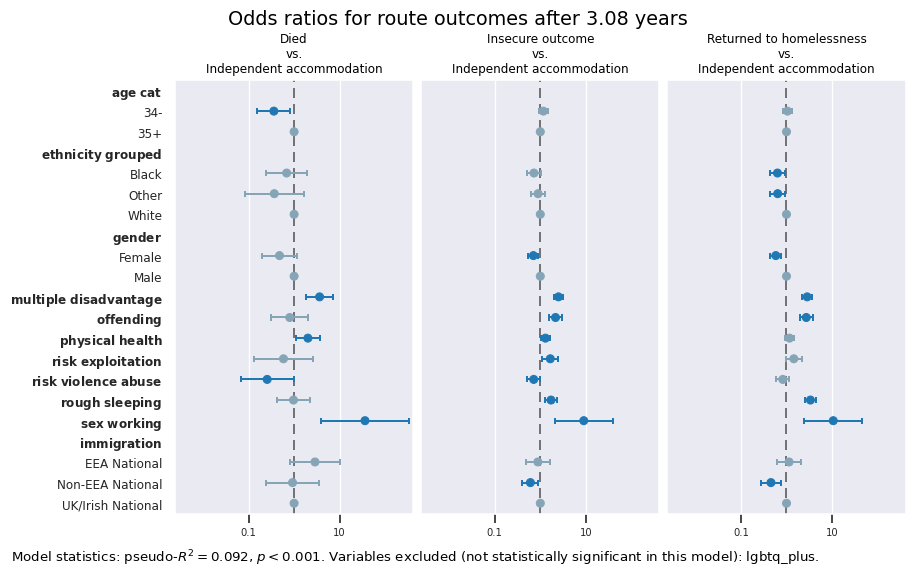

```python
figure_minor_i += 1
ref_cats_used = {k: v for k, v in ref_cats.items() if k in ["gender", "age_cat", "ethnicity_grouped", "uk_immigration_status"]}
shorter_iv = {r"uk\ immigration\ status": "immigration"}
cols_removed = cols_to_remove_MD
cols_removed = [col for col in cols_to_remove_MD if col != "substance_use" and col != "mental_health"]
fig_str = plot_odds_r(dv_str, dv.cat.categories[0], ref_cats_used, results_or_final, replacements=shorter_iv, cols_removed=cols_removed)
plt.show(block=False)
```

### Separate needs (Non-MD) iterations

```python
# Reset prev_results
results, summary, results_or = multinomial_regression(selected_dv, selected_xc[sel_block_ch_d], [], dummy_cols)
```

#### MNLogit iteration 5: separate needs

**Results**

```python
results, summary, results_or = multinomial_regression(selected_dv, selected_xc[sel_block_ch_d], cols_to_remove_nonMD, dummy_cols)
```

```
Optimization terminated successfully.
         Current function value: 1.034524
         Iterations 9
```

MNLogit Regression Results

| Dep. Variable: | rt_outcome | No. Observations: | 2600 |
| --- | --- | --- | --- |
| Model: | MNLogit | Df Residuals: | 2555 |
| Method: | MLE | Df Model: | 42 |
| Date: | Sun, 21 Jun 2026 | Pseudo R-squ.: | 0.1137 |
| Time: | 14:49:26 | Log-Likelihood: | -2689.8 |
| converged: | True | LL-Null: | -3034.9 |
| Covariance Type: | nonrobust | LLR p-value: | 3.195e-118 |

| rt_outcome=Insecure outcome | coef | std err | z | P>\|z\| | [0.025 | 0.975] |
| --- | --- | --- | --- | --- | --- | --- |
| (Intercept) | -0.9019 | 0.134 | -6.723 | 0.000 | -1.165 | -0.639 |
| gender_Female | -0.2767 | 0.131 | -2.110 | 0.035 | -0.534 | -0.020 |
| age_cat_34- | 0.2760 | 0.114 | 2.427 | 0.015 | 0.053 | 0.499 |
| ethnicity_grouped_Black | -0.1502 | 0.172 | -0.873 | 0.383 | -0.487 | 0.187 |
| ethnicity_grouped_Other | 0.0182 | 0.176 | 0.103 | 0.918 | -0.326 | 0.363 |
| uk_immigration_status_Non-EEA National | -0.4596 | 0.210 | -2.191 | 0.028 | -0.871 | -0.049 |
| uk_immigration_status_EEA National | -0.0988 | 0.309 | -0.319 | 0.749 | -0.705 | 0.507 |
| offending | 1.0631 | 0.159 | 6.676 | 0.000 | 0.751 | 1.375 |
| physical_health | 0.2502 | 0.114 | 2.191 | 0.028 | 0.026 | 0.474 |
| mental_health | 0.1168 | 0.118 | 0.990 | 0.322 | -0.114 | 0.348 |
| substance_use | 1.2065 | 0.115 | 10.452 | 0.000 | 0.980 | 1.433 |
| rough_sleeping | 0.4562 | 0.150 | 3.039 | 0.002 | 0.162 | 0.750 |
| sex_working | 1.9909 | 0.759 | 2.625 | 0.009 | 0.504 | 3.478 |
| risk_violence_abuse | 0.0421 | 0.166 | 0.253 | 0.800 | -0.283 | 0.368 |
| risk_exploitation | 0.3929 | 0.207 | 1.902 | 0.057 | -0.012 | 0.798 |
| rt_outcome=Returned to homelessness | coef | std err | z | P>\|z\| | [0.025 | 0.975] |
| (Intercept) | -1.2178 | 0.144 | -8.475 | 0.000 | -1.499 | -0.936 |
| gender_Female | -0.4130 | 0.143 | -2.885 | 0.004 | -0.694 | -0.132 |
| age_cat_34- | 0.2254 | 0.120 | 1.875 | 0.061 | -0.010 | 0.461 |
| ethnicity_grouped_Black | -0.1932 | 0.189 | -1.022 | 0.307 | -0.564 | 0.177 |
| ethnicity_grouped_Other | -0.2467 | 0.199 | -1.241 | 0.215 | -0.636 | 0.143 |
| uk_immigration_status_Non-EEA National | -0.7177 | 0.254 | -2.829 | 0.005 | -1.215 | -0.221 |
| uk_immigration_status_EEA National | 0.1185 | 0.318 | 0.373 | 0.709 | -0.505 | 0.742 |
| offending | 1.3153 | 0.161 | 8.178 | 0.000 | 1.000 | 1.630 |
| physical_health | 0.1450 | 0.120 | 1.206 | 0.228 | -0.091 | 0.381 |
| mental_health | -0.1307 | 0.124 | -1.053 | 0.292 | -0.374 | 0.113 |
| substance_use | 1.6705 | 0.125 | 13.323 | 0.000 | 1.425 | 1.916 |
| rough_sleeping | 1.0925 | 0.147 | 7.432 | 0.000 | 0.804 | 1.381 |
| sex_working | 2.1203 | 0.764 | 2.775 | 0.006 | 0.623 | 3.618 |
| risk_violence_abuse | 0.2098 | 0.174 | 1.207 | 0.227 | -0.131 | 0.550 |
| risk_exploitation | 0.2289 | 0.218 | 1.051 | 0.293 | -0.198 | 0.656 |
| rt_outcome=Died | coef | std err | z | P>\|z\| | [0.025 | 0.975] |
| (Intercept) | -3.6146 | 0.444 | -8.143 | 0.000 | -4.485 | -2.745 |
| gender_Female | -0.5950 | 0.463 | -1.285 | 0.199 | -1.502 | 0.312 |
| age_cat_34- | -0.8169 | 0.430 | -1.901 | 0.057 | -1.659 | 0.025 |
| ethnicity_grouped_Black | -0.0986 | 0.540 | -0.183 | 0.855 | -1.156 | 0.959 |
| ethnicity_grouped_Other | -0.7722 | 0.756 | -1.021 | 0.307 | -2.254 | 0.710 |
| uk_immigration_status_Non-EEA National | -0.0893 | 0.678 | -0.132 | 0.895 | -1.418 | 1.239 |
| uk_immigration_status_EEA National | 0.9743 | 0.662 | 1.473 | 0.141 | -0.322 | 2.271 |
| offending | 0.1768 | 0.470 | 0.377 | 0.706 | -0.743 | 1.097 |
| physical_health | 0.7079 | 0.315 | 2.249 | 0.025 | 0.091 | 1.325 |
| mental_health | -0.2637 | 0.333 | -0.793 | 0.428 | -0.916 | 0.388 |
| substance_use | 1.9384 | 0.387 | 5.014 | 0.000 | 1.181 | 2.696 |
| rough_sleeping | -0.1396 | 0.438 | -0.319 | 0.750 | -0.997 | 0.718 |
| sex_working | 3.4004 | 1.139 | 2.985 | 0.003 | 1.168 | 5.633 |
| risk_violence_abuse | -0.8898 | 0.686 | -1.298 | 0.194 | -2.233 | 0.454 |
| risk_exploitation | -0.6865 | 0.760 | -0.903 | 0.366 | -2.176 | 0.803 |

Variables removed: ['lgbtq_plus', 'multiple_disadvantage']

|  |  | p | * | odds_r | [0.025 | 0.975] | prev_coef | coef | diff_pct |
| --- | --- | --- | --- | --- | --- | --- | --- | --- | --- |
| ethnicity_grouped_Black | Returned to homelessness | 0.307 |  | 0.824 | 0.569 | 1.194 | -0.180 | -0.193 | 7.300 |
|  | Insecure outcome | 0.383 |  | 0.861 | 0.614 | 1.206 | -0.132 | -0.150 | 14.000 |
|  | Died | 0.855 |  | 0.906 | 0.315 | 2.610 | 0.108 | -0.099 | -191.400 |
| mental_health | Died | 0.428 |  | 0.768 | 0.400 | 1.474 | -1.019 | -0.264 | -74.100 |
|  | Insecure outcome | 0.322 |  | 1.124 | 0.892 | 1.416 | 0.194 | 0.117 | -39.900 |
|  | Returned to homelessness | 0.292 |  | 0.878 | 0.688 | 1.119 | -0.105 | -0.131 | 24.400 |
| ethnicity_grouped_Other | Died | 0.307 |  | 0.462 | 0.105 | 2.034 | -0.358 | -0.772 | 115.900 |
|  | Insecure outcome | 0.918 |  | 1.018 | 0.722 | 1.437 | 0.066 | 0.018 | -72.500 |
|  | Returned to homelessness | 0.215 |  | 0.781 | 0.529 | 1.154 | -0.153 | -0.247 | 61.500 |
| risk_violence_abuse | Insecure outcome | 0.800 |  | 1.043 | 0.753 | 1.444 | -0.008 | 0.042 | -654.400 |
|  | Returned to homelessness | 0.227 |  | 1.233 | 0.877 | 1.734 | 0.166 | 0.210 | 26.700 |
|  | Died | 0.194 |  | 0.411 | 0.107 | 1.575 | -0.941 | -0.890 | -5.400 |
| uk_immigration_status_EEA National | Returned to homelessness | 0.709 |  | 1.126 | 0.604 | 2.099 | 0.424 | 0.118 | -72.100 |
|  | Died | 0.141 |  | 2.649 | 0.724 | 9.688 | 1.099 | 0.974 | -11.300 |
|  | Insecure outcome | 0.749 |  | 0.906 | 0.494 | 1.661 | 0.267 | -0.099 | -136.900 |
| risk_exploitation | Insecure outcome | 0.057 |  | 1.481 | 0.988 | 2.220 | 0.557 | 0.393 | -29.500 |
|  | Returned to homelessness | 0.293 |  | 1.257 | 0.820 | 1.927 | 0.398 | 0.229 | -42.500 |
|  | Died | 0.366 |  | 0.503 | 0.114 | 2.232 | -0.493 | -0.687 | 39.200 |
| physical_health | Insecure outcome | 0.028 | * | 1.284 | 1.027 | 1.607 | 0.318 | 0.250 | -21.300 |
|  | Died | 0.025 | * | 2.030 | 1.095 | 3.762 | 0.633 | 0.708 | 11.900 |
|  | Returned to homelessness | 0.228 |  | 1.156 | 0.913 | 1.463 | 0.147 | 0.145 | -1.300 |
| age_cat_34- | Insecure outcome | 0.015 | * | 1.318 | 1.055 | 1.647 | 0.285 | 0.276 | -3.300 |
|  | Died | 0.057 |  | 0.442 | 0.190 | 1.026 | -0.471 | -0.817 | 73.400 |
|  | Returned to homelessness | 0.061 |  | 1.253 | 0.990 | 1.586 | 0.163 | 0.225 | 38.300 |
| uk_immigration_status_Non-EEA National | Returned to homelessness | 0.005 | * | 0.488 | 0.297 | 0.802 | -0.779 | -0.718 | -7.900 |
|  | Died | 0.895 |  | 0.915 | 0.242 | 3.453 | 0.266 | -0.089 | -133.600 |
|  | Insecure outcome | 0.028 | * | 0.632 | 0.419 | 0.953 | -0.497 | -0.460 | -7.600 |
| gender_Female | Insecure outcome | 0.035 | * | 0.758 | 0.586 | 0.981 | -0.236 | -0.277 | 17.200 |
|  | Died | 0.199 |  | 0.552 | 0.223 | 1.367 | -0.541 | -0.595 | 9.900 |
|  | Returned to homelessness | 0.004 | * | 0.662 | 0.500 | 0.876 | -0.370 | -0.413 | 11.700 |
| sex_working | Returned to homelessness | 0.006 | * | 8.334 | 1.864 | 37.266 | 1.906 | 2.120 | 11.200 |
|  | Insecure outcome | 0.009 | * | 7.322 | 1.656 | 32.384 | 1.675 | 1.991 | 18.800 |
|  | Died | 0.003 | * | 29.976 | 3.215 | 279.486 | 3.463 | 3.400 | -1.800 |
| rough_sleeping | Returned to homelessness | 0.000 | * | 2.982 | 2.235 | 3.977 | 1.173 | 1.093 | -6.800 |
|  | Died | 0.750 |  | 0.870 | 0.369 | 2.051 | -0.241 | -0.140 | -42.100 |
|  | Insecure outcome | 0.002 | * | 1.578 | 1.176 | 2.118 | 0.526 | 0.456 | -13.200 |
| offending | Died | 0.706 |  | 1.193 | 0.476 | 2.995 | -0.168 | 0.177 | -205.400 |
|  | Returned to homelessness | 0.000 | * | 3.726 | 2.718 | 5.106 | 1.484 | 1.315 | -11.400 |
|  | Insecure outcome | 0.000 | * | 2.895 | 2.119 | 3.956 | 1.215 | 1.063 | -12.500 |
| (Intercept) | Died | 0.000 | * | 0.027 | 0.011 | 0.064 | -4.225 | -3.615 | -14.500 |
|  | Returned to homelessness | 0.000 | * | 0.296 | 0.223 | 0.392 | -1.185 | -1.218 | 2.800 |
|  | Insecure outcome | 0.000 | * | 0.406 | 0.312 | 0.528 | -0.918 | -0.902 | -1.700 |
| substance_use | Returned to homelessness | 0.000 | * | 5.315 | 4.157 | 6.796 | 1.698 | 1.671 | -1.600 |
|  | Died | 0.000 | * | 6.948 | 3.257 | 14.822 | 2.411 | 1.938 | -19.600 |
|  | Insecure outcome | 0.000 | * | 3.342 | 2.665 | 4.190 | 1.250 | 1.207 | -3.500 |

```
Psuedo R^2: 0.11372560980977242
--------------------------------------------------
```

Major increase in pseudo $R^2$, so model with support needs explains much more of the variance. Separate support needs explain more variance than MD.

`ethnicity_grouped` no longer significant as variance better explained by other variables

#### MNLogit iteration 6: separate needs

**Results**

```python
cols_to_remove_nonMD += ["ethnicity_grouped"]
results, summary, results_or = multinomial_regression(selected_dv, selected_xc[sel_block_ch_d], cols_to_remove_nonMD, dummy_cols)
```

```
Optimization terminated successfully.
         Current function value: 1.034036
         Iterations 9
```

MNLogit Regression Results

| Dep. Variable: | rt_outcome | No. Observations: | 2679 |
| --- | --- | --- | --- |
| Model: | MNLogit | Df Residuals: | 2640 |
| Method: | MLE | Df Model: | 36 |
| Date: | Sun, 21 Jun 2026 | Pseudo R-squ.: | 0.1150 |
| Time: | 14:49:27 | Log-Likelihood: | -2770.2 |
| converged: | True | LL-Null: | -3130.0 |
| Covariance Type: | nonrobust | LLR p-value: | 4.575e-128 |

| rt_outcome=Insecure outcome | coef | std err | z | P>\|z\| | [0.025 | 0.975] |
| --- | --- | --- | --- | --- | --- | --- |
| (Intercept) | -0.9792 | 0.126 | -7.747 | 0.000 | -1.227 | -0.731 |
| gender_Female | -0.2549 | 0.129 | -1.983 | 0.047 | -0.507 | -0.003 |
| age_cat_34- | 0.2878 | 0.112 | 2.570 | 0.010 | 0.068 | 0.507 |
| uk_immigration_status_Non-EEA National | -0.5506 | 0.187 | -2.945 | 0.003 | -0.917 | -0.184 |
| uk_immigration_status_EEA National | -0.0995 | 0.308 | -0.323 | 0.746 | -0.703 | 0.504 |
| offending | 1.0348 | 0.157 | 6.604 | 0.000 | 0.728 | 1.342 |
| physical_health | 0.2527 | 0.112 | 2.251 | 0.024 | 0.033 | 0.473 |
| mental_health | 0.1606 | 0.116 | 1.382 | 0.167 | -0.067 | 0.388 |
| substance_use | 1.2413 | 0.112 | 11.085 | 0.000 | 1.022 | 1.461 |
| rough_sleeping | 0.4805 | 0.148 | 3.255 | 0.001 | 0.191 | 0.770 |
| sex_working | 1.9790 | 0.759 | 2.606 | 0.009 | 0.491 | 3.467 |
| risk_violence_abuse | 0.0500 | 0.163 | 0.306 | 0.759 | -0.270 | 0.370 |
| risk_exploitation | 0.3875 | 0.203 | 1.909 | 0.056 | -0.010 | 0.785 |
| rt_outcome=Returned to homelessness | coef | std err | z | P>\|z\| | [0.025 | 0.975] |
| (Intercept) | -1.3239 | 0.136 | -9.737 | 0.000 | -1.590 | -1.057 |
| gender_Female | -0.3828 | 0.140 | -2.728 | 0.006 | -0.658 | -0.108 |
| age_cat_34- | 0.2245 | 0.118 | 1.896 | 0.058 | -0.008 | 0.457 |
| uk_immigration_status_Non-EEA National | -0.8614 | 0.230 | -3.743 | 0.000 | -1.313 | -0.410 |
| uk_immigration_status_EEA National | 0.1955 | 0.310 | 0.631 | 0.528 | -0.412 | 0.803 |
| offending | 1.2894 | 0.158 | 8.159 | 0.000 | 0.980 | 1.599 |
| physical_health | 0.1174 | 0.118 | 0.991 | 0.321 | -0.115 | 0.350 |
| mental_health | -0.0748 | 0.122 | -0.612 | 0.541 | -0.314 | 0.165 |
| substance_use | 1.7306 | 0.122 | 14.226 | 0.000 | 1.492 | 1.969 |
| rough_sleeping | 1.1062 | 0.145 | 7.641 | 0.000 | 0.823 | 1.390 |
| sex_working | 2.1542 | 0.765 | 2.815 | 0.005 | 0.654 | 3.654 |
| risk_violence_abuse | 0.1727 | 0.172 | 1.007 | 0.314 | -0.163 | 0.509 |
| risk_exploitation | 0.2163 | 0.215 | 1.008 | 0.313 | -0.204 | 0.637 |
| rt_outcome=Died | coef | std err | z | P>\|z\| | [0.025 | 0.975] |
| (Intercept) | -3.7452 | 0.418 | -8.967 | 0.000 | -4.564 | -2.927 |
| gender_Female | -0.3014 | 0.413 | -0.729 | 0.466 | -1.112 | 0.509 |
| age_cat_34- | -0.8754 | 0.427 | -2.050 | 0.040 | -1.712 | -0.039 |
| uk_immigration_status_Non-EEA National | -0.3472 | 0.626 | -0.554 | 0.579 | -1.575 | 0.880 |
| uk_immigration_status_EEA National | 0.9684 | 0.656 | 1.476 | 0.140 | -0.318 | 2.255 |
| offending | 0.1360 | 0.467 | 0.291 | 0.771 | -0.779 | 1.051 |
| physical_health | 0.7982 | 0.308 | 2.589 | 0.010 | 0.194 | 1.403 |
| mental_health | -0.1926 | 0.327 | -0.589 | 0.556 | -0.833 | 0.448 |
| substance_use | 1.9259 | 0.366 | 5.259 | 0.000 | 1.208 | 2.644 |
| rough_sleeping | -0.1646 | 0.435 | -0.378 | 0.705 | -1.018 | 0.689 |
| sex_working | 3.2566 | 1.118 | 2.912 | 0.004 | 1.064 | 5.449 |
| risk_violence_abuse | -1.0477 | 0.675 | -1.553 | 0.120 | -2.370 | 0.275 |
| risk_exploitation | -0.7505 | 0.757 | -0.992 | 0.321 | -2.233 | 0.732 |

Variables removed: ['lgbtq_plus', 'multiple_disadvantage', 'ethnicity_grouped']

|  |  | p | * | odds_r | [0.025 | 0.975] | prev_coef | coef | diff_pct |
| --- | --- | --- | --- | --- | --- | --- | --- | --- | --- |
| mental_health | Died | 0.556 |  | 0.825 | 0.435 | 1.565 | -0.264 | -0.193 | -27.000 |
|  | Insecure outcome | 0.167 |  | 1.174 | 0.935 | 1.475 | 0.117 | 0.161 | 37.500 |
|  | Returned to homelessness | 0.541 |  | 0.928 | 0.730 | 1.179 | -0.131 | -0.075 | -42.800 |
| uk_immigration_status_EEA National | Returned to homelessness | 0.528 |  | 1.216 | 0.662 | 2.233 | 0.118 | 0.195 | 65.000 |
|  | Insecure outcome | 0.746 |  | 0.905 | 0.495 | 1.655 | -0.099 | -0.099 | 0.700 |
|  | Died | 0.140 |  | 2.634 | 0.728 | 9.533 | 0.974 | 0.968 | -0.600 |
| risk_violence_abuse | Died | 0.120 |  | 0.351 | 0.093 | 1.316 | -0.890 | -1.048 | 17.700 |
|  | Insecure outcome | 0.759 |  | 1.051 | 0.763 | 1.448 | 0.042 | 0.050 | 18.800 |
|  | Returned to homelessness | 0.314 |  | 1.189 | 0.849 | 1.663 | 0.210 | 0.173 | -17.700 |
| risk_exploitation | Died | 0.321 |  | 0.472 | 0.107 | 2.080 | -0.687 | -0.750 | 9.300 |
|  | Returned to homelessness | 0.313 |  | 1.241 | 0.815 | 1.890 | 0.229 | 0.216 | -5.500 |
|  | Insecure outcome | 0.056 |  | 1.473 | 0.990 | 2.193 | 0.393 | 0.388 | -1.400 |
| age_cat_34- | Insecure outcome | 0.010 | * | 1.333 | 1.071 | 1.661 | 0.276 | 0.288 | 4.300 |
|  | Died | 0.040 | * | 0.417 | 0.180 | 0.962 | -0.817 | -0.875 | 7.200 |
|  | Returned to homelessness | 0.058 |  | 1.252 | 0.992 | 1.579 | 0.225 | 0.224 | -0.400 |
| physical_health | Died | 0.010 | * | 2.222 | 1.214 | 4.066 | 0.708 | 0.798 | 12.800 |
|  | Returned to homelessness | 0.321 |  | 1.125 | 0.892 | 1.418 | 0.145 | 0.117 | -19.000 |
|  | Insecure outcome | 0.024 | * | 1.287 | 1.033 | 1.604 | 0.250 | 0.253 | 1.000 |
| gender_Female | Insecure outcome | 0.047 | * | 0.775 | 0.602 | 0.997 | -0.277 | -0.255 | -7.900 |
|  | Returned to homelessness | 0.006 | * | 0.682 | 0.518 | 0.898 | -0.413 | -0.383 | -7.300 |
|  | Died | 0.466 |  | 0.740 | 0.329 | 1.663 | -0.595 | -0.301 | -49.300 |
| sex_working | Died | 0.004 | * | 25.961 | 2.899 | 232.453 | 3.400 | 3.257 | -4.200 |
|  | Returned to homelessness | 0.005 | * | 8.621 | 1.924 | 38.632 | 2.120 | 2.154 | 1.600 |
|  | Insecure outcome | 0.009 | * | 7.236 | 1.633 | 32.050 | 1.991 | 1.979 | -0.600 |
| uk_immigration_status_Non-EEA National | Returned to homelessness | 0.000 | * | 0.423 | 0.269 | 0.663 | -0.718 | -0.861 | 20.000 |
|  | Died | 0.579 |  | 0.707 | 0.207 | 2.411 | -0.089 | -0.347 | 288.800 |
|  | Insecure outcome | 0.003 | * | 0.577 | 0.400 | 0.832 | -0.460 | -0.551 | 19.800 |
| rough_sleeping | Died | 0.705 |  | 0.848 | 0.361 | 1.991 | -0.140 | -0.165 | 17.800 |
|  | Insecure outcome | 0.001 | * | 1.617 | 1.211 | 2.160 | 0.456 | 0.481 | 5.300 |
|  | Returned to homelessness | 0.000 | * | 3.023 | 2.276 | 4.015 | 1.093 | 1.106 | 1.300 |
| offending | Returned to homelessness | 0.000 | * | 3.631 | 2.663 | 4.949 | 1.315 | 1.289 | -2.000 |
|  | Died | 0.771 |  | 1.146 | 0.459 | 2.860 | 0.177 | 0.136 | -23.100 |
|  | Insecure outcome | 0.000 | * | 2.815 | 2.070 | 3.826 | 1.063 | 1.035 | -2.700 |
| (Intercept) | Died | 0.000 | * | 0.024 | 0.010 | 0.054 | -3.615 | -3.745 | 3.600 |
|  | Returned to homelessness | 0.000 | * | 0.266 | 0.204 | 0.347 | -1.218 | -1.324 | 8.700 |
|  | Insecure outcome | 0.000 | * | 0.376 | 0.293 | 0.481 | -0.902 | -0.979 | 8.600 |
| substance_use | Insecure outcome | 0.000 | * | 3.460 | 2.778 | 4.309 | 1.207 | 1.241 | 2.900 |
|  | Died | 0.000 | * | 6.861 | 3.347 | 14.065 | 1.938 | 1.926 | -0.600 |
|  | Returned to homelessness | 0.000 | * | 5.644 | 4.447 | 7.164 | 1.671 | 1.731 | 3.600 |

```
Psuedo R^2: 0.11495505387250826
--------------------------------------------------
```

`mental_health` no longer significant as variance better explained by other variables

#### MNLogit iteration 7: separate needs

**Results**

```python
cols_to_remove_nonMD += ["mental_health"]
results, summary, results_or = multinomial_regression(selected_dv, selected_xc[sel_block_ch_d], cols_to_remove_nonMD, dummy_cols)
```

```
Optimization terminated successfully.
         Current function value: 1.034987
         Iterations 9
```

MNLogit Regression Results

| Dep. Variable: | rt_outcome | No. Observations: | 2679 |
| --- | --- | --- | --- |
| Model: | MNLogit | Df Residuals: | 2643 |
| Method: | MLE | Df Model: | 33 |
| Date: | Sun, 21 Jun 2026 | Pseudo R-squ.: | 0.1141 |
| Time: | 14:49:28 | Log-Likelihood: | -2772.7 |
| converged: | True | LL-Null: | -3130.0 |
| Covariance Type: | nonrobust | LLR p-value: | 5.245e-129 |

| rt_outcome=Insecure outcome | coef | std err | z | P>\|z\| | [0.025 | 0.975] |
| --- | --- | --- | --- | --- | --- | --- |
| (Intercept) | -0.8970 | 0.112 | -8.045 | 0.000 | -1.116 | -0.678 |
| gender_Female | -0.2367 | 0.128 | -1.853 | 0.064 | -0.487 | 0.014 |
| age_cat_34- | 0.3011 | 0.112 | 2.700 | 0.007 | 0.082 | 0.520 |
| uk_immigration_status_Non-EEA National | -0.5586 | 0.187 | -2.992 | 0.003 | -0.924 | -0.193 |
| uk_immigration_status_EEA National | -0.1259 | 0.307 | -0.409 | 0.682 | -0.729 | 0.477 |
| offending | 1.0425 | 0.157 | 6.659 | 0.000 | 0.736 | 1.349 |
| physical_health | 0.2642 | 0.112 | 2.362 | 0.018 | 0.045 | 0.483 |
| substance_use | 1.2672 | 0.111 | 11.468 | 0.000 | 1.051 | 1.484 |
| rough_sleeping | 0.4869 | 0.148 | 3.301 | 0.001 | 0.198 | 0.776 |
| sex_working | 1.9961 | 0.760 | 2.628 | 0.009 | 0.507 | 3.485 |
| risk_violence_abuse | 0.0499 | 0.163 | 0.306 | 0.760 | -0.270 | 0.370 |
| risk_exploitation | 0.3997 | 0.203 | 1.969 | 0.049 | 0.002 | 0.798 |
| rt_outcome=Returned to homelessness | coef | std err | z | P>\|z\| | [0.025 | 0.975] |
| (Intercept) | -1.3602 | 0.123 | -11.041 | 0.000 | -1.602 | -1.119 |
| gender_Female | -0.3871 | 0.139 | -2.775 | 0.006 | -0.661 | -0.114 |
| age_cat_34- | 0.2180 | 0.118 | 1.849 | 0.064 | -0.013 | 0.449 |
| uk_immigration_status_Non-EEA National | -0.8606 | 0.230 | -3.740 | 0.000 | -1.312 | -0.410 |
| uk_immigration_status_EEA National | 0.2111 | 0.309 | 0.683 | 0.495 | -0.395 | 0.817 |
| offending | 1.2859 | 0.158 | 8.145 | 0.000 | 0.976 | 1.595 |
| physical_health | 0.1136 | 0.118 | 0.962 | 0.336 | -0.118 | 0.345 |
| substance_use | 1.7165 | 0.120 | 14.344 | 0.000 | 1.482 | 1.951 |
| rough_sleeping | 1.1021 | 0.145 | 7.616 | 0.000 | 0.819 | 1.386 |
| sex_working | 2.1514 | 0.765 | 2.812 | 0.005 | 0.652 | 3.651 |
| risk_violence_abuse | 0.1693 | 0.171 | 0.987 | 0.323 | -0.167 | 0.505 |
| risk_exploitation | 0.2143 | 0.214 | 1.000 | 0.317 | -0.206 | 0.634 |
| rt_outcome=Died | coef | std err | z | P>\|z\| | [0.025 | 0.975] |
| (Intercept) | -3.8457 | 0.387 | -9.938 | 0.000 | -4.604 | -3.087 |
| gender_Female | -0.3190 | 0.412 | -0.775 | 0.438 | -1.126 | 0.488 |
| age_cat_34- | -0.8965 | 0.425 | -2.108 | 0.035 | -1.730 | -0.063 |
| uk_immigration_status_Non-EEA National | -0.3271 | 0.625 | -0.523 | 0.601 | -1.552 | 0.898 |
| uk_immigration_status_EEA National | 1.0149 | 0.652 | 1.557 | 0.120 | -0.263 | 2.293 |
| offending | 0.1236 | 0.466 | 0.265 | 0.791 | -0.790 | 1.037 |
| physical_health | 0.7938 | 0.308 | 2.576 | 0.010 | 0.190 | 1.398 |
| substance_use | 1.9027 | 0.364 | 5.232 | 0.000 | 1.190 | 2.616 |
| rough_sleeping | -0.1769 | 0.435 | -0.407 | 0.684 | -1.030 | 0.676 |
| sex_working | 3.2239 | 1.116 | 2.889 | 0.004 | 1.036 | 5.411 |
| risk_violence_abuse | -1.0595 | 0.673 | -1.574 | 0.115 | -2.378 | 0.259 |
| risk_exploitation | -0.7554 | 0.756 | -0.999 | 0.318 | -2.237 | 0.727 |

Variables removed: ['lgbtq_plus', 'multiple_disadvantage', 'ethnicity_grouped', 'mental_health']

|  |  | p | * | odds_r | [0.025 | 0.975] | prev_coef | coef | diff_pct |
| --- | --- | --- | --- | --- | --- | --- | --- | --- | --- |
| uk_immigration_status_EEA National | Insecure outcome | 0.682 |  | 0.882 | 0.483 | 1.611 | -0.099 | -0.126 | 26.500 |
|  | Died | 0.120 |  | 2.759 | 0.769 | 9.903 | 0.968 | 1.015 | 4.800 |
|  | Returned to homelessness | 0.495 |  | 1.235 | 0.674 | 2.264 | 0.195 | 0.211 | 8.000 |
| risk_violence_abuse | Insecure outcome | 0.760 |  | 1.051 | 0.763 | 1.447 | 0.050 | 0.050 | -0.200 |
|  | Died | 0.115 |  | 0.347 | 0.093 | 1.296 | -1.048 | -1.059 | 1.100 |
|  | Returned to homelessness | 0.323 |  | 1.184 | 0.846 | 1.658 | 0.173 | 0.169 | -2.000 |
| risk_exploitation | Died | 0.318 |  | 0.470 | 0.107 | 2.068 | -0.750 | -0.755 | 0.600 |
|  | Returned to homelessness | 0.317 |  | 1.239 | 0.814 | 1.886 | 0.216 | 0.214 | -0.900 |
|  | Insecure outcome | 0.049 | * | 1.491 | 1.002 | 2.220 | 0.388 | 0.400 | 3.100 |
| physical_health | Died | 0.010 | * | 2.212 | 1.209 | 4.046 | 0.798 | 0.794 | -0.600 |
|  | Returned to homelessness | 0.336 |  | 1.120 | 0.889 | 1.412 | 0.117 | 0.114 | -3.300 |
|  | Insecure outcome | 0.018 | * | 1.302 | 1.046 | 1.622 | 0.253 | 0.264 | 4.600 |
| age_cat_34- | Returned to homelessness | 0.064 |  | 1.244 | 0.987 | 1.567 | 0.224 | 0.218 | -2.900 |
|  | Insecure outcome | 0.007 | * | 1.351 | 1.086 | 1.681 | 0.288 | 0.301 | 4.600 |
|  | Died | 0.035 | * | 0.408 | 0.177 | 0.939 | -0.875 | -0.896 | 2.400 |
| gender_Female | Returned to homelessness | 0.006 | * | 0.679 | 0.517 | 0.893 | -0.383 | -0.387 | 1.100 |
|  | Insecure outcome | 0.064 |  | 0.789 | 0.614 | 1.014 | -0.255 | -0.237 | -7.100 |
|  | Died | 0.438 |  | 0.727 | 0.324 | 1.629 | -0.301 | -0.319 | 5.800 |
| sex_working | Returned to homelessness | 0.005 | * | 8.597 | 1.919 | 38.515 | 2.154 | 2.151 | -0.100 |
|  | Died | 0.004 | * | 25.126 | 2.819 | 223.926 | 3.257 | 3.224 | -1.000 |
|  | Insecure outcome | 0.009 | * | 7.360 | 1.661 | 32.624 | 1.979 | 1.996 | 0.900 |
| uk_immigration_status_Non-EEA National | Died | 0.601 |  | 0.721 | 0.212 | 2.454 | -0.347 | -0.327 | -5.800 |
|  | Insecure outcome | 0.003 | * | 0.572 | 0.397 | 0.825 | -0.551 | -0.559 | 1.400 |
|  | Returned to homelessness | 0.000 | * | 0.423 | 0.269 | 0.664 | -0.861 | -0.861 | -0.100 |
| rough_sleeping | Returned to homelessness | 0.000 | * | 3.011 | 2.267 | 3.998 | 1.106 | 1.102 | -0.400 |
|  | Died | 0.684 |  | 0.838 | 0.357 | 1.965 | -0.165 | -0.177 | 7.500 |
|  | Insecure outcome | 0.001 | * | 1.627 | 1.219 | 2.173 | 0.481 | 0.487 | 1.300 |
| offending | Returned to homelessness | 0.000 | * | 3.618 | 2.655 | 4.930 | 1.289 | 1.286 | -0.300 |
|  | Insecure outcome | 0.000 | * | 2.836 | 2.087 | 3.855 | 1.035 | 1.043 | 0.700 |
|  | Died | 0.791 |  | 1.132 | 0.454 | 2.822 | 0.136 | 0.124 | -9.100 |
| (Intercept) | Returned to homelessness | 0.000 | * | 0.257 | 0.202 | 0.327 | -1.324 | -1.360 | 2.700 |
|  | Died | 0.000 | * | 0.021 | 0.010 | 0.046 | -3.745 | -3.846 | 2.700 |
|  | Insecure outcome | 0.000 | * | 0.408 | 0.328 | 0.507 | -0.979 | -0.897 | -8.400 |
| substance_use | Insecure outcome | 0.000 | * | 3.551 | 2.860 | 4.410 | 1.241 | 1.267 | 2.100 |
|  | Returned to homelessness | 0.000 | * | 5.565 | 4.401 | 7.036 | 1.731 | 1.716 | -0.800 |
|  | Died | 0.000 | * | 6.704 | 3.287 | 13.674 | 1.926 | 1.903 | -1.200 |

```
Psuedo R^2: 0.11414056691312291
--------------------------------------------------
```

`risk_violence_abuse` no longer significant as variance better explained by other variables

**Results**

```python
cols_to_remove_nonMD += ["risk_violence_abuse"]
results, summary, results_or = multinomial_regression(selected_dv, selected_xc[sel_block_ch_d], cols_to_remove_nonMD, dummy_cols)
```

```
Optimization terminated successfully.
         Current function value: 1.035909
         Iterations 9
```

MNLogit Regression Results

| Dep. Variable: | rt_outcome | No. Observations: | 2679 |
| --- | --- | --- | --- |
| Model: | MNLogit | Df Residuals: | 2646 |
| Method: | MLE | Df Model: | 30 |
| Date: | Sun, 21 Jun 2026 | Pseudo R-squ.: | 0.1134 |
| Time: | 14:49:28 | Log-Likelihood: | -2775.2 |
| converged: | True | LL-Null: | -3130.0 |
| Covariance Type: | nonrobust | LLR p-value: | 4.940e-130 |

| rt_outcome=Insecure outcome | coef | std err | z | P>\|z\| | [0.025 | 0.975] |
| --- | --- | --- | --- | --- | --- | --- |
| (Intercept) | -0.8956 | 0.111 | -8.038 | 0.000 | -1.114 | -0.677 |
| gender_Female | -0.2263 | 0.123 | -1.847 | 0.065 | -0.466 | 0.014 |
| age_cat_34- | 0.3013 | 0.112 | 2.702 | 0.007 | 0.083 | 0.520 |
| uk_immigration_status_Non-EEA National | -0.5582 | 0.187 | -2.991 | 0.003 | -0.924 | -0.192 |
| uk_immigration_status_EEA National | -0.1259 | 0.307 | -0.409 | 0.682 | -0.728 | 0.477 |
| offending | 1.0432 | 0.156 | 6.667 | 0.000 | 0.737 | 1.350 |
| physical_health | 0.2661 | 0.112 | 2.383 | 0.017 | 0.047 | 0.485 |
| substance_use | 1.2672 | 0.110 | 11.469 | 0.000 | 1.051 | 1.484 |
| rough_sleeping | 0.4900 | 0.147 | 3.324 | 0.001 | 0.201 | 0.779 |
| sex_working | 2.0097 | 0.758 | 2.651 | 0.008 | 0.524 | 3.496 |
| risk_exploitation | 0.4123 | 0.199 | 2.067 | 0.039 | 0.021 | 0.803 |
| rt_outcome=Returned to homelessness | coef | std err | z | P>\|z\| | [0.025 | 0.975] |
| (Intercept) | -1.3571 | 0.123 | -11.023 | 0.000 | -1.598 | -1.116 |
| gender_Female | -0.3462 | 0.133 | -2.594 | 0.009 | -0.608 | -0.085 |
| age_cat_34- | 0.2216 | 0.118 | 1.881 | 0.060 | -0.009 | 0.453 |
| uk_immigration_status_Non-EEA National | -0.8602 | 0.230 | -3.738 | 0.000 | -1.311 | -0.409 |
| uk_immigration_status_EEA National | 0.2149 | 0.309 | 0.696 | 0.487 | -0.391 | 0.821 |
| offending | 1.2927 | 0.158 | 8.194 | 0.000 | 0.983 | 1.602 |
| physical_health | 0.1226 | 0.118 | 1.041 | 0.298 | -0.108 | 0.353 |
| substance_use | 1.7180 | 0.120 | 14.360 | 0.000 | 1.484 | 1.953 |
| rough_sleeping | 1.1037 | 0.145 | 7.629 | 0.000 | 0.820 | 1.387 |
| sex_working | 2.2058 | 0.763 | 2.891 | 0.004 | 0.710 | 3.701 |
| risk_exploitation | 0.2509 | 0.211 | 1.190 | 0.234 | -0.162 | 0.664 |
| rt_outcome=Died | coef | std err | z | P>\|z\| | [0.025 | 0.975] |
| (Intercept) | -3.8368 | 0.385 | -9.978 | 0.000 | -4.590 | -3.083 |
| gender_Female | -0.4763 | 0.405 | -1.176 | 0.240 | -1.270 | 0.318 |
| age_cat_34- | -0.9095 | 0.425 | -2.139 | 0.032 | -1.743 | -0.076 |
| uk_immigration_status_Non-EEA National | -0.3509 | 0.624 | -0.562 | 0.574 | -1.575 | 0.873 |
| uk_immigration_status_EEA National | 1.0363 | 0.651 | 1.592 | 0.111 | -0.239 | 2.312 |
| offending | 0.0769 | 0.468 | 0.164 | 0.869 | -0.840 | 0.994 |
| physical_health | 0.7478 | 0.308 | 2.427 | 0.015 | 0.144 | 1.352 |
| substance_use | 1.8761 | 0.363 | 5.168 | 0.000 | 1.165 | 2.588 |
| rough_sleeping | -0.1694 | 0.434 | -0.391 | 0.696 | -1.019 | 0.680 |
| sex_working | 2.8156 | 1.094 | 2.573 | 0.010 | 0.671 | 4.960 |
| risk_exploitation | -0.9080 | 0.751 | -1.209 | 0.227 | -2.380 | 0.564 |

Variables removed: ['lgbtq_plus', 'multiple_disadvantage', 'ethnicity_grouped', 'mental_health', 'risk_violence_abuse']

|  |  | p | * | odds_r | [0.025 | 0.975] | prev_coef | coef | diff_pct |
| --- | --- | --- | --- | --- | --- | --- | --- | --- | --- |
| uk_immigration_status_EEA National | Died | 0.111 |  | 2.819 | 0.787 | 10.092 | 1.015 | 1.036 | 2.100 |
|  | Insecure outcome | 0.682 |  | 0.882 | 0.483 | 1.611 | -0.126 | -0.126 | -0.000 |
|  | Returned to homelessness | 0.487 |  | 1.240 | 0.677 | 2.272 | 0.211 | 0.215 | 1.800 |
| risk_exploitation | Died | 0.227 |  | 0.403 | 0.093 | 1.758 | -0.755 | -0.908 | 20.200 |
|  | Returned to homelessness | 0.234 |  | 1.285 | 0.850 | 1.943 | 0.214 | 0.251 | 17.100 |
|  | Insecure outcome | 0.039 | * | 1.510 | 1.022 | 2.233 | 0.400 | 0.412 | 3.200 |
| physical_health | Died | 0.015 | * | 2.112 | 1.155 | 3.864 | 0.794 | 0.748 | -5.800 |
|  | Insecure outcome | 0.017 | * | 1.305 | 1.048 | 1.624 | 0.264 | 0.266 | 0.700 |
|  | Returned to homelessness | 0.298 |  | 1.130 | 0.897 | 1.424 | 0.114 | 0.123 | 8.000 |
| gender_Female | Died | 0.240 |  | 0.621 | 0.281 | 1.374 | -0.319 | -0.476 | 49.300 |
|  | Insecure outcome | 0.065 |  | 0.798 | 0.627 | 1.014 | -0.237 | -0.226 | -4.400 |
|  | Returned to homelessness | 0.009 | * | 0.707 | 0.545 | 0.919 | -0.387 | -0.346 | -10.600 |
| age_cat_34- | Returned to homelessness | 0.060 |  | 1.248 | 0.991 | 1.572 | 0.218 | 0.222 | 1.600 |
|  | Insecure outcome | 0.007 | * | 1.352 | 1.086 | 1.682 | 0.301 | 0.301 | 0.100 |
|  | Died | 0.032 | * | 0.403 | 0.175 | 0.927 | -0.896 | -0.909 | 1.400 |
| sex_working | Insecure outcome | 0.008 | * | 7.461 | 1.688 | 32.973 | 1.996 | 2.010 | 0.700 |
|  | Returned to homelessness | 0.004 | * | 9.078 | 2.034 | 40.507 | 2.151 | 2.206 | 2.500 |
|  | Died | 0.010 | * | 16.704 | 1.956 | 142.661 | 3.224 | 2.816 | -12.700 |
| uk_immigration_status_Non-EEA National | Died | 0.574 |  | 0.704 | 0.207 | 2.394 | -0.327 | -0.351 | 7.300 |
|  | Returned to homelessness | 0.000 | * | 0.423 | 0.269 | 0.664 | -0.861 | -0.860 | -0.000 |
|  | Insecure outcome | 0.003 | * | 0.572 | 0.397 | 0.825 | -0.559 | -0.558 | -0.100 |
| rough_sleeping | Insecure outcome | 0.001 | * | 1.632 | 1.223 | 2.179 | 0.487 | 0.490 | 0.700 |
|  | Died | 0.696 |  | 0.844 | 0.361 | 1.975 | -0.177 | -0.169 | -4.300 |
|  | Returned to homelessness | 0.000 | * | 3.015 | 2.271 | 4.004 | 1.102 | 1.104 | 0.100 |
| offending | Died | 0.869 |  | 1.080 | 0.432 | 2.702 | 0.124 | 0.077 | -37.800 |
|  | Returned to homelessness | 0.000 | * | 3.643 | 2.674 | 4.962 | 1.286 | 1.293 | 0.500 |
|  | Insecure outcome | 0.000 | * | 2.838 | 2.089 | 3.857 | 1.043 | 1.043 | 0.100 |
| (Intercept) | Died | 0.000 | * | 0.022 | 0.010 | 0.046 | -3.846 | -3.837 | -0.200 |
|  | Returned to homelessness | 0.000 | * | 0.257 | 0.202 | 0.328 | -1.360 | -1.357 | -0.200 |
|  | Insecure outcome | 0.000 | * | 0.408 | 0.328 | 0.508 | -0.897 | -0.896 | -0.200 |
| substance_use | Returned to homelessness | 0.000 | * | 5.574 | 4.409 | 7.047 | 1.716 | 1.718 | 0.100 |
|  | Died | 0.000 | * | 6.528 | 3.204 | 13.299 | 1.903 | 1.876 | -1.400 |
|  | Insecure outcome | 0.000 | * | 3.551 | 2.860 | 4.410 | 1.267 | 1.267 | -0.000 |

```
Psuedo R^2: 0.11335145479093445
--------------------------------------------------
```

Remaining results are significant.

## Final model

```python
from io import StringIO

display(summary)
results_or_final = results_or.drop(columns=["prev_coef", "coef", "diff_pct"], errors="ignore").swaplevel().sort_index()
results_or_with_pct = add_interpretation_cols(results_or_final)
with pd.option_context("display.float_format", "{:,.3f}".format):
    display(results_or_with_pct)

tbl_i = 0
comp_cats = [x[0] for x in results.summary().tables[1].data if x[0].startswith(results.model.endog_names)]
for tbl in results.summary2().tables:
    if tbl_i != 0:
        tbl = tbl.rename(columns={tbl.columns[0]: comp_cats[tbl_i - 1]})
    excel_output[f"MNLogit: '{dv_str}', table {tbl_i}"] = tbl
    tbl_i += 1
excel_output[f"MNLogit: '{dv_str}', odds ratios"] = results_or_with_pct
```

MNLogit Regression Results

| Dep. Variable: | rt_outcome | No. Observations: | 2679 |
| --- | --- | --- | --- |
| Model: | MNLogit | Df Residuals: | 2646 |
| Method: | MLE | Df Model: | 30 |
| Date: | Sun, 21 Jun 2026 | Pseudo R-squ.: | 0.1134 |
| Time: | 14:49:28 | Log-Likelihood: | -2775.2 |
| converged: | True | LL-Null: | -3130.0 |
| Covariance Type: | nonrobust | LLR p-value: | 4.940e-130 |

| rt_outcome=Insecure outcome | coef | std err | z | P>\|z\| | [0.025 | 0.975] |
| --- | --- | --- | --- | --- | --- | --- |
| (Intercept) | -0.8956 | 0.111 | -8.038 | 0.000 | -1.114 | -0.677 |
| gender_Female | -0.2263 | 0.123 | -1.847 | 0.065 | -0.466 | 0.014 |
| age_cat_34- | 0.3013 | 0.112 | 2.702 | 0.007 | 0.083 | 0.520 |
| uk_immigration_status_Non-EEA National | -0.5582 | 0.187 | -2.991 | 0.003 | -0.924 | -0.192 |
| uk_immigration_status_EEA National | -0.1259 | 0.307 | -0.409 | 0.682 | -0.728 | 0.477 |
| offending | 1.0432 | 0.156 | 6.667 | 0.000 | 0.737 | 1.350 |
| physical_health | 0.2661 | 0.112 | 2.383 | 0.017 | 0.047 | 0.485 |
| substance_use | 1.2672 | 0.110 | 11.469 | 0.000 | 1.051 | 1.484 |
| rough_sleeping | 0.4900 | 0.147 | 3.324 | 0.001 | 0.201 | 0.779 |
| sex_working | 2.0097 | 0.758 | 2.651 | 0.008 | 0.524 | 3.496 |
| risk_exploitation | 0.4123 | 0.199 | 2.067 | 0.039 | 0.021 | 0.803 |
| rt_outcome=Returned to homelessness | coef | std err | z | P>\|z\| | [0.025 | 0.975] |
| (Intercept) | -1.3571 | 0.123 | -11.023 | 0.000 | -1.598 | -1.116 |
| gender_Female | -0.3462 | 0.133 | -2.594 | 0.009 | -0.608 | -0.085 |
| age_cat_34- | 0.2216 | 0.118 | 1.881 | 0.060 | -0.009 | 0.453 |
| uk_immigration_status_Non-EEA National | -0.8602 | 0.230 | -3.738 | 0.000 | -1.311 | -0.409 |
| uk_immigration_status_EEA National | 0.2149 | 0.309 | 0.696 | 0.487 | -0.391 | 0.821 |
| offending | 1.2927 | 0.158 | 8.194 | 0.000 | 0.983 | 1.602 |
| physical_health | 0.1226 | 0.118 | 1.041 | 0.298 | -0.108 | 0.353 |
| substance_use | 1.7180 | 0.120 | 14.360 | 0.000 | 1.484 | 1.953 |
| rough_sleeping | 1.1037 | 0.145 | 7.629 | 0.000 | 0.820 | 1.387 |
| sex_working | 2.2058 | 0.763 | 2.891 | 0.004 | 0.710 | 3.701 |
| risk_exploitation | 0.2509 | 0.211 | 1.190 | 0.234 | -0.162 | 0.664 |
| rt_outcome=Died | coef | std err | z | P>\|z\| | [0.025 | 0.975] |
| (Intercept) | -3.8368 | 0.385 | -9.978 | 0.000 | -4.590 | -3.083 |
| gender_Female | -0.4763 | 0.405 | -1.176 | 0.240 | -1.270 | 0.318 |
| age_cat_34- | -0.9095 | 0.425 | -2.139 | 0.032 | -1.743 | -0.076 |
| uk_immigration_status_Non-EEA National | -0.3509 | 0.624 | -0.562 | 0.574 | -1.575 | 0.873 |
| uk_immigration_status_EEA National | 1.0363 | 0.651 | 1.592 | 0.111 | -0.239 | 2.312 |
| offending | 0.0769 | 0.468 | 0.164 | 0.869 | -0.840 | 0.994 |
| physical_health | 0.7478 | 0.308 | 2.427 | 0.015 | 0.144 | 1.352 |
| substance_use | 1.8761 | 0.363 | 5.168 | 0.000 | 1.165 | 2.588 |
| rough_sleeping | -0.1694 | 0.434 | -0.391 | 0.696 | -1.019 | 0.680 |
| sex_working | 2.8156 | 1.094 | 2.573 | 0.010 | 0.671 | 4.960 |
| risk_exploitation | -0.9080 | 0.751 | -1.209 | 0.227 | -2.380 | 0.564 |

Variables removed: ['lgbtq_plus', 'multiple_disadvantage', 'ethnicity_grouped', 'mental_health', 'risk_violence_abuse']

|  |  | p | * | odds_r | [0.025 | 0.975] | odds_r_d% | [0.025_d% | 0.975]_d% |
| --- | --- | --- | --- | --- | --- | --- | --- | --- | --- |
| Died | (Intercept) | 0.000 | * | 0.022 | 0.010 | 0.046 | -97.8% | -99.0% | -95.4% |
|  | age_cat_34- | 0.032 | * | 0.403 | 0.175 | 0.927 | -59.7% | -82.5% | -7.3% |
|  | gender_Female | 0.240 |  | 0.621 | 0.281 | 1.374 |  |  |  |
|  | offending | 0.869 |  | 1.080 | 0.432 | 2.702 |  |  |  |
|  | physical_health | 0.015 | * | 2.112 | 1.155 | 3.864 | 111.2% | 15.5% | 286.4% |
|  | risk_exploitation | 0.227 |  | 0.403 | 0.093 | 1.758 |  |  |  |
|  | rough_sleeping | 0.696 |  | 0.844 | 0.361 | 1.975 |  |  |  |
|  | sex_working | 0.010 | * | 16.704 | 1.956 | 142.661 | 1570.4% | 95.6% | 14166.1% |
|  | substance_use | 0.000 | * | 6.528 | 3.204 | 13.299 | 552.8% | 220.4% | 1229.9% |
|  | uk_immigration_status_EEA National | 0.111 |  | 2.819 | 0.787 | 10.092 |  |  |  |
|  | uk_immigration_status_Non-EEA National | 0.574 |  | 0.704 | 0.207 | 2.394 |  |  |  |
| Insecure outcome | (Intercept) | 0.000 | * | 0.408 | 0.328 | 0.508 | -59.2% | -67.2% | -49.2% |
|  | age_cat_34- | 0.007 | * | 1.352 | 1.086 | 1.682 | 35.2% | 8.6% | 68.2% |
|  | gender_Female | 0.065 |  | 0.798 | 0.627 | 1.014 |  |  |  |
|  | offending | 0.000 | * | 2.838 | 2.089 | 3.857 | 183.8% | 108.9% | 285.7% |
|  | physical_health | 0.017 | * | 1.305 | 1.048 | 1.624 | 30.5% | 4.8% | 62.4% |
|  | risk_exploitation | 0.039 | * | 1.510 | 1.022 | 2.233 | 51.0% | 2.2% | 123.3% |
|  | rough_sleeping | 0.001 | * | 1.632 | 1.223 | 2.179 | 63.2% | 22.3% | 117.9% |
|  | sex_working | 0.008 | * | 7.461 | 1.688 | 32.973 | 646.1% | 68.8% | 3197.3% |
|  | substance_use | 0.000 | * | 3.551 | 2.860 | 4.410 | 255.1% | 186.0% | 341.0% |
|  | uk_immigration_status_EEA National | 0.682 |  | 0.882 | 0.483 | 1.611 |  |  |  |
|  | uk_immigration_status_Non-EEA National | 0.003 | * | 0.572 | 0.397 | 0.825 | -42.8% | -60.3% | -17.5% |
| Returned to homelessness | (Intercept) | 0.000 | * | 0.257 | 0.202 | 0.328 | -74.3% | -79.8% | -67.2% |
|  | age_cat_34- | 0.060 |  | 1.248 | 0.991 | 1.572 |  |  |  |
|  | gender_Female | 0.009 | * | 0.707 | 0.545 | 0.919 | -29.3% | -45.5% | -8.1% |
|  | offending | 0.000 | * | 3.643 | 2.674 | 4.962 | 264.3% | 167.4% | 396.2% |
|  | physical_health | 0.298 |  | 1.130 | 0.897 | 1.424 |  |  |  |
|  | risk_exploitation | 0.234 |  | 1.285 | 0.850 | 1.943 |  |  |  |
|  | rough_sleeping | 0.000 | * | 3.015 | 2.271 | 4.004 | 201.5% | 127.1% | 300.4% |
|  | sex_working | 0.004 | * | 9.078 | 2.034 | 40.507 | 807.8% | 103.4% | 3950.7% |
|  | substance_use | 0.000 | * | 5.574 | 4.409 | 7.047 | 457.4% | 340.9% | 604.7% |
|  | uk_immigration_status_EEA National | 0.487 |  | 1.240 | 0.677 | 2.272 |  |  |  |
|  | uk_immigration_status_Non-EEA National | 0.000 | * | 0.423 | 0.269 | 0.664 | -57.7% | -73.1% | -33.6% |

## Visualisation

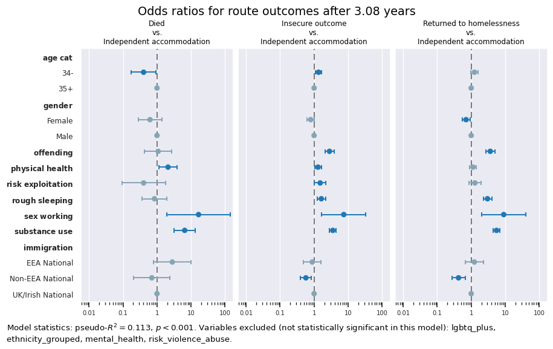

```python
figure_minor_i += 1
ref_cats_used = {k: v for k, v in ref_cats.items() if k in ["gender", "age_cat", "uk_immigration_status"]}
shorter_iv = {r"uk\ immigration\ status": "immigration"}
cols_removed = cols_to_remove_nonMD
cols_removed = [col for col in cols_to_remove_nonMD if col != "multiple_disadvantage"]
fig_str = plot_odds_r(dv_str, dv.cat.categories[0], ref_cats_used, results_or_final, replacements=shorter_iv, cols_removed=cols_removed)
plt.show(block=False)
```

# Outcomes 3.08 years after a person’s first route started

## Prepare DV

```python
# Get DV
dv_str = "Outcomes 3.08 years after a person's first route started"
dv = dv_dict[dv_str].iloc[:, 0].astype("category")
dv = dv.cat.reorder_categories(['Independent accommodation', 'Insecure outcome', 'Returned to homelessness', 'Died'])
```

## Prepare IVs

```python
selected_ch = {
    "demographics":  ["gender", "age_cat", "global_majority", "lgbtq_plus",
                      # "ethnicity_detailed", "ethnicity_grouped",
                      # "uk_immigration_status", "english_2nd_language",
                      ],
    "ethnicity_related": ["ethnicity_grouped", "uk_immigration_status"],
    "support_needs": ["offending", "physical_health", "mental_health", "substance_use", "multiple_disadvantage",
                      "rough_sleeping", "sex_working", "risk_violence_abuse", "risk_exploitation",],
    # "route_variables": ["referral_agency", "rt_duration_weeks", "rt_entry_point",]
}
cols_to_exclude = []
X, Xc, iv_df, iv_cols_used, ref_cats, binaries, dummy_cols = get_ivs(dv, cols_to_exclude, selected_ch)
```

## Model building

### Start with block for demographic variables

```python
block_ch = list(selected_ch.values())[0]
block_ch_d = ["(Intercept)"] + cols_with_dummies(block_ch, dummy_cols)
```

### Test associations between IVs for initial block

#### Cramer’s V

**Results**

p values indicated by asterisks: `***` if `p < 0.001`, `**` if `p < 0.01`, `*` if `p < 0.05`

```python
chi2_crv_results, disp = iv_assoc(iv_df, block_ch)
with pd.option_context("display.float_format", "{:,.3f}".format):
    display(disp)
```

| iv1 | iv2 | g | ac | gm | lp |
| --- | --- | --- | --- | --- | --- |
| gender | V | NaN | 0.157 | 0.051 | 0.183 |
|  | * | NaN | *** |  | *** |
| age_cat | V | 0.157 | NaN | 0.092 | 0.067 |
|  | * | *** | NaN | *** | ** |
| global_majority | V | 0.051 | 0.092 | NaN | 0.001 |
|  | * |  | *** | NaN |  |
| lgbtq_plus | V | 0.183 | 0.067 | 0.001 | NaN |
|  | * | *** | ** |  | NaN |

#### Variance Inflation Factor (VIF)

**Results**

```python
# Test multicollinearity with VIF
vif_data = vif(Xc[block_ch_d[1:]])
with pd.option_context("display.float_format", "{:,.3f}".format):
    display(vif_data)
```

| Feature | VIF |
| --- | --- |
| age_cat_34- | 1.376 |
| gender_Female | 1.241 |
| global_majority | 1.167 |
| lgbtq_plus | 1.080 |
| gender_Non-Binary | 1.025 |

### MNLogit iteration 0

**Results**

```python
cols_to_remove = []
values_to_remove = []
results, summary, results_or = multinomial_regression(dv, Xc[block_ch_d], cols_to_remove, dummy_cols)
```

MNLogit Regression Results

| Dep. Variable: | cli_outcome | No. Observations: | 2046 |
| --- | --- | --- | --- |
| Model: | MNLogit | Df Residuals: | 2028 |
| Method: | MLE | Df Model: | 15 |
| Date: | Sun, 21 Jun 2026 | Pseudo R-squ.: | 0.01766 |
| Time: | 14:49:31 | Log-Likelihood: | -2280.9 |
| converged: | False | LL-Null: | -2321.9 |
| Covariance Type: | nonrobust | LLR p-value: | 2.981e-11 |

| cli_outcome=Insecure outcome | coef | std err | z | P>\|z\| | [0.025 | 0.975] |
| --- | --- | --- | --- | --- | --- | --- |
| (Intercept) | -0.2005 | 0.076 | -2.636 | 0.008 | -0.350 | -0.051 |
| gender_Female | -0.1202 | 0.117 | -1.026 | 0.305 | -0.350 | 0.109 |
| gender_Non-Binary | -1.2713 | 1.129 | -1.126 | 0.260 | -3.484 | 0.941 |
| age_cat_34- | 0.1980 | 0.107 | 1.854 | 0.064 | -0.011 | 0.407 |
| global_majority | -0.6429 | 0.122 | -5.279 | 0.000 | -0.882 | -0.404 |
| lgbtq_plus | -0.0706 | 0.210 | -0.336 | 0.737 | -0.483 | 0.342 |
| cli_outcome=Returned to homelessness | coef | std err | z | P>\|z\| | [0.025 | 0.975] |
| (Intercept) | -0.5925 | 0.087 | -6.778 | 0.000 | -0.764 | -0.421 |
| gender_Female | -0.4324 | 0.145 | -2.975 | 0.003 | -0.717 | -0.148 |
| gender_Non-Binary | -0.7515 | 1.135 | -0.662 | 0.508 | -2.977 | 1.474 |
| age_cat_34- | 0.2904 | 0.125 | 2.318 | 0.020 | 0.045 | 0.536 |
| global_majority | -0.9519 | 0.156 | -6.098 | 0.000 | -1.258 | -0.646 |
| lgbtq_plus | -0.3692 | 0.275 | -1.343 | 0.179 | -0.908 | 0.169 |
| cli_outcome=Died | coef | std err | z | P>\|z\| | [0.025 | 0.975] |
| (Intercept) | -2.3667 | 0.188 | -12.618 | 0.000 | -2.734 | -1.999 |
| gender_Female | -0.2194 | 0.356 | -0.617 | 0.537 | -0.917 | 0.478 |
| gender_Non-Binary | -15.3194 | 4818.545 | -0.003 | 0.997 | -9459.494 | 9428.856 |
| age_cat_34- | -0.7372 | 0.366 | -2.012 | 0.044 | -1.455 | -0.019 |
| global_majority | -1.5653 | 0.528 | -2.964 | 0.003 | -2.600 | -0.530 |
| lgbtq_plus | -0.4180 | 0.738 | -0.567 | 0.571 | -1.864 | 1.028 |

|  | Odds Ratios | p | * | odds_r | [0.025 | 0.975] |
| --- | --- | --- | --- | --- | --- | --- |
| gender_Non-Binary | Returned to homelessness | 0.508 |  | 0.472 | 0.051 | 4.366 |
|  | Insecure outcome | 0.260 |  | 0.280 | 0.031 | 2.563 |
|  | Died | 0.997 |  | 0.000 | 0.000 | inf |
| lgbtq_plus | Died | 0.571 |  | 0.658 | 0.155 | 2.795 |
|  | Insecure outcome | 0.737 |  | 0.932 | 0.617 | 1.407 |
|  | Returned to homelessness | 0.179 |  | 0.691 | 0.403 | 1.185 |
| age_cat_34- | Died | 0.044 | * | 0.478 | 0.233 | 0.981 |
|  | Returned to homelessness | 0.020 | * | 1.337 | 1.046 | 1.709 |
|  | Insecure outcome | 0.064 |  | 1.219 | 0.989 | 1.503 |
| gender_Female | Returned to homelessness | 0.003 | * | 0.649 | 0.488 | 0.863 |
|  | Insecure outcome | 0.305 |  | 0.887 | 0.705 | 1.116 |
|  | Died | 0.537 |  | 0.803 | 0.400 | 1.613 |
| global_majority | Returned to homelessness | 0.000 | * | 0.386 | 0.284 | 0.524 |
|  | Insecure outcome | 0.000 | * | 0.526 | 0.414 | 0.668 |
|  | Died | 0.003 | * | 0.209 | 0.074 | 0.588 |
| (Intercept) | Returned to homelessness | 0.000 | * | 0.553 | 0.466 | 0.656 |
|  | Died | 0.000 | * | 0.094 | 0.065 | 0.135 |
|  | Insecure outcome | 0.008 | * | 0.818 | 0.705 | 0.950 |

```
Psuedo R^2: 0.017661638323938966
--------------------------------------------------
```

### MNLogit iteration 1

Recode `gender=Non-Binary` as missing because there are too few data points: recode variable.

**Results**

```python
selected_dv, selected_xc, sel_block_ch_d = dv_xc_remove_value(dv, Xc, block_ch_d, "gender_Non-Binary")
# cols_to_remove += ["gender_Non-Binary"]
results, summary, results_or = multinomial_regression(selected_dv, selected_xc[sel_block_ch_d], cols_to_remove, dummy_cols)
```

```
Optimization terminated successfully.
         Current function value: 1.115576
         Iterations 8
```

MNLogit Regression Results

| Dep. Variable: | cli_outcome | No. Observations: | 2040 |
| --- | --- | --- | --- |
| Model: | MNLogit | Df Residuals: | 2025 |
| Method: | MLE | Df Model: | 12 |
| Date: | Sun, 21 Jun 2026 | Pseudo R-squ.: | 0.01737 |
| Time: | 14:49:32 | Log-Likelihood: | -2275.8 |
| converged: | True | LL-Null: | -2316.0 |
| Covariance Type: | nonrobust | LLR p-value: | 3.374e-12 |

| cli_outcome=Insecure outcome | coef | std err | z | P>\|z\| | [0.025 | 0.975] |
| --- | --- | --- | --- | --- | --- | --- |
| (Intercept) | -0.2003 | 0.076 | -2.634 | 0.008 | -0.349 | -0.051 |
| gender_Female | -0.1201 | 0.117 | -1.025 | 0.305 | -0.350 | 0.109 |
| age_cat_34- | 0.1980 | 0.107 | 1.852 | 0.064 | -0.012 | 0.408 |
| global_majority | -0.6429 | 0.122 | -5.279 | 0.000 | -0.882 | -0.404 |
| lgbtq_plus | -0.0736 | 0.212 | -0.348 | 0.728 | -0.489 | 0.341 |
| cli_outcome=Returned to homelessness | coef | std err | z | P>\|z\| | [0.025 | 0.975] |
| (Intercept) | -0.5971 | 0.088 | -6.824 | 0.000 | -0.769 | -0.426 |
| gender_Female | -0.4353 | 0.145 | -2.994 | 0.003 | -0.720 | -0.150 |
| age_cat_34- | 0.2992 | 0.125 | 2.385 | 0.017 | 0.053 | 0.545 |
| global_majority | -0.9531 | 0.156 | -6.105 | 0.000 | -1.259 | -0.647 |
| lgbtq_plus | -0.3299 | 0.274 | -1.205 | 0.228 | -0.866 | 0.207 |
| cli_outcome=Died | coef | std err | z | P>\|z\| | [0.025 | 0.975] |
| (Intercept) | -2.3677 | 0.188 | -12.624 | 0.000 | -2.735 | -2.000 |
| gender_Female | -0.2198 | 0.356 | -0.618 | 0.537 | -0.917 | 0.477 |
| age_cat_34- | -0.7353 | 0.366 | -2.006 | 0.045 | -1.454 | -0.017 |
| global_majority | -1.5653 | 0.528 | -2.964 | 0.003 | -2.600 | -0.530 |
| lgbtq_plus | -0.4124 | 0.738 | -0.559 | 0.576 | -1.859 | 1.034 |

|  | Odds Ratios | p | * | odds_r | [0.025 | 0.975] |
| --- | --- | --- | --- | --- | --- | --- |
| lgbtq_plus | Insecure outcome | 0.728 |  | 0.929 | 0.613 | 1.407 |
|  | Returned to homelessness | 0.228 |  | 0.719 | 0.420 | 1.230 |
|  | Died | 0.576 |  | 0.662 | 0.156 | 2.812 |
| age_cat_34- | Insecure outcome | 0.064 |  | 1.219 | 0.989 | 1.503 |
|  | Returned to homelessness | 0.017 | * | 1.349 | 1.055 | 1.725 |
|  | Died | 0.045 | * | 0.479 | 0.234 | 0.983 |
| gender_Female | Insecure outcome | 0.305 |  | 0.887 | 0.705 | 1.116 |
|  | Returned to homelessness | 0.003 | * | 0.647 | 0.487 | 0.860 |
|  | Died | 0.537 |  | 0.803 | 0.400 | 1.612 |
| global_majority | Insecure outcome | 0.000 | * | 0.526 | 0.414 | 0.668 |
|  | Returned to homelessness | 0.000 | * | 0.386 | 0.284 | 0.524 |
|  | Died | 0.003 | * | 0.209 | 0.074 | 0.588 |
| (Intercept) | Insecure outcome | 0.008 | * | 0.818 | 0.705 | 0.950 |
|  | Returned to homelessness | 0.000 | * | 0.550 | 0.464 | 0.653 |
|  | Died | 0.000 | * | 0.094 | 0.065 | 0.135 |

```
Psuedo R^2: 0.017370109936201805
--------------------------------------------------
```

`lgbtq_plus` not significant as variance better explained by other variables

### MNLogit iteration 2

**Results**

```python
cols_to_remove += ["lgbtq_plus"]
results, summary, results_or = multinomial_regression(selected_dv, selected_xc[sel_block_ch_d], cols_to_remove, dummy_cols)
```

```
Optimization terminated successfully.
         Current function value: 1.111366
         Iterations 8
```

MNLogit Regression Results

| Dep. Variable: | cli_outcome | No. Observations: | 2494 |
| --- | --- | --- | --- |
| Model: | MNLogit | Df Residuals: | 2482 |
| Method: | MLE | Df Model: | 9 |
| Date: | Sun, 21 Jun 2026 | Pseudo R-squ.: | 0.02052 |
| Time: | 14:49:32 | Log-Likelihood: | -2771.7 |
| converged: | True | LL-Null: | -2829.8 |
| Covariance Type: | nonrobust | LLR p-value: | 8.176e-21 |

| cli_outcome=Insecure outcome | coef | std err | z | P>\|z\| | [0.025 | 0.975] |
| --- | --- | --- | --- | --- | --- | --- |
| (Intercept) | -0.2170 | 0.069 | -3.164 | 0.002 | -0.351 | -0.083 |
| gender_Female | -0.2127 | 0.107 | -1.989 | 0.047 | -0.422 | -0.003 |
| age_cat_34- | 0.1885 | 0.097 | 1.942 | 0.052 | -0.002 | 0.379 |
| global_majority | -0.6818 | 0.110 | -6.218 | 0.000 | -0.897 | -0.467 |
| cli_outcome=Returned to homelessness | coef | std err | z | P>\|z\| | [0.025 | 0.975] |
| (Intercept) | -0.6493 | 0.079 | -8.177 | 0.000 | -0.805 | -0.494 |
| gender_Female | -0.5250 | 0.133 | -3.959 | 0.000 | -0.785 | -0.265 |
| age_cat_34- | 0.3903 | 0.113 | 3.453 | 0.001 | 0.169 | 0.612 |
| global_majority | -1.0038 | 0.140 | -7.163 | 0.000 | -1.278 | -0.729 |
| cli_outcome=Died | coef | std err | z | P>\|z\| | [0.025 | 0.975] |
| (Intercept) | -2.2725 | 0.160 | -14.206 | 0.000 | -2.586 | -1.959 |
| gender_Female | -0.4408 | 0.331 | -1.332 | 0.183 | -1.089 | 0.208 |
| age_cat_34- | -0.9370 | 0.341 | -2.749 | 0.006 | -1.605 | -0.269 |
| global_majority | -1.2939 | 0.407 | -3.180 | 0.001 | -2.091 | -0.496 |

Variables removed: ['lgbtq_plus']

|  |  | p | * | odds_r | [0.025 | 0.975] | prev_coef | coef | diff_pct |
| --- | --- | --- | --- | --- | --- | --- | --- | --- | --- |
| age_cat_34- | Insecure outcome | 0.052 |  | 1.207 | 0.998 | 1.461 | 0.198 | 0.189 | -4.800 |
|  | Returned to homelessness | 0.001 | * | 1.477 | 1.184 | 1.844 | 0.299 | 0.390 | 30.500 |
|  | Died | 0.006 | * | 0.392 | 0.201 | 0.764 | -0.735 | -0.937 | 27.400 |
| gender_Female | Insecure outcome | 0.047 | * | 0.808 | 0.655 | 0.997 | -0.120 | -0.213 | 77.200 |
|  | Returned to homelessness | 0.000 | * | 0.592 | 0.456 | 0.767 | -0.435 | -0.525 | 20.600 |
|  | Died | 0.183 |  | 0.644 | 0.336 | 1.231 | -0.220 | -0.441 | 100.600 |
| global_majority | Insecure outcome | 0.000 | * | 0.506 | 0.408 | 0.627 | -0.643 | -0.682 | 6.000 |
|  | Returned to homelessness | 0.000 | * | 0.366 | 0.278 | 0.482 | -0.953 | -1.004 | 5.300 |
|  | Died | 0.001 | * | 0.274 | 0.124 | 0.609 | -1.565 | -1.294 | -17.300 |
| (Intercept) | Insecure outcome | 0.002 | * | 0.805 | 0.704 | 0.921 | -0.200 | -0.217 | 8.300 |
|  | Returned to homelessness | 0.000 | * | 0.522 | 0.447 | 0.610 | -0.597 | -0.649 | 8.700 |
|  | Died | 0.000 | * | 0.103 | 0.075 | 0.141 | -2.368 | -2.273 | -4.000 |

```
Psuedo R^2: 0.02052302627304947
--------------------------------------------------
```

All remaining variables have significant findings. All are associated with reducing the odds of negative outcomes (compared to independent accommodation), apart from being 34 or younger which is associated with increased odds of returning to homelessness.

### Add block for grouped ethnicity data and drop “global_majority”

```python
new_block_ch = selected_ch["ethnicity_related"]
sel_block_ch = [ch for ch in block_ch + new_block_ch if ch != "global_majority"]
sel_block_ch_d = [ch for ch in sel_block_ch_d + cols_with_dummies(new_block_ch, dummy_cols) if ch != "global_majority"]
```

### Test associations between IVs now a block has been added

#### Cramer’s V

**Results**

p values indicated by asterisks: `***` if `p < 0.001`, `**` if `p < 0.01`, `*` if `p < 0.05`

```python
chi2_crv_results, disp = iv_assoc(iv_df, sel_block_ch)
with pd.option_context("display.float_format", "{:,.3f}".format):
    display(disp)
```

| iv1 | iv2 | g | ac | lp | eg | uis |
| --- | --- | --- | --- | --- | --- | --- |
| gender | V | NaN | 0.132 | 0.190 | 0.066 | 0.069 |
|  | * | NaN | *** | *** | * | * |
| age_cat | V | 0.132 | NaN | 0.065 | 0.084 | 0.080 |
|  | * | *** | NaN | * | ** | ** |
| lgbtq_plus | V | 0.190 | 0.065 | NaN | 0.069 | 0.044 |
|  | * | *** | * | NaN |  |  |
| ethnicity_grouped | V | 0.066 | 0.084 | 0.069 | NaN | 0.401 |
|  | * | * | ** |  | NaN | *** |
| uk_immigration_status | V | 0.069 | 0.080 | 0.044 | 0.401 | NaN |
|  | * | * | ** |  | *** | NaN |

#### Variance Inflation Factor (VIF)

**Results**

```python
# Test multicollinearity with VIF
vif_data = vif(Xc[sel_block_ch_d[1:]])
with pd.option_context("display.float_format", "{:,.3f}".format):
    display(vif_data)
```

| Feature | VIF |
| --- | --- |
| uk_immigration_status_Non-EEA National | 1.588 |
| ethnicity_grouped_Black | 1.376 |
| age_cat_34- | 1.354 |
| ethnicity_grouped_Other | 1.314 |
| gender_Female | 1.228 |
| lgbtq_plus | 1.060 |
| uk_immigration_status_EEA National | 1.056 |
| ethnicity_grouped_Mixed Heritage | 1.054 |

No significant multicollinearity. Proceeding with MNLogit.

```python
results, summary, results_or = multinomial_regression(selected_dv, selected_xc[sel_block_ch_d], [], dummy_cols)
```

### MNLogit iteration 3

**Results**

```python
results, summary, results_or = multinomial_regression(selected_dv, selected_xc[sel_block_ch_d], cols_to_remove, dummy_cols)
```

MNLogit Regression Results

| Dep. Variable: | cli_outcome | No. Observations: | 1970 |
| --- | --- | --- | --- |
| Model: | MNLogit | Df Residuals: | 1946 |
| Method: | MLE | Df Model: | 21 |
| Date: | Sun, 21 Jun 2026 | Pseudo R-squ.: | 0.02890 |
| Time: | 14:49:34 | Log-Likelihood: | -2160.5 |
| converged: | False | LL-Null: | -2224.8 |
| Covariance Type: | nonrobust | LLR p-value: | 1.869e-17 |

| cli_outcome=Insecure outcome | coef | std err | z | P>\|z\| | [0.025 | 0.975] |
| --- | --- | --- | --- | --- | --- | --- |
| (Intercept) | -0.0038 | 0.078 | -0.049 | 0.961 | -0.157 | 0.150 |
| gender_Female | -0.2683 | 0.121 | -2.217 | 0.027 | -0.505 | -0.031 |
| age_cat_34- | 0.1489 | 0.109 | 1.361 | 0.174 | -0.066 | 0.363 |
| ethnicity_grouped_Black | -0.7462 | 0.180 | -4.145 | 0.000 | -1.099 | -0.393 |
| ethnicity_grouped_Mixed Heritage | -0.3076 | 0.223 | -1.379 | 0.168 | -0.745 | 0.130 |
| ethnicity_grouped_Other | -0.4006 | 0.266 | -1.503 | 0.133 | -0.923 | 0.122 |
| uk_immigration_status_Non-EEA National | -0.7672 | 0.240 | -3.196 | 0.001 | -1.238 | -0.297 |
| uk_immigration_status_EEA National | -0.4574 | 0.308 | -1.487 | 0.137 | -1.060 | 0.146 |
| cli_outcome=Returned to homelessness | coef | std err | z | P>\|z\| | [0.025 | 0.975] |
| (Intercept) | -0.4206 | 0.089 | -4.724 | 0.000 | -0.595 | -0.246 |
| gender_Female | -0.5864 | 0.146 | -4.009 | 0.000 | -0.873 | -0.300 |
| age_cat_34- | 0.3206 | 0.125 | 2.564 | 0.010 | 0.076 | 0.566 |
| ethnicity_grouped_Black | -0.8635 | 0.217 | -3.971 | 0.000 | -1.290 | -0.437 |
| ethnicity_grouped_Mixed Heritage | -0.2716 | 0.254 | -1.070 | 0.285 | -0.769 | 0.226 |
| ethnicity_grouped_Other | -1.4332 | 0.430 | -3.332 | 0.001 | -2.276 | -0.590 |
| uk_immigration_status_Non-EEA National | -0.8459 | 0.319 | -2.653 | 0.008 | -1.471 | -0.221 |
| uk_immigration_status_EEA National | -0.1154 | 0.333 | -0.346 | 0.729 | -0.769 | 0.538 |
| cli_outcome=Died | coef | std err | z | P>\|z\| | [0.025 | 0.975] |
| (Intercept) | -2.6338 | 0.227 | -11.584 | 0.000 | -3.079 | -2.188 |
| gender_Female | -0.3156 | 0.438 | -0.721 | 0.471 | -1.174 | 0.543 |
| age_cat_34- | -1.1670 | 0.495 | -2.357 | 0.018 | -2.137 | -0.197 |
| ethnicity_grouped_Black | -0.8763 | 0.666 | -1.316 | 0.188 | -2.182 | 0.429 |
| ethnicity_grouped_Mixed Heritage | -23.7435 | 9.16e+04 | -0.000 | 1.000 | -1.79e+05 | 1.79e+05 |
| ethnicity_grouped_Other | -0.9498 | 1.120 | -0.848 | 0.396 | -3.144 | 1.245 |
| uk_immigration_status_Non-EEA National | -0.1756 | 0.854 | -0.206 | 0.837 | -1.849 | 1.497 |
| uk_immigration_status_EEA National | 0.4870 | 0.762 | 0.639 | 0.523 | -1.006 | 1.980 |

Variables removed: ['lgbtq_plus']

|  |  | p | * | odds_r | [0.025 | 0.975] | prev_coef | coef | diff_pct |
| --- | --- | --- | --- | --- | --- | --- | --- | --- | --- |
| ethnicity_grouped_Mixed Heritage | Returned to homelessness | 0.285 |  | 0.762 | 0.463 | 1.253 | -0.174 | -0.272 | 56.000 |
|  | Died | 1.000 |  | 0.000 | 0.000 | inf | -24.594 | -23.744 | -3.500 |
|  | Insecure outcome | 0.168 |  | 0.735 | 0.475 | 1.138 | -0.264 | -0.308 | 16.300 |
| uk_immigration_status_EEA National | Insecure outcome | 0.137 |  | 0.633 | 0.346 | 1.157 | -0.348 | -0.457 | 31.600 |
|  | Returned to homelessness | 0.729 |  | 0.891 | 0.464 | 1.712 | 0.104 | -0.115 | -210.400 |
|  | Died | 0.523 |  | 1.627 | 0.366 | 7.241 | 0.313 | 0.487 | 55.800 |
| age_cat_34- | Returned to homelessness | 0.010 | * | 1.378 | 1.078 | 1.761 | 0.231 | 0.321 | 38.700 |
|  | Insecure outcome | 0.174 |  | 1.161 | 0.937 | 1.438 | 0.131 | 0.149 | 13.600 |
|  | Died | 0.018 | * | 0.311 | 0.118 | 0.821 | -0.815 | -1.167 | 43.200 |
| uk_immigration_status_Non-EEA National | Insecure outcome | 0.001 | * | 0.464 | 0.290 | 0.743 | -0.737 | -0.767 | 4.100 |
|  | Died | 0.837 |  | 0.839 | 0.157 | 4.470 | 0.296 | -0.176 | -159.300 |
|  | Returned to homelessness | 0.008 | * | 0.429 | 0.230 | 0.802 | -0.951 | -0.846 | -11.000 |
| ethnicity_grouped_Other | Died | 0.396 |  | 0.387 | 0.043 | 3.472 | -0.798 | -0.950 | 19.100 |
|  | Returned to homelessness | 0.001 | * | 0.239 | 0.103 | 0.554 | -1.419 | -1.433 | 1.000 |
|  | Insecure outcome | 0.133 |  | 0.670 | 0.397 | 1.129 | -0.356 | -0.401 | 12.400 |
| gender_Female | Returned to homelessness | 0.000 | * | 0.556 | 0.418 | 0.741 | -0.546 | -0.586 | 7.300 |
|  | Insecure outcome | 0.027 | * | 0.765 | 0.603 | 0.969 | -0.192 | -0.268 | 39.900 |
|  | Died | 0.471 |  | 0.729 | 0.309 | 1.721 | -0.132 | -0.316 | 139.900 |
| ethnicity_grouped_Black | Died | 0.188 |  | 0.416 | 0.113 | 1.536 | -1.088 | -0.876 | -19.500 |
|  | Insecure outcome | 0.000 | * | 0.474 | 0.333 | 0.675 | -0.698 | -0.746 | 6.900 |
|  | Returned to homelessness | 0.000 | * | 0.422 | 0.275 | 0.646 | -0.868 | -0.863 | -0.600 |
| (Intercept) | Died | 0.000 | * | 0.072 | 0.046 | 0.112 | -2.842 | -2.634 | -7.300 |
|  | Returned to homelessness | 0.000 | * | 0.657 | 0.552 | 0.782 | -0.385 | -0.421 | 9.200 |
|  | Insecure outcome | 0.961 |  | 0.996 | 0.854 | 1.161 | 0.028 | -0.004 | -113.400 |

```
Psuedo R^2: 0.028895079540172675
--------------------------------------------------
```

Model did not converge because no-one with Mixed Heritage ethnicity died in accommodation – recoding as “other”

```python
selected_xc.loc[selected_xc["ethnicity_grouped_Mixed Heritage"], "ethnicity_grouped_Other"] = True
selected_xc = selected_xc.drop(columns="ethnicity_grouped_Mixed Heritage")
for lst in [sel_block_ch_d, dummy_cols["ethnicity_grouped"]]:
    lst.remove("ethnicity_grouped_Mixed Heritage")
```

### MNLogit iteration 3

**Results**

```python
results, summary, results_or = multinomial_regression(selected_dv, selected_xc[sel_block_ch_d], cols_to_remove, dummy_cols)
```

```
Optimization terminated successfully.
         Current function value: 1.098738
         Iterations 9
```

MNLogit Regression Results

| Dep. Variable: | cli_outcome | No. Observations: | 1970 |
| --- | --- | --- | --- |
| Model: | MNLogit | Df Residuals: | 1949 |
| Method: | MLE | Df Model: | 18 |
| Date: | Sun, 21 Jun 2026 | Pseudo R-squ.: | 0.02711 |
| Time: | 14:49:34 | Log-Likelihood: | -2164.5 |
| converged: | True | LL-Null: | -2224.8 |
| Covariance Type: | nonrobust | LLR p-value: | 3.189e-17 |

| cli_outcome=Insecure outcome | coef | std err | z | P>\|z\| | [0.025 | 0.975] |
| --- | --- | --- | --- | --- | --- | --- |
| (Intercept) | -0.0036 | 0.078 | -0.046 | 0.963 | -0.157 | 0.150 |
| gender_Female | -0.2640 | 0.121 | -2.190 | 0.029 | -0.500 | -0.028 |
| age_cat_34- | 0.1474 | 0.109 | 1.349 | 0.177 | -0.067 | 0.362 |
| ethnicity_grouped_Black | -0.7371 | 0.179 | -4.124 | 0.000 | -1.087 | -0.387 |
| ethnicity_grouped_Other | -0.3526 | 0.176 | -2.004 | 0.045 | -0.697 | -0.008 |
| uk_immigration_status_Non-EEA National | -0.7855 | 0.227 | -3.461 | 0.001 | -1.230 | -0.341 |
| uk_immigration_status_EEA National | -0.4702 | 0.306 | -1.539 | 0.124 | -1.069 | 0.129 |
| cli_outcome=Returned to homelessness | coef | std err | z | P>\|z\| | [0.025 | 0.975] |
| (Intercept) | -0.4184 | 0.089 | -4.704 | 0.000 | -0.593 | -0.244 |
| gender_Female | -0.5645 | 0.146 | -3.865 | 0.000 | -0.851 | -0.278 |
| age_cat_34- | 0.3141 | 0.125 | 2.514 | 0.012 | 0.069 | 0.559 |
| ethnicity_grouped_Black | -0.8060 | 0.214 | -3.771 | 0.000 | -1.225 | -0.387 |
| ethnicity_grouped_Other | -0.6274 | 0.221 | -2.838 | 0.005 | -1.061 | -0.194 |
| uk_immigration_status_Non-EEA National | -1.0702 | 0.306 | -3.497 | 0.000 | -1.670 | -0.470 |
| uk_immigration_status_EEA National | -0.1991 | 0.329 | -0.604 | 0.546 | -0.845 | 0.446 |
| cli_outcome=Died | coef | std err | z | P>\|z\| | [0.025 | 0.975] |
| (Intercept) | -2.6357 | 0.228 | -11.585 | 0.000 | -3.082 | -2.190 |
| gender_Female | -0.3328 | 0.437 | -0.762 | 0.446 | -1.189 | 0.524 |
| age_cat_34- | -1.1599 | 0.495 | -2.345 | 0.019 | -2.129 | -0.191 |
| ethnicity_grouped_Black | -0.9212 | 0.673 | -1.370 | 0.171 | -2.239 | 0.397 |
| ethnicity_grouped_Other | -1.6577 | 1.051 | -1.578 | 0.115 | -3.717 | 0.402 |
| uk_immigration_status_Non-EEA National | -0.0279 | 0.825 | -0.034 | 0.973 | -1.644 | 1.588 |
| uk_immigration_status_EEA National | 0.5046 | 0.760 | 0.664 | 0.507 | -0.984 | 1.994 |

Variables removed: ['lgbtq_plus']

|  |  | p | * | odds_r | [0.025 | 0.975] | prev_coef | coef | diff_pct |
| --- | --- | --- | --- | --- | --- | --- | --- | --- | --- |
| uk_immigration_status_EEA National | Died | 0.507 |  | 1.656 | 0.374 | 7.342 | 0.487 | 0.505 | 3.600 |
|  | Insecure outcome | 0.124 |  | 0.625 | 0.343 | 1.137 | -0.457 | -0.470 | 2.800 |
|  | Returned to homelessness | 0.546 |  | 0.820 | 0.430 | 1.563 | -0.115 | -0.199 | 72.500 |
| age_cat_34- | Died | 0.019 | * | 0.314 | 0.119 | 0.827 | -1.167 | -1.160 | -0.600 |
|  | Insecure outcome | 0.177 |  | 1.159 | 0.935 | 1.436 | 0.149 | 0.147 | -1.000 |
|  | Returned to homelessness | 0.012 | * | 1.369 | 1.072 | 1.749 | 0.321 | 0.314 | -2.000 |
| ethnicity_grouped_Other | Insecure outcome | 0.045 | * | 0.703 | 0.498 | 0.992 | -0.401 | -0.353 | -12.000 |
|  | Died | 0.115 |  | 0.191 | 0.024 | 1.494 | -0.950 | -1.658 | 74.500 |
|  | Returned to homelessness | 0.005 | * | 0.534 | 0.346 | 0.824 | -1.433 | -0.627 | -56.200 |
| uk_immigration_status_Non-EEA National | Died | 0.973 |  | 0.972 | 0.193 | 4.894 | -0.176 | -0.028 | -84.100 |
|  | Insecure outcome | 0.001 | * | 0.456 | 0.292 | 0.711 | -0.767 | -0.785 | 2.400 |
|  | Returned to homelessness | 0.000 | * | 0.343 | 0.188 | 0.625 | -0.846 | -1.070 | 26.500 |
| gender_Female | Returned to homelessness | 0.000 | * | 0.569 | 0.427 | 0.757 | -0.586 | -0.564 | -3.700 |
|  | Insecure outcome | 0.029 | * | 0.768 | 0.606 | 0.973 | -0.268 | -0.264 | -1.600 |
|  | Died | 0.446 |  | 0.717 | 0.304 | 1.688 | -0.316 | -0.333 | 5.400 |
| ethnicity_grouped_Black | Died | 0.171 |  | 0.398 | 0.107 | 1.488 | -0.876 | -0.921 | 5.100 |
|  | Returned to homelessness | 0.000 | * | 0.447 | 0.294 | 0.679 | -0.863 | -0.806 | -6.700 |
|  | Insecure outcome | 0.000 | * | 0.479 | 0.337 | 0.679 | -0.746 | -0.737 | -1.200 |
| (Intercept) | Died | 0.000 | * | 0.072 | 0.046 | 0.112 | -2.634 | -2.636 | 0.100 |
|  | Returned to homelessness | 0.000 | * | 0.658 | 0.553 | 0.783 | -0.421 | -0.418 | -0.500 |
|  | Insecure outcome | 0.963 |  | 0.996 | 0.855 | 1.162 | -0.004 | -0.004 | -5.600 |

```
Psuedo R^2: 0.027110346859900658
--------------------------------------------------
```

### Add block for support needs variables

```python
new_block_ch = selected_ch["support_needs"]
sel_block_ch = block_ch + new_block_ch
sel_block_ch_d = sel_block_ch_d + cols_with_dummies(new_block_ch, dummy_cols)
```

### Test associations between IVs now a block has been added

#### Cramer’s V

**Results**

p values indicated by asterisks: `***` if `p < 0.001`, `**` if `p < 0.01`, `*` if `p < 0.05`

```python
chi2_crv_results, disp = iv_assoc(iv_df, sel_block_ch)
with pd.option_context("display.float_format", "{:,.3f}".format):
    display(disp)
```

| iv1 | iv2 | g | ac | gm | lp | o | ph | mh | su | md | rs | sw | rva | re |
| --- | --- | --- | --- | --- | --- | --- | --- | --- | --- | --- | --- | --- | --- | --- |
| gender | V | NaN | 0.132 | 0.066 | 0.192 | 0.179 | 0.077 | 0.119 | 0.091 | 0.030 | 0.045 | 0.231 | 0.337 | 0.125 |
|  | * | NaN | *** |  | *** | *** | * | *** | ** |  |  | *** | *** | *** |
| age_cat | V | 0.132 | NaN | 0.083 | 0.068 | 0.007 | 0.216 | 0.071 | 0.144 | 0.033 | 0.012 | 0.038 | 0.044 | 0.023 |
|  | * | *** | NaN | ** | ** |  | *** | ** | *** |  |  |  |  |  |
| global_majority | V | 0.066 | 0.083 | NaN | 0.013 | 0.087 | 0.069 | 0.084 | 0.268 | 0.203 | 0.076 | 0.064 | 0.031 | 0.067 |
|  | * |  | ** | NaN |  | *** | ** | *** | *** | *** | ** | * |  | * |
| lgbtq_plus | V | 0.192 | 0.068 | 0.013 | NaN | 0.043 | 0.004 | 0.031 | 0.088 | 0.062 | 0.013 | 0.015 | 0.028 | 0.009 |
|  | * | *** | ** |  | NaN |  |  |  | *** | * |  |  |  |  |
| offending | V | 0.179 | 0.007 | 0.087 | 0.043 | NaN | 0.023 | 0.056 | 0.172 | 0.363 | 0.125 | 0.031 | 0.023 | 0.012 |
|  | * | *** |  | *** |  | NaN |  | * | *** | *** | *** |  |  |  |
| physical_health | V | 0.077 | 0.216 | 0.069 | 0.004 | 0.023 | NaN | 0.098 | 0.112 | 0.114 | 0.069 | 0.065 | 0.056 | 0.082 |
|  | * | * | *** | ** |  |  | NaN | *** | *** | *** | ** | * | * | ** |
| mental_health | V | 0.119 | 0.071 | 0.084 | 0.031 | 0.056 | 0.098 | NaN | 0.179 | 0.530 | 0.105 | 0.084 | 0.065 | 0.083 |
|  | * | *** | ** | *** |  | * | *** | NaN | *** | *** | *** | ** | * | ** |
| substance_use | V | 0.091 | 0.144 | 0.268 | 0.088 | 0.172 | 0.112 | 0.179 | NaN | 0.682 | 0.213 | 0.100 | 0.030 | 0.142 |
|  | * | ** | *** | *** | *** | *** | *** | *** | NaN | *** | *** | *** |  | *** |
| multiple_disadvantage | V | 0.030 | 0.033 | 0.203 | 0.062 | 0.363 | 0.114 | 0.530 | 0.682 | NaN | 0.209 | 0.115 | 0.276 | 0.168 |
|  | * |  |  | *** | * | *** | *** | *** | *** | NaN | *** | *** | *** | *** |
| rough_sleeping | V | 0.045 | 0.012 | 0.076 | 0.013 | 0.125 | 0.069 | 0.105 | 0.213 | 0.209 | NaN | 0.093 | 0.031 | 0.010 |
|  | * |  |  | ** |  | *** | ** | *** | *** | *** | NaN | *** |  |  |
| sex_working | V | 0.231 | 0.038 | 0.064 | 0.015 | 0.031 | 0.065 | 0.084 | 0.100 | 0.115 | 0.093 | NaN | 0.227 | 0.176 |
|  | * | *** |  | * |  |  | * | ** | *** | *** | *** | NaN | *** | *** |
| risk_violence_abuse | V | 0.337 | 0.044 | 0.031 | 0.028 | 0.023 | 0.056 | 0.065 | 0.030 | 0.276 | 0.031 | 0.227 | NaN | 0.250 |
|  | * | *** |  |  |  |  | * | * |  | *** |  | *** | NaN | *** |
| risk_exploitation | V | 0.125 | 0.023 | 0.067 | 0.009 | 0.012 | 0.082 | 0.083 | 0.142 | 0.168 | 0.010 | 0.176 | 0.250 | NaN |
|  | * | *** |  | * |  |  | ** | ** | *** | *** |  | *** | *** | NaN |

#### Variance Inflation Factor (VIF)

**Results**

```python
# Test multicollinearity with VIF
vif_data = vif(Xc[sel_block_ch_d[1:]])
with pd.option_context("display.float_format", "{:,.3f}".format):
    display(vif_data)
```

| Feature | VIF |
| --- | --- |
| multiple_disadvantage | 7.694 |
| mental_health | 4.171 |
| substance_use | 4.151 |
| risk_violence_abuse | 1.669 |
| age_cat_34- | 1.643 |
| gender_Female | 1.633 |
| uk_immigration_status_Non-EEA National | 1.603 |
| physical_health | 1.579 |
| offending | 1.521 |
| ethnicity_grouped_Black | 1.413 |
| ethnicity_grouped_Other | 1.344 |
| rough_sleeping | 1.332 |
| risk_exploitation | 1.214 |
| sex_working | 1.139 |
| lgbtq_plus | 1.078 |
| uk_immigration_status_EEA National | 1.063 |

`multiple_disadvantage` has high VIF due to multicollinearity of `multiple_disadvantage`, `substance_use` and `mental_health`. Running models with MD instead of SU and MH, and with SU/MH instead of MD.

```python
cols_to_remove_nonMD = cols_to_remove + ["multiple_disadvantage"]
cols_to_remove_MD = cols_to_remove + ["substance_use", "mental_health"]
```

### MD iterations

```python
# Reset prev_results
results, summary, results_or = multinomial_regression(selected_dv, selected_xc[sel_block_ch_d], [], dummy_cols)
```

#### MNLogit iteration 4: MD

**Results**

```python
results, summary, results_or = multinomial_regression(selected_dv, selected_xc[sel_block_ch_d], cols_to_remove_MD, dummy_cols)
```

```
Optimization terminated successfully.
         Current function value: 1.023952
         Iterations 9
```

MNLogit Regression Results

| Dep. Variable: | cli_outcome | No. Observations: | 1942 |
| --- | --- | --- | --- |
| Model: | MNLogit | Df Residuals: | 1900 |
| Method: | MLE | Df Model: | 39 |
| Date: | Sun, 21 Jun 2026 | Pseudo R-squ.: | 0.09438 |
| Time: | 14:49:37 | Log-Likelihood: | -1988.5 |
| converged: | True | LL-Null: | -2195.8 |
| Covariance Type: | nonrobust | LLR p-value: | 2.800e-64 |

| cli_outcome=Insecure outcome | coef | std err | z | P>\|z\| | [0.025 | 0.975] |
| --- | --- | --- | --- | --- | --- | --- |
| (Intercept) | -0.8918 | 0.119 | -7.498 | 0.000 | -1.125 | -0.659 |
| gender_Female | -0.1816 | 0.137 | -1.326 | 0.185 | -0.450 | 0.087 |
| age_cat_34- | 0.1980 | 0.118 | 1.673 | 0.094 | -0.034 | 0.430 |
| ethnicity_grouped_Black | -0.4513 | 0.188 | -2.401 | 0.016 | -0.820 | -0.083 |
| ethnicity_grouped_Other | -0.2236 | 0.185 | -1.209 | 0.227 | -0.586 | 0.139 |
| uk_immigration_status_Non-EEA National | -0.5968 | 0.235 | -2.538 | 0.011 | -1.058 | -0.136 |
| uk_immigration_status_EEA National | -0.1493 | 0.316 | -0.472 | 0.637 | -0.769 | 0.471 |
| offending | 0.8069 | 0.173 | 4.653 | 0.000 | 0.467 | 1.147 |
| physical_health | 0.2848 | 0.119 | 2.400 | 0.016 | 0.052 | 0.517 |
| multiple_disadvantage | 0.9104 | 0.128 | 7.112 | 0.000 | 0.660 | 1.161 |
| rough_sleeping | 0.6015 | 0.157 | 3.842 | 0.000 | 0.295 | 0.908 |
| sex_working | 2.1812 | 0.766 | 2.847 | 0.004 | 0.680 | 3.683 |
| risk_violence_abuse | -0.3173 | 0.179 | -1.771 | 0.077 | -0.668 | 0.034 |
| risk_exploitation | 0.2704 | 0.212 | 1.275 | 0.202 | -0.145 | 0.686 |
| cli_outcome=Returned to homelessness | coef | std err | z | P>\|z\| | [0.025 | 0.975] |
| (Intercept) | -1.3664 | 0.141 | -9.725 | 0.000 | -1.642 | -1.091 |
| gender_Female | -0.4536 | 0.170 | -2.667 | 0.008 | -0.787 | -0.120 |
| age_cat_34- | 0.2535 | 0.136 | 1.858 | 0.063 | -0.014 | 0.521 |
| ethnicity_grouped_Black | -0.5119 | 0.228 | -2.248 | 0.025 | -0.958 | -0.066 |
| ethnicity_grouped_Other | -0.5340 | 0.235 | -2.270 | 0.023 | -0.995 | -0.073 |
| uk_immigration_status_Non-EEA National | -0.7849 | 0.317 | -2.475 | 0.013 | -1.406 | -0.163 |
| uk_immigration_status_EEA National | 0.0944 | 0.348 | 0.271 | 0.786 | -0.588 | 0.777 |
| offending | 1.0680 | 0.187 | 5.721 | 0.000 | 0.702 | 1.434 |
| physical_health | -0.1336 | 0.142 | -0.942 | 0.346 | -0.412 | 0.144 |
| multiple_disadvantage | 0.8503 | 0.152 | 5.607 | 0.000 | 0.553 | 1.148 |
| rough_sleeping | 1.2895 | 0.162 | 7.952 | 0.000 | 0.972 | 1.607 |
| sex_working | 2.2081 | 0.801 | 2.757 | 0.006 | 0.638 | 3.778 |
| risk_violence_abuse | -0.0299 | 0.204 | -0.147 | 0.883 | -0.429 | 0.369 |
| risk_exploitation | 0.1468 | 0.250 | 0.587 | 0.557 | -0.343 | 0.637 |
| cli_outcome=Died | coef | std err | z | P>\|z\| | [0.025 | 0.975] |
| (Intercept) | -3.2764 | 0.377 | -8.691 | 0.000 | -4.015 | -2.538 |
| gender_Female | -0.2038 | 0.478 | -0.427 | 0.670 | -1.140 | 0.733 |
| age_cat_34- | -1.0700 | 0.503 | -2.129 | 0.033 | -2.055 | -0.085 |
| ethnicity_grouped_Black | -0.6676 | 0.670 | -0.996 | 0.319 | -1.981 | 0.646 |
| ethnicity_grouped_Other | -1.5041 | 1.047 | -1.436 | 0.151 | -3.557 | 0.549 |
| uk_immigration_status_Non-EEA National | -0.0172 | 0.818 | -0.021 | 0.983 | -1.620 | 1.586 |
| uk_immigration_status_EEA National | 0.7619 | 0.771 | 0.988 | 0.323 | -0.750 | 2.274 |
| offending | 0.2396 | 0.538 | 0.446 | 0.656 | -0.814 | 1.293 |
| physical_health | 0.3740 | 0.367 | 1.020 | 0.308 | -0.345 | 1.093 |
| multiple_disadvantage | 0.9571 | 0.401 | 2.386 | 0.017 | 0.171 | 1.743 |
| rough_sleeping | 0.1638 | 0.511 | 0.321 | 0.748 | -0.837 | 1.165 |
| sex_working | 2.9287 | 1.344 | 2.180 | 0.029 | 0.295 | 5.562 |
| risk_violence_abuse | -1.3512 | 0.805 | -1.679 | 0.093 | -2.929 | 0.226 |
| risk_exploitation | -0.1552 | 0.776 | -0.200 | 0.841 | -1.676 | 1.365 |

Variables removed: ['lgbtq_plus', 'substance_use', 'mental_health']

|  |  | p | * | odds_r | [0.025 | 0.975] | prev_coef | coef | diff_pct |
| --- | --- | --- | --- | --- | --- | --- | --- | --- | --- |
| uk_immigration_status_EEA National | Died | 0.323 |  | 2.142 | 0.472 | 9.715 | 0.455 | 0.762 | 67.500 |
|  | Returned to homelessness | 0.786 |  | 1.099 | 0.555 | 2.175 | 0.260 | 0.094 | -63.600 |
|  | Insecure outcome | 0.637 |  | 0.861 | 0.463 | 1.601 | -0.062 | -0.149 | 140.300 |
| risk_exploitation | Died | 0.841 |  | 0.856 | 0.187 | 3.917 | -0.104 | -0.155 | 49.800 |
|  | Returned to homelessness | 0.557 |  | 1.158 | 0.709 | 1.891 | 0.137 | 0.147 | 7.400 |
|  | Insecure outcome | 0.202 |  | 1.311 | 0.865 | 1.986 | 0.267 | 0.270 | 1.100 |
| risk_violence_abuse | Insecure outcome | 0.077 |  | 0.728 | 0.513 | 1.034 | 0.024 | -0.317 | -1,404.600 |
|  | Returned to homelessness | 0.883 |  | 0.971 | 0.651 | 1.447 | 0.404 | -0.030 | -107.400 |
|  | Died | 0.093 |  | 0.259 | 0.053 | 1.254 | -1.128 | -1.351 | 19.700 |
| age_cat_34- | Returned to homelessness | 0.063 |  | 1.289 | 0.986 | 1.684 | 0.295 | 0.254 | -14.200 |
|  | Died | 0.033 | * | 0.343 | 0.128 | 0.918 | -0.461 | -1.070 | 132.300 |
|  | Insecure outcome | 0.094 |  | 1.219 | 0.967 | 1.537 | 0.336 | 0.198 | -41.000 |
| ethnicity_grouped_Other | Died | 0.151 |  | 0.222 | 0.029 | 1.731 | -0.964 | -1.504 | 56.000 |
|  | Returned to homelessness | 0.023 | * | 0.586 | 0.370 | 0.930 | -0.271 | -0.534 | 96.800 |
|  | Insecure outcome | 0.227 |  | 0.800 | 0.556 | 1.149 | -0.054 | -0.224 | 311.600 |
| physical_health | Insecure outcome | 0.016 | * | 1.329 | 1.054 | 1.678 | 0.344 | 0.285 | -17.300 |
|  | Died | 0.308 |  | 1.454 | 0.708 | 2.982 | 0.290 | 0.374 | 29.000 |
|  | Returned to homelessness | 0.346 |  | 0.875 | 0.663 | 1.155 | -0.249 | -0.134 | -46.400 |
| ethnicity_grouped_Black | Insecure outcome | 0.016 | * | 0.637 | 0.441 | 0.920 | -0.242 | -0.451 | 86.300 |
|  | Died | 0.319 |  | 0.513 | 0.138 | 1.908 | -0.494 | -0.668 | 35.100 |
|  | Returned to homelessness | 0.025 | * | 0.599 | 0.384 | 0.936 | -0.302 | -0.512 | 69.300 |
| uk_immigration_status_Non-EEA National | Returned to homelessness | 0.013 | * | 0.456 | 0.245 | 0.849 | -0.899 | -0.785 | -12.600 |
|  | Insecure outcome | 0.011 | * | 0.551 | 0.347 | 0.873 | -0.518 | -0.597 | 15.200 |
|  | Died | 0.983 |  | 0.983 | 0.198 | 4.883 | 0.556 | -0.017 | -103.100 |
| gender_Female | Insecure outcome | 0.185 |  | 0.834 | 0.638 | 1.091 | 0.017 | -0.182 | -1,164.600 |
|  | Died | 0.670 |  | 0.816 | 0.320 | 2.081 | 0.084 | -0.204 | -343.100 |
|  | Returned to homelessness | 0.008 | * | 0.635 | 0.455 | 0.887 | -0.339 | -0.454 | 33.700 |
| sex_working | Returned to homelessness | 0.006 | * | 9.098 | 1.893 | 43.730 | 1.787 | 2.208 | 23.500 |
|  | Died | 0.029 | * | 18.703 | 1.344 | 260.314 | 2.725 | 2.929 | 7.500 |
|  | Insecure outcome | 0.004 | * | 8.857 | 1.973 | 39.758 | 1.598 | 2.181 | 36.500 |
| offending | Died | 0.656 |  | 1.271 | 0.443 | 3.644 | 0.005 | 0.240 | 4,308.300 |
|  | Returned to homelessness | 0.000 | * | 2.910 | 2.018 | 4.195 | 1.503 | 1.068 | -28.900 |
|  | Insecure outcome | 0.000 | * | 2.241 | 1.595 | 3.148 | 1.291 | 0.807 | -37.500 |
| multiple_disadvantage | Returned to homelessness | 0.000 | * | 2.340 | 1.739 | 3.151 | 0.016 | 0.850 | 5,306.000 |
|  | Died | 0.017 | * | 2.604 | 1.186 | 5.717 | 1.306 | 0.957 | -26.700 |
|  | Insecure outcome | 0.000 | * | 2.485 | 1.934 | 3.194 | -0.035 | 0.910 | -2,703.900 |
| rough_sleeping | Returned to homelessness | 0.000 | * | 3.631 | 2.642 | 4.989 | 1.239 | 1.289 | 4.100 |
|  | Insecure outcome | 0.000 | * | 1.825 | 1.343 | 2.480 | 0.597 | 0.602 | 0.700 |
|  | Died | 0.748 |  | 1.178 | 0.433 | 3.205 | -0.170 | 0.164 | -196.600 |
| (Intercept) | Died | 0.000 | * | 0.038 | 0.018 | 0.079 | -4.027 | -3.276 | -18.600 |
|  | Returned to homelessness | 0.000 | * | 0.255 | 0.194 | 0.336 | -1.659 | -1.366 | -17.600 |
|  | Insecure outcome | 0.000 | * | 0.410 | 0.325 | 0.518 | -1.265 | -0.892 | -29.500 |

```
Psuedo R^2: 0.09438404701528191
--------------------------------------------------
```

Major increase in pseudo $R^2$, so model with MD explains much more of the variance.

`risk_exploitation` is not significant.

#### MNLogit iteration 5: MD

**Results**

```python
cols_to_remove_MD += ["risk_exploitation"]
results, summary, results_or = multinomial_regression(selected_dv, selected_xc[sel_block_ch_d], cols_to_remove_MD, dummy_cols)
```

```
Optimization terminated successfully.
         Current function value: 1.024418
         Iterations 9
```

MNLogit Regression Results

| Dep. Variable: | cli_outcome | No. Observations: | 1942 |
| --- | --- | --- | --- |
| Model: | MNLogit | Df Residuals: | 1903 |
| Method: | MLE | Df Model: | 36 |
| Date: | Sun, 21 Jun 2026 | Pseudo R-squ.: | 0.09397 |
| Time: | 14:49:37 | Log-Likelihood: | -1989.4 |
| converged: | True | LL-Null: | -2195.8 |
| Covariance Type: | nonrobust | LLR p-value: | 1.665e-65 |

| cli_outcome=Insecure outcome | coef | std err | z | P>\|z\| | [0.025 | 0.975] |
| --- | --- | --- | --- | --- | --- | --- |
| (Intercept) | -0.8835 | 0.119 | -7.443 | 0.000 | -1.116 | -0.651 |
| gender_Female | -0.1752 | 0.137 | -1.281 | 0.200 | -0.443 | 0.093 |
| age_cat_34- | 0.1974 | 0.118 | 1.668 | 0.095 | -0.035 | 0.429 |
| ethnicity_grouped_Black | -0.4560 | 0.188 | -2.428 | 0.015 | -0.824 | -0.088 |
| ethnicity_grouped_Other | -0.2248 | 0.185 | -1.216 | 0.224 | -0.587 | 0.138 |
| uk_immigration_status_Non-EEA National | -0.6044 | 0.235 | -2.570 | 0.010 | -1.065 | -0.143 |
| uk_immigration_status_EEA National | -0.1471 | 0.316 | -0.465 | 0.642 | -0.767 | 0.473 |
| offending | 0.7950 | 0.173 | 4.593 | 0.000 | 0.456 | 1.134 |
| physical_health | 0.2904 | 0.119 | 2.450 | 0.014 | 0.058 | 0.523 |
| multiple_disadvantage | 0.9268 | 0.127 | 7.279 | 0.000 | 0.677 | 1.176 |
| rough_sleeping | 0.5956 | 0.156 | 3.808 | 0.000 | 0.289 | 0.902 |
| sex_working | 2.2214 | 0.765 | 2.905 | 0.004 | 0.723 | 3.720 |
| risk_violence_abuse | -0.2790 | 0.176 | -1.583 | 0.113 | -0.624 | 0.066 |
| cli_outcome=Returned to homelessness | coef | std err | z | P>\|z\| | [0.025 | 0.975] |
| (Intercept) | -1.3624 | 0.140 | -9.711 | 0.000 | -1.637 | -1.087 |
| gender_Female | -0.4498 | 0.170 | -2.647 | 0.008 | -0.783 | -0.117 |
| age_cat_34- | 0.2537 | 0.136 | 1.860 | 0.063 | -0.014 | 0.521 |
| ethnicity_grouped_Black | -0.5147 | 0.228 | -2.262 | 0.024 | -0.961 | -0.069 |
| ethnicity_grouped_Other | -0.5337 | 0.235 | -2.269 | 0.023 | -0.995 | -0.073 |
| uk_immigration_status_Non-EEA National | -0.7877 | 0.317 | -2.485 | 0.013 | -1.409 | -0.166 |
| uk_immigration_status_EEA National | 0.0961 | 0.348 | 0.276 | 0.783 | -0.586 | 0.778 |
| offending | 1.0609 | 0.186 | 5.692 | 0.000 | 0.696 | 1.426 |
| physical_health | -0.1307 | 0.142 | -0.923 | 0.356 | -0.408 | 0.147 |
| multiple_disadvantage | 0.8598 | 0.151 | 5.694 | 0.000 | 0.564 | 1.156 |
| rough_sleeping | 1.2854 | 0.162 | 7.932 | 0.000 | 0.968 | 1.603 |
| sex_working | 2.2225 | 0.799 | 2.782 | 0.005 | 0.657 | 3.788 |
| risk_violence_abuse | -0.0117 | 0.201 | -0.058 | 0.954 | -0.405 | 0.382 |
| cli_outcome=Died | coef | std err | z | P>\|z\| | [0.025 | 0.975] |
| (Intercept) | -3.2827 | 0.377 | -8.718 | 0.000 | -4.021 | -2.545 |
| gender_Female | -0.2008 | 0.478 | -0.420 | 0.674 | -1.138 | 0.736 |
| age_cat_34- | -1.0678 | 0.502 | -2.126 | 0.034 | -2.052 | -0.083 |
| ethnicity_grouped_Black | -0.6698 | 0.671 | -0.999 | 0.318 | -1.984 | 0.645 |
| ethnicity_grouped_Other | -1.5070 | 1.048 | -1.439 | 0.150 | -3.560 | 0.546 |
| uk_immigration_status_Non-EEA National | -0.0014 | 0.817 | -0.002 | 0.999 | -1.602 | 1.600 |
| uk_immigration_status_EEA National | 0.7699 | 0.771 | 0.998 | 0.318 | -0.742 | 2.281 |
| offending | 0.2475 | 0.537 | 0.461 | 0.645 | -0.804 | 1.299 |
| physical_health | 0.3745 | 0.366 | 1.022 | 0.307 | -0.344 | 1.093 |
| multiple_disadvantage | 0.9508 | 0.400 | 2.378 | 0.017 | 0.167 | 1.735 |
| rough_sleeping | 0.1595 | 0.511 | 0.312 | 0.755 | -0.842 | 1.161 |
| sex_working | 2.8988 | 1.338 | 2.167 | 0.030 | 0.277 | 5.520 |
| risk_violence_abuse | -1.3848 | 0.796 | -1.740 | 0.082 | -2.945 | 0.175 |

Variables removed: ['lgbtq_plus', 'substance_use', 'mental_health', 'risk_exploitation']

|  |  | p | * | odds_r | [0.025 | 0.975] | prev_coef | coef | diff_pct |
| --- | --- | --- | --- | --- | --- | --- | --- | --- | --- |
| uk_immigration_status_EEA National | Returned to homelessness | 0.783 |  | 1.101 | 0.557 | 2.177 | 0.094 | 0.096 | 1.700 |
|  | Insecure outcome | 0.642 |  | 0.863 | 0.465 | 1.604 | -0.149 | -0.147 | -1.500 |
|  | Died | 0.318 |  | 2.160 | 0.476 | 9.790 | 0.762 | 0.770 | 1.000 |
| risk_violence_abuse | Returned to homelessness | 0.954 |  | 0.988 | 0.667 | 1.464 | -0.030 | -0.012 | -60.900 |
|  | Insecure outcome | 0.113 |  | 0.757 | 0.536 | 1.069 | -0.317 | -0.279 | -12.100 |
|  | Died | 0.082 |  | 0.250 | 0.053 | 1.192 | -1.351 | -1.385 | 2.500 |
| age_cat_34- | Died | 0.034 | * | 0.344 | 0.128 | 0.920 | -1.070 | -1.068 | -0.200 |
|  | Insecure outcome | 0.095 |  | 1.218 | 0.966 | 1.536 | 0.198 | 0.197 | -0.300 |
|  | Returned to homelessness | 0.063 |  | 1.289 | 0.986 | 1.684 | 0.254 | 0.254 | 0.100 |
| ethnicity_grouped_Other | Died | 0.150 |  | 0.222 | 0.028 | 1.727 | -1.504 | -1.507 | 0.200 |
|  | Insecure outcome | 0.224 |  | 0.799 | 0.556 | 1.148 | -0.224 | -0.225 | 0.600 |
|  | Returned to homelessness | 0.023 | * | 0.586 | 0.370 | 0.930 | -0.534 | -0.534 | -0.100 |
| ethnicity_grouped_Black | Died | 0.318 |  | 0.512 | 0.137 | 1.905 | -0.668 | -0.670 | 0.300 |
|  | Insecure outcome | 0.015 | * | 0.634 | 0.439 | 0.916 | -0.451 | -0.456 | 1.000 |
|  | Returned to homelessness | 0.024 | * | 0.598 | 0.383 | 0.934 | -0.512 | -0.515 | 0.600 |
| physical_health | Returned to homelessness | 0.356 |  | 0.877 | 0.665 | 1.158 | -0.134 | -0.131 | -2.100 |
|  | Insecure outcome | 0.014 | * | 1.337 | 1.060 | 1.687 | 0.285 | 0.290 | 2.000 |
|  | Died | 0.307 |  | 1.454 | 0.709 | 2.982 | 0.374 | 0.374 | 0.100 |
| uk_immigration_status_Non-EEA National | Insecure outcome | 0.010 | * | 0.546 | 0.345 | 0.866 | -0.597 | -0.604 | 1.300 |
|  | Died | 0.999 |  | 0.999 | 0.201 | 4.951 | -0.017 | -0.001 | -91.900 |
|  | Returned to homelessness | 0.013 | * | 0.455 | 0.244 | 0.847 | -0.785 | -0.788 | 0.400 |
| gender_Female | Insecure outcome | 0.200 |  | 0.839 | 0.642 | 1.097 | -0.182 | -0.175 | -3.500 |
|  | Returned to homelessness | 0.008 | * | 0.638 | 0.457 | 0.890 | -0.454 | -0.450 | -0.800 |
|  | Died | 0.674 |  | 0.818 | 0.320 | 2.088 | -0.204 | -0.201 | -1.500 |
| sex_working | Returned to homelessness | 0.005 | * | 9.230 | 1.929 | 44.171 | 2.208 | 2.222 | 0.700 |
|  | Insecure outcome | 0.004 | * | 9.221 | 2.060 | 41.267 | 2.181 | 2.221 | 1.800 |
|  | Died | 0.030 | * | 18.153 | 1.320 | 249.740 | 2.929 | 2.899 | -1.000 |
| offending | Returned to homelessness | 0.000 | * | 2.889 | 2.005 | 4.163 | 1.068 | 1.061 | -0.700 |
|  | Insecure outcome | 0.000 | * | 2.214 | 1.577 | 3.109 | 0.807 | 0.795 | -1.500 |
|  | Died | 0.645 |  | 1.281 | 0.447 | 3.667 | 0.240 | 0.247 | 3.300 |
| multiple_disadvantage | Died | 0.017 | * | 2.588 | 1.182 | 5.667 | 0.957 | 0.951 | -0.700 |
|  | Returned to homelessness | 0.000 | * | 2.363 | 1.758 | 3.177 | 0.850 | 0.860 | 1.100 |
|  | Insecure outcome | 0.000 | * | 2.527 | 1.969 | 3.243 | 0.910 | 0.927 | 1.800 |
| rough_sleeping | Returned to homelessness | 0.000 | * | 3.616 | 2.632 | 4.968 | 1.289 | 1.285 | -0.300 |
|  | Insecure outcome | 0.000 | * | 1.814 | 1.335 | 2.465 | 0.602 | 0.596 | -1.000 |
|  | Died | 0.755 |  | 1.173 | 0.431 | 3.194 | 0.164 | 0.159 | -2.700 |
| (Intercept) | Died | 0.000 | * | 0.038 | 0.018 | 0.078 | -3.276 | -3.283 | 0.200 |
|  | Returned to homelessness | 0.000 | * | 0.256 | 0.194 | 0.337 | -1.366 | -1.362 | -0.300 |
|  | Insecure outcome | 0.000 | * | 0.413 | 0.328 | 0.522 | -0.892 | -0.884 | -0.900 |

```
Psuedo R^2: 0.09397222292954699
--------------------------------------------------
```

`risk_violece_abuse` is not significant.

#### MNLogit iteration 6: MD

**Results**

```python
cols_to_remove_MD += ["risk_violence_abuse"]
results, summary, results_or = multinomial_regression(selected_dv, selected_xc[sel_block_ch_d], cols_to_remove_MD, dummy_cols)
```

```
Optimization terminated successfully.
         Current function value: 1.026117
         Iterations 9
```

MNLogit Regression Results

| Dep. Variable: | cli_outcome | No. Observations: | 1942 |
| --- | --- | --- | --- |
| Model: | MNLogit | Df Residuals: | 1906 |
| Method: | MLE | Df Model: | 33 |
| Date: | Sun, 21 Jun 2026 | Pseudo R-squ.: | 0.09247 |
| Time: | 14:49:38 | Log-Likelihood: | -1992.7 |
| converged: | True | LL-Null: | -2195.8 |
| Covariance Type: | nonrobust | LLR p-value: | 8.069e-66 |

| cli_outcome=Insecure outcome | coef | std err | z | P>\|z\| | [0.025 | 0.975] |
| --- | --- | --- | --- | --- | --- | --- |
| (Intercept) | -0.8720 | 0.118 | -7.373 | 0.000 | -1.104 | -0.640 |
| gender_Female | -0.2348 | 0.132 | -1.783 | 0.075 | -0.493 | 0.023 |
| age_cat_34- | 0.1925 | 0.118 | 1.629 | 0.103 | -0.039 | 0.424 |
| ethnicity_grouped_Black | -0.4666 | 0.188 | -2.486 | 0.013 | -0.834 | -0.099 |
| ethnicity_grouped_Other | -0.2311 | 0.185 | -1.251 | 0.211 | -0.593 | 0.131 |
| uk_immigration_status_Non-EEA National | -0.6076 | 0.235 | -2.586 | 0.010 | -1.068 | -0.147 |
| uk_immigration_status_EEA National | -0.1530 | 0.316 | -0.484 | 0.628 | -0.772 | 0.466 |
| offending | 0.8151 | 0.173 | 4.724 | 0.000 | 0.477 | 1.153 |
| physical_health | 0.2803 | 0.118 | 2.370 | 0.018 | 0.048 | 0.512 |
| multiple_disadvantage | 0.8649 | 0.121 | 7.160 | 0.000 | 0.628 | 1.102 |
| rough_sleeping | 0.6019 | 0.156 | 3.853 | 0.000 | 0.296 | 0.908 |
| sex_working | 2.1444 | 0.765 | 2.804 | 0.005 | 0.646 | 3.643 |
| cli_outcome=Returned to homelessness | coef | std err | z | P>\|z\| | [0.025 | 0.975] |
| (Intercept) | -1.3640 | 0.140 | -9.726 | 0.000 | -1.639 | -1.089 |
| gender_Female | -0.4433 | 0.163 | -2.726 | 0.006 | -0.762 | -0.125 |
| age_cat_34- | 0.2550 | 0.136 | 1.871 | 0.061 | -0.012 | 0.522 |
| ethnicity_grouped_Black | -0.5154 | 0.227 | -2.266 | 0.023 | -0.961 | -0.070 |
| ethnicity_grouped_Other | -0.5352 | 0.235 | -2.276 | 0.023 | -0.996 | -0.074 |
| uk_immigration_status_Non-EEA National | -0.7901 | 0.317 | -2.493 | 0.013 | -1.411 | -0.169 |
| uk_immigration_status_EEA National | 0.0971 | 0.348 | 0.279 | 0.780 | -0.585 | 0.779 |
| offending | 1.0686 | 0.186 | 5.748 | 0.000 | 0.704 | 1.433 |
| physical_health | -0.1270 | 0.141 | -0.899 | 0.369 | -0.404 | 0.150 |
| multiple_disadvantage | 0.8514 | 0.145 | 5.892 | 0.000 | 0.568 | 1.135 |
| rough_sleeping | 1.2838 | 0.162 | 7.923 | 0.000 | 0.966 | 1.601 |
| sex_working | 2.2323 | 0.798 | 2.797 | 0.005 | 0.668 | 3.796 |
| cli_outcome=Died | coef | std err | z | P>\|z\| | [0.025 | 0.975] |
| (Intercept) | -3.2351 | 0.371 | -8.712 | 0.000 | -3.963 | -2.507 |
| gender_Female | -0.4374 | 0.470 | -0.930 | 0.352 | -1.359 | 0.484 |
| age_cat_34- | -1.0759 | 0.502 | -2.143 | 0.032 | -2.060 | -0.092 |
| ethnicity_grouped_Black | -0.6914 | 0.675 | -1.025 | 0.306 | -2.014 | 0.631 |
| ethnicity_grouped_Other | -1.5312 | 1.049 | -1.460 | 0.144 | -3.587 | 0.525 |
| uk_immigration_status_Non-EEA National | -0.0358 | 0.823 | -0.043 | 0.965 | -1.650 | 1.578 |
| uk_immigration_status_EEA National | 0.7435 | 0.770 | 0.966 | 0.334 | -0.766 | 2.252 |
| offending | 0.3103 | 0.536 | 0.579 | 0.562 | -0.739 | 1.360 |
| physical_health | 0.3375 | 0.367 | 0.920 | 0.358 | -0.382 | 1.057 |
| multiple_disadvantage | 0.7382 | 0.391 | 1.888 | 0.059 | -0.028 | 1.505 |
| rough_sleeping | 0.1891 | 0.509 | 0.372 | 0.710 | -0.808 | 1.187 |
| sex_working | 2.5100 | 1.315 | 1.908 | 0.056 | -0.068 | 5.088 |

Variables removed: ['lgbtq_plus', 'substance_use', 'mental_health', 'risk_exploitation', 'risk_violence_abuse']

|  |  | p | * | odds_r | [0.025 | 0.975] | prev_coef | coef | diff_pct |
| --- | --- | --- | --- | --- | --- | --- | --- | --- | --- |
| uk_immigration_status_EEA National | Returned to homelessness | 0.780 |  | 1.102 | 0.557 | 2.180 | 0.096 | 0.097 | 1.100 |
|  | Died | 0.334 |  | 2.103 | 0.465 | 9.511 | 0.770 | 0.743 | -3.400 |
|  | Insecure outcome | 0.628 |  | 0.858 | 0.462 | 1.594 | -0.147 | -0.153 | 4.000 |
| age_cat_34- | Insecure outcome | 0.103 |  | 1.212 | 0.962 | 1.528 | 0.197 | 0.193 | -2.500 |
|  | Died | 0.032 | * | 0.341 | 0.127 | 0.912 | -1.068 | -1.076 | 0.800 |
|  | Returned to homelessness | 0.061 |  | 1.291 | 0.988 | 1.686 | 0.254 | 0.255 | 0.500 |
| ethnicity_grouped_Other | Returned to homelessness | 0.023 | * | 0.586 | 0.369 | 0.928 | -0.534 | -0.535 | 0.300 |
|  | Died | 0.144 |  | 0.216 | 0.028 | 1.690 | -1.507 | -1.531 | 1.600 |
|  | Insecure outcome | 0.211 |  | 0.794 | 0.552 | 1.140 | -0.225 | -0.231 | 2.800 |
| physical_health | Insecure outcome | 0.018 | * | 1.324 | 1.050 | 1.669 | 0.290 | 0.280 | -3.500 |
|  | Died | 0.358 |  | 1.401 | 0.683 | 2.877 | 0.374 | 0.338 | -9.900 |
|  | Returned to homelessness | 0.369 |  | 0.881 | 0.668 | 1.162 | -0.131 | -0.127 | -2.900 |
| ethnicity_grouped_Black | Died | 0.306 |  | 0.501 | 0.133 | 1.880 | -0.670 | -0.691 | 3.200 |
|  | Returned to homelessness | 0.023 | * | 0.597 | 0.382 | 0.933 | -0.515 | -0.515 | 0.100 |
|  | Insecure outcome | 0.013 | * | 0.627 | 0.434 | 0.906 | -0.456 | -0.467 | 2.300 |
| uk_immigration_status_Non-EEA National | Died | 0.965 |  | 0.965 | 0.192 | 4.846 | -0.001 | -0.036 | 2,483.000 |
|  | Insecure outcome | 0.010 | * | 0.545 | 0.344 | 0.863 | -0.604 | -0.608 | 0.500 |
|  | Returned to homelessness | 0.013 | * | 0.454 | 0.244 | 0.845 | -0.788 | -0.790 | 0.300 |
| gender_Female | Returned to homelessness | 0.006 | * | 0.642 | 0.467 | 0.883 | -0.450 | -0.443 | -1.500 |
|  | Insecure outcome | 0.075 |  | 0.791 | 0.611 | 1.024 | -0.175 | -0.235 | 34.000 |
|  | Died | 0.352 |  | 0.646 | 0.257 | 1.623 | -0.201 | -0.437 | 117.800 |
| sex_working | Returned to homelessness | 0.005 | * | 9.321 | 1.951 | 44.538 | 2.222 | 2.232 | 0.400 |
|  | Died | 0.056 |  | 12.305 | 0.934 | 162.086 | 2.899 | 2.510 | -13.400 |
|  | Insecure outcome | 0.005 | * | 8.537 | 1.907 | 38.211 | 2.221 | 2.144 | -3.500 |
| offending | Returned to homelessness | 0.000 | * | 2.911 | 2.022 | 4.191 | 1.061 | 1.069 | 0.700 |
|  | Died | 0.562 |  | 1.364 | 0.477 | 3.896 | 0.247 | 0.310 | 25.400 |
|  | Insecure outcome | 0.000 | * | 2.259 | 1.611 | 3.169 | 0.795 | 0.815 | 2.500 |
| multiple_disadvantage | Returned to homelessness | 0.000 | * | 2.343 | 1.765 | 3.110 | 0.860 | 0.851 | -1.000 |
|  | Insecure outcome | 0.000 | * | 2.375 | 1.874 | 3.009 | 0.927 | 0.865 | -6.700 |
|  | Died | 0.059 |  | 2.092 | 0.972 | 4.502 | 0.951 | 0.738 | -22.400 |
| rough_sleeping | Returned to homelessness | 0.000 | * | 3.610 | 2.628 | 4.960 | 1.285 | 1.284 | -0.100 |
|  | Insecure outcome | 0.000 | * | 1.826 | 1.344 | 2.479 | 0.596 | 0.602 | 1.100 |
|  | Died | 0.710 |  | 1.208 | 0.446 | 3.276 | 0.159 | 0.189 | 18.600 |
| (Intercept) | Died | 0.000 | * | 0.039 | 0.019 | 0.081 | -3.283 | -3.235 | -1.400 |
|  | Returned to homelessness | 0.000 | * | 0.256 | 0.194 | 0.337 | -1.362 | -1.364 | 0.100 |
|  | Insecure outcome | 0.000 | * | 0.418 | 0.332 | 0.527 | -0.884 | -0.872 | -1.300 |

```
Psuedo R^2: 0.09246987296040354
--------------------------------------------------
```

Remaining results are significant.

### Final model (MD)

```python
from io import StringIO

display(summary)
results_or_final = results_or.drop(columns=["prev_coef", "coef", "diff_pct"], errors="ignore").swaplevel().sort_index()
results_or_with_pct = add_interpretation_cols(results_or_final)
with pd.option_context("display.float_format", "{:,.3f}".format):
    display(results_or_with_pct)

tbl_i = 0
comp_cats = [x[0] for x in results.summary().tables[1].data if x[0].startswith(results.model.endog_names)]
for tbl in results.summary2().tables:
    if tbl_i != 0:
        tbl = tbl.rename(columns={tbl.columns[0]: comp_cats[tbl_i - 1]})
    excel_output[f"MNLogit: '{dv_str}', table {tbl_i}"] = tbl
    tbl_i += 1
excel_output[f"MNLogit: '{dv_str}', odds ratios"] = results_or_with_pct
```

MNLogit Regression Results

| Dep. Variable: | cli_outcome | No. Observations: | 1942 |
| --- | --- | --- | --- |
| Model: | MNLogit | Df Residuals: | 1906 |
| Method: | MLE | Df Model: | 33 |
| Date: | Sun, 21 Jun 2026 | Pseudo R-squ.: | 0.09247 |
| Time: | 14:49:38 | Log-Likelihood: | -1992.7 |
| converged: | True | LL-Null: | -2195.8 |
| Covariance Type: | nonrobust | LLR p-value: | 8.069e-66 |

| cli_outcome=Insecure outcome | coef | std err | z | P>\|z\| | [0.025 | 0.975] |
| --- | --- | --- | --- | --- | --- | --- |
| (Intercept) | -0.8720 | 0.118 | -7.373 | 0.000 | -1.104 | -0.640 |
| gender_Female | -0.2348 | 0.132 | -1.783 | 0.075 | -0.493 | 0.023 |
| age_cat_34- | 0.1925 | 0.118 | 1.629 | 0.103 | -0.039 | 0.424 |
| ethnicity_grouped_Black | -0.4666 | 0.188 | -2.486 | 0.013 | -0.834 | -0.099 |
| ethnicity_grouped_Other | -0.2311 | 0.185 | -1.251 | 0.211 | -0.593 | 0.131 |
| uk_immigration_status_Non-EEA National | -0.6076 | 0.235 | -2.586 | 0.010 | -1.068 | -0.147 |
| uk_immigration_status_EEA National | -0.1530 | 0.316 | -0.484 | 0.628 | -0.772 | 0.466 |
| offending | 0.8151 | 0.173 | 4.724 | 0.000 | 0.477 | 1.153 |
| physical_health | 0.2803 | 0.118 | 2.370 | 0.018 | 0.048 | 0.512 |
| multiple_disadvantage | 0.8649 | 0.121 | 7.160 | 0.000 | 0.628 | 1.102 |
| rough_sleeping | 0.6019 | 0.156 | 3.853 | 0.000 | 0.296 | 0.908 |
| sex_working | 2.1444 | 0.765 | 2.804 | 0.005 | 0.646 | 3.643 |
| cli_outcome=Returned to homelessness | coef | std err | z | P>\|z\| | [0.025 | 0.975] |
| (Intercept) | -1.3640 | 0.140 | -9.726 | 0.000 | -1.639 | -1.089 |
| gender_Female | -0.4433 | 0.163 | -2.726 | 0.006 | -0.762 | -0.125 |
| age_cat_34- | 0.2550 | 0.136 | 1.871 | 0.061 | -0.012 | 0.522 |
| ethnicity_grouped_Black | -0.5154 | 0.227 | -2.266 | 0.023 | -0.961 | -0.070 |
| ethnicity_grouped_Other | -0.5352 | 0.235 | -2.276 | 0.023 | -0.996 | -0.074 |
| uk_immigration_status_Non-EEA National | -0.7901 | 0.317 | -2.493 | 0.013 | -1.411 | -0.169 |
| uk_immigration_status_EEA National | 0.0971 | 0.348 | 0.279 | 0.780 | -0.585 | 0.779 |
| offending | 1.0686 | 0.186 | 5.748 | 0.000 | 0.704 | 1.433 |
| physical_health | -0.1270 | 0.141 | -0.899 | 0.369 | -0.404 | 0.150 |
| multiple_disadvantage | 0.8514 | 0.145 | 5.892 | 0.000 | 0.568 | 1.135 |
| rough_sleeping | 1.2838 | 0.162 | 7.923 | 0.000 | 0.966 | 1.601 |
| sex_working | 2.2323 | 0.798 | 2.797 | 0.005 | 0.668 | 3.796 |
| cli_outcome=Died | coef | std err | z | P>\|z\| | [0.025 | 0.975] |
| (Intercept) | -3.2351 | 0.371 | -8.712 | 0.000 | -3.963 | -2.507 |
| gender_Female | -0.4374 | 0.470 | -0.930 | 0.352 | -1.359 | 0.484 |
| age_cat_34- | -1.0759 | 0.502 | -2.143 | 0.032 | -2.060 | -0.092 |
| ethnicity_grouped_Black | -0.6914 | 0.675 | -1.025 | 0.306 | -2.014 | 0.631 |
| ethnicity_grouped_Other | -1.5312 | 1.049 | -1.460 | 0.144 | -3.587 | 0.525 |
| uk_immigration_status_Non-EEA National | -0.0358 | 0.823 | -0.043 | 0.965 | -1.650 | 1.578 |
| uk_immigration_status_EEA National | 0.7435 | 0.770 | 0.966 | 0.334 | -0.766 | 2.252 |
| offending | 0.3103 | 0.536 | 0.579 | 0.562 | -0.739 | 1.360 |
| physical_health | 0.3375 | 0.367 | 0.920 | 0.358 | -0.382 | 1.057 |
| multiple_disadvantage | 0.7382 | 0.391 | 1.888 | 0.059 | -0.028 | 1.505 |
| rough_sleeping | 0.1891 | 0.509 | 0.372 | 0.710 | -0.808 | 1.187 |
| sex_working | 2.5100 | 1.315 | 1.908 | 0.056 | -0.068 | 5.088 |

Variables removed: ['lgbtq_plus', 'substance_use', 'mental_health', 'risk_exploitation', 'risk_violence_abuse']

|  |  | p | * | odds_r | [0.025 | 0.975] | odds_r_d% | [0.025_d% | 0.975]_d% |
| --- | --- | --- | --- | --- | --- | --- | --- | --- | --- |
| Died | (Intercept) | 0.000 | * | 0.039 | 0.019 | 0.081 | -96.1% | -98.1% | -91.9% |
|  | age_cat_34- | 0.032 | * | 0.341 | 0.127 | 0.912 | -65.9% | -87.3% | -8.8% |
|  | ethnicity_grouped_Black | 0.306 |  | 0.501 | 0.133 | 1.880 |  |  |  |
|  | ethnicity_grouped_Other | 0.144 |  | 0.216 | 0.028 | 1.690 |  |  |  |
|  | gender_Female | 0.352 |  | 0.646 | 0.257 | 1.623 |  |  |  |
|  | multiple_disadvantage | 0.059 |  | 2.092 | 0.972 | 4.502 |  |  |  |
|  | offending | 0.562 |  | 1.364 | 0.477 | 3.896 |  |  |  |
|  | physical_health | 0.358 |  | 1.401 | 0.683 | 2.877 |  |  |  |
|  | rough_sleeping | 0.710 |  | 1.208 | 0.446 | 3.276 |  |  |  |
|  | sex_working | 0.056 |  | 12.305 | 0.934 | 162.086 |  |  |  |
|  | uk_immigration_status_EEA National | 0.334 |  | 2.103 | 0.465 | 9.511 |  |  |  |
|  | uk_immigration_status_Non-EEA National | 0.965 |  | 0.965 | 0.192 | 4.846 |  |  |  |
| Insecure outcome | (Intercept) | 0.000 | * | 0.418 | 0.332 | 0.527 | -58.2% | -66.8% | -47.3% |
|  | age_cat_34- | 0.103 |  | 1.212 | 0.962 | 1.528 |  |  |  |
|  | ethnicity_grouped_Black | 0.013 | * | 0.627 | 0.434 | 0.906 | -37.3% | -56.6% | -9.4% |
|  | ethnicity_grouped_Other | 0.211 |  | 0.794 | 0.552 | 1.140 |  |  |  |
|  | gender_Female | 0.075 |  | 0.791 | 0.611 | 1.024 |  |  |  |
|  | multiple_disadvantage | 0.000 | * | 2.375 | 1.874 | 3.009 | 137.5% | 87.4% | 200.9% |
|  | offending | 0.000 | * | 2.259 | 1.611 | 3.169 | 125.9% | 61.1% | 216.9% |
|  | physical_health | 0.018 | * | 1.324 | 1.050 | 1.669 | 32.4% | 5.0% | 66.9% |
|  | rough_sleeping | 0.000 | * | 1.826 | 1.344 | 2.479 | 82.6% | 34.4% | 147.9% |
|  | sex_working | 0.005 | * | 8.537 | 1.907 | 38.211 | 753.7% | 90.7% | 3721.1% |
|  | uk_immigration_status_EEA National | 0.628 |  | 0.858 | 0.462 | 1.594 |  |  |  |
|  | uk_immigration_status_Non-EEA National | 0.010 | * | 0.545 | 0.344 | 0.863 | -45.5% | -65.6% | -13.7% |
| Returned to homelessness | (Intercept) | 0.000 | * | 0.256 | 0.194 | 0.337 | -74.4% | -80.6% | -66.3% |
|  | age_cat_34- | 0.061 |  | 1.291 | 0.988 | 1.686 |  |  |  |
|  | ethnicity_grouped_Black | 0.023 | * | 0.597 | 0.382 | 0.933 | -40.3% | -61.8% | -6.7% |
|  | ethnicity_grouped_Other | 0.023 | * | 0.586 | 0.369 | 0.928 | -41.4% | -63.1% | -7.2% |
|  | gender_Female | 0.006 | * | 0.642 | 0.467 | 0.883 | -35.8% | -53.3% | -11.7% |
|  | multiple_disadvantage | 0.000 | * | 2.343 | 1.765 | 3.110 | 134.3% | 76.5% | 211.0% |
|  | offending | 0.000 | * | 2.911 | 2.022 | 4.191 | 191.1% | 102.2% | 319.1% |
|  | physical_health | 0.369 |  | 0.881 | 0.668 | 1.162 |  |  |  |
|  | rough_sleeping | 0.000 | * | 3.610 | 2.628 | 4.960 | 261.0% | 162.8% | 396.0% |
|  | sex_working | 0.005 | * | 9.321 | 1.951 | 44.538 | 832.1% | 95.1% | 4353.8% |
|  | uk_immigration_status_EEA National | 0.780 |  | 1.102 | 0.557 | 2.180 |  |  |  |
|  | uk_immigration_status_Non-EEA National | 0.013 | * | 0.454 | 0.244 | 0.845 | -54.6% | -75.6% | -15.5% |

### Visualisation

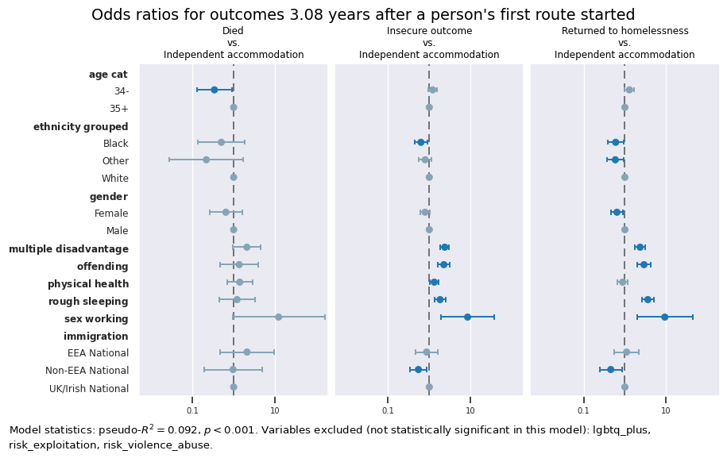

```python
figure_minor_i += 1
ref_cats_used = {k: v for k, v in ref_cats.items() if k in ["gender", "age_cat", "ethnicity_grouped", "uk_immigration_status"]}
shorter_iv = {r"uk\ immigration\ status": "immigration"}
cols_removed = [col for col in cols_to_remove_MD if col != "substance_use" and col != "mental_health"]
fig_str = plot_odds_r(dv_str, dv.cat.categories[0], ref_cats_used, results_or_final, replacements=shorter_iv, cols_removed=cols_removed)
plt.show(block=False)
```

### Separate needs (Non-MD) iterations

```python
# Reset prev_results
results, summary, results_or = multinomial_regression(selected_dv, selected_xc[sel_block_ch_d], [], dummy_cols)
```

#### MNLogit iteration 4: separate needs

**Results**

```python
results, summary, results_or = multinomial_regression(selected_dv, selected_xc[sel_block_ch_d], cols_to_remove_nonMD, dummy_cols)
```

```
Optimization terminated successfully.
         Current function value: 1.001308
         Iterations 9
```

MNLogit Regression Results

| Dep. Variable: | cli_outcome | No. Observations: | 1942 |
| --- | --- | --- | --- |
| Model: | MNLogit | Df Residuals: | 1897 |
| Method: | MLE | Df Model: | 42 |
| Date: | Sun, 21 Jun 2026 | Pseudo R-squ.: | 0.1144 |
| Time: | 14:49:42 | Log-Likelihood: | -1944.5 |
| converged: | True | LL-Null: | -2195.8 |
| Covariance Type: | nonrobust | LLR p-value: | 3.524e-80 |

| cli_outcome=Insecure outcome | coef | std err | z | P>\|z\| | [0.025 | 0.975] |
| --- | --- | --- | --- | --- | --- | --- |
| (Intercept) | -1.2668 | 0.147 | -8.608 | 0.000 | -1.555 | -0.978 |
| gender_Female | -0.0779 | 0.141 | -0.554 | 0.580 | -0.354 | 0.198 |
| age_cat_34- | 0.3393 | 0.123 | 2.770 | 0.006 | 0.099 | 0.579 |
| ethnicity_grouped_Black | -0.2823 | 0.192 | -1.470 | 0.142 | -0.659 | 0.094 |
| ethnicity_grouped_Other | -0.0892 | 0.189 | -0.473 | 0.636 | -0.459 | 0.281 |
| uk_immigration_status_Non-EEA National | -0.5342 | 0.238 | -2.247 | 0.025 | -1.000 | -0.068 |
| uk_immigration_status_EEA National | -0.1551 | 0.323 | -0.480 | 0.632 | -0.789 | 0.479 |
| offending | 1.1276 | 0.169 | 6.665 | 0.000 | 0.796 | 1.459 |
| physical_health | 0.2809 | 0.121 | 2.314 | 0.021 | 0.043 | 0.519 |
| mental_health | -0.0281 | 0.127 | -0.222 | 0.824 | -0.277 | 0.220 |
| substance_use | 1.2825 | 0.124 | 10.378 | 0.000 | 1.040 | 1.525 |
| rough_sleeping | 0.5181 | 0.160 | 3.247 | 0.001 | 0.205 | 0.831 |
| sex_working | 2.0055 | 0.779 | 2.574 | 0.010 | 0.479 | 3.533 |
| risk_violence_abuse | 0.0544 | 0.176 | 0.308 | 0.758 | -0.291 | 0.400 |
| risk_exploitation | 0.1697 | 0.218 | 0.779 | 0.436 | -0.257 | 0.596 |
| cli_outcome=Returned to homelessness | coef | std err | z | P>\|z\| | [0.025 | 0.975] |
| (Intercept) | -1.7249 | 0.172 | -10.023 | 0.000 | -2.062 | -1.388 |
| gender_Female | -0.3196 | 0.174 | -1.839 | 0.066 | -0.660 | 0.021 |
| age_cat_34- | 0.4123 | 0.141 | 2.928 | 0.003 | 0.136 | 0.688 |
| ethnicity_grouped_Black | -0.3153 | 0.232 | -1.357 | 0.175 | -0.771 | 0.140 |
| ethnicity_grouped_Other | -0.3768 | 0.239 | -1.580 | 0.114 | -0.844 | 0.091 |
| uk_immigration_status_Non-EEA National | -0.7255 | 0.320 | -2.268 | 0.023 | -1.353 | -0.098 |
| uk_immigration_status_EEA National | 0.0540 | 0.358 | 0.151 | 0.880 | -0.648 | 0.756 |
| offending | 1.3678 | 0.181 | 7.542 | 0.000 | 1.012 | 1.723 |
| physical_health | -0.1370 | 0.145 | -0.946 | 0.344 | -0.421 | 0.147 |
| mental_health | -0.1907 | 0.148 | -1.292 | 0.196 | -0.480 | 0.099 |
| substance_use | 1.3615 | 0.148 | 9.189 | 0.000 | 1.071 | 1.652 |
| rough_sleeping | 1.2023 | 0.165 | 7.273 | 0.000 | 0.878 | 1.526 |
| sex_working | 2.0315 | 0.817 | 2.488 | 0.013 | 0.431 | 3.632 |
| risk_violence_abuse | 0.3142 | 0.201 | 1.560 | 0.119 | -0.081 | 0.709 |
| risk_exploitation | 0.0381 | 0.256 | 0.149 | 0.881 | -0.463 | 0.539 |
| cli_outcome=Died | coef | std err | z | P>\|z\| | [0.025 | 0.975] |
| (Intercept) | -3.4783 | 0.464 | -7.492 | 0.000 | -4.388 | -2.568 |
| gender_Female | -0.0767 | 0.481 | -0.160 | 0.873 | -1.019 | 0.865 |
| age_cat_34- | -0.8857 | 0.507 | -1.748 | 0.080 | -1.879 | 0.107 |
| ethnicity_grouped_Black | -0.5059 | 0.678 | -0.746 | 0.456 | -1.835 | 0.824 |
| ethnicity_grouped_Other | -1.3510 | 1.046 | -1.291 | 0.197 | -3.402 | 0.700 |
| uk_immigration_status_Non-EEA National | -0.0072 | 0.821 | -0.009 | 0.993 | -1.615 | 1.601 |
| uk_immigration_status_EEA National | 0.6732 | 0.777 | 0.867 | 0.386 | -0.849 | 2.196 |
| offending | 0.6029 | 0.517 | 1.167 | 0.243 | -0.410 | 1.616 |
| physical_health | 0.3994 | 0.368 | 1.085 | 0.278 | -0.322 | 1.121 |
| mental_health | -0.3893 | 0.383 | -1.016 | 0.310 | -1.140 | 0.362 |
| substance_use | 1.3584 | 0.410 | 3.311 | 0.001 | 0.554 | 2.162 |
| rough_sleeping | 0.1118 | 0.512 | 0.218 | 0.827 | -0.891 | 1.115 |
| sex_working | 2.8393 | 1.353 | 2.099 | 0.036 | 0.188 | 5.491 |
| risk_violence_abuse | -0.9328 | 0.798 | -1.169 | 0.243 | -2.497 | 0.632 |
| risk_exploitation | -0.2552 | 0.778 | -0.328 | 0.743 | -1.781 | 1.270 |

Variables removed: ['lgbtq_plus', 'multiple_disadvantage']

|  |  | p | * | odds_r | [0.025 | 0.975] | prev_coef | coef | diff_pct |
| --- | --- | --- | --- | --- | --- | --- | --- | --- | --- |
| risk_exploitation | Died | 0.743 |  | 0.775 | 0.169 | 3.562 | -0.104 | -0.255 | 146.200 |
|  | Returned to homelessness | 0.881 |  | 1.039 | 0.629 | 1.715 | 0.137 | 0.038 | -72.100 |
|  | Insecure outcome | 0.436 |  | 1.185 | 0.773 | 1.816 | 0.267 | 0.170 | -36.500 |
| uk_immigration_status_EEA National | Insecure outcome | 0.632 |  | 0.856 | 0.454 | 1.614 | -0.062 | -0.155 | 149.700 |
|  | Returned to homelessness | 0.880 |  | 1.055 | 0.523 | 2.129 | 0.260 | 0.054 | -79.200 |
|  | Died | 0.386 |  | 1.961 | 0.428 | 8.986 | 0.455 | 0.673 | 48.000 |
| mental_health | Returned to homelessness | 0.196 |  | 0.826 | 0.619 | 1.104 | -0.208 | -0.191 | -8.100 |
|  | Insecure outcome | 0.824 |  | 0.972 | 0.758 | 1.247 | -0.013 | -0.028 | 114.000 |
|  | Died | 0.310 |  | 0.677 | 0.320 | 1.436 | -1.289 | -0.389 | -69.800 |
| ethnicity_grouped_Black | Insecure outcome | 0.142 |  | 0.754 | 0.518 | 1.099 | -0.242 | -0.282 | 16.500 |
|  | Died | 0.456 |  | 0.603 | 0.160 | 2.279 | -0.494 | -0.506 | 2.400 |
|  | Returned to homelessness | 0.175 |  | 0.730 | 0.463 | 1.150 | -0.302 | -0.315 | 4.300 |
| risk_violence_abuse | Returned to homelessness | 0.119 |  | 1.369 | 0.923 | 2.032 | 0.404 | 0.314 | -22.300 |
|  | Died | 0.243 |  | 0.393 | 0.082 | 1.881 | -1.128 | -0.933 | -17.300 |
|  | Insecure outcome | 0.758 |  | 1.056 | 0.747 | 1.492 | 0.024 | 0.054 | 123.800 |
| ethnicity_grouped_Other | Insecure outcome | 0.636 |  | 0.915 | 0.632 | 1.324 | -0.054 | -0.089 | 64.100 |
|  | Died | 0.197 |  | 0.259 | 0.033 | 2.014 | -0.964 | -1.351 | 40.100 |
|  | Returned to homelessness | 0.114 |  | 0.686 | 0.430 | 1.095 | -0.271 | -0.377 | 38.900 |
| gender_Female | Returned to homelessness | 0.066 |  | 0.726 | 0.517 | 1.021 | -0.339 | -0.320 | -5.800 |
|  | Insecure outcome | 0.580 |  | 0.925 | 0.702 | 1.219 | 0.017 | -0.078 | -556.800 |
|  | Died | 0.873 |  | 0.926 | 0.361 | 2.375 | 0.084 | -0.077 | -191.500 |
| uk_immigration_status_Non-EEA National | Insecure outcome | 0.025 | * | 0.586 | 0.368 | 0.934 | -0.518 | -0.534 | 3.100 |
|  | Died | 0.993 |  | 0.993 | 0.199 | 4.958 | 0.556 | -0.007 | -101.300 |
|  | Returned to homelessness | 0.023 | * | 0.484 | 0.259 | 0.906 | -0.899 | -0.726 | -19.300 |
| physical_health | Insecure outcome | 0.021 | * | 1.324 | 1.044 | 1.680 | 0.344 | 0.281 | -18.400 |
|  | Returned to homelessness | 0.344 |  | 0.872 | 0.657 | 1.158 | -0.249 | -0.137 | -45.100 |
|  | Died | 0.278 |  | 1.491 | 0.725 | 3.068 | 0.290 | 0.399 | 37.700 |
| sex_working | Insecure outcome | 0.010 | * | 7.430 | 1.614 | 34.210 | 1.598 | 2.006 | 25.500 |
|  | Returned to homelessness | 0.013 | * | 7.625 | 1.539 | 37.787 | 1.787 | 2.031 | 13.700 |
|  | Died | 0.036 | * | 17.104 | 1.207 | 242.475 | 2.725 | 2.839 | 4.200 |
| age_cat_34- | Insecure outcome | 0.006 | * | 1.404 | 1.104 | 1.785 | 0.336 | 0.339 | 1.000 |
|  | Died | 0.080 |  | 0.412 | 0.153 | 1.113 | -0.461 | -0.886 | 92.300 |
|  | Returned to homelessness | 0.003 | * | 1.510 | 1.146 | 1.990 | 0.295 | 0.412 | 39.600 |
| rough_sleeping | Returned to homelessness | 0.000 | * | 3.328 | 2.407 | 4.601 | 1.239 | 1.202 | -3.000 |
|  | Died | 0.827 |  | 1.118 | 0.410 | 3.049 | -0.170 | 0.112 | -165.900 |
|  | Insecure outcome | 0.001 | * | 1.679 | 1.228 | 2.295 | 0.597 | 0.518 | -13.300 |
| offending | Died | 0.243 |  | 1.827 | 0.664 | 5.031 | 0.005 | 0.603 | 10,995.500 |
|  | Returned to homelessness | 0.000 | * | 3.927 | 2.752 | 5.603 | 1.503 | 1.368 | -9.000 |
|  | Insecure outcome | 0.000 | * | 3.088 | 2.217 | 4.303 | 1.291 | 1.128 | -12.600 |
| (Intercept) | Died | 0.000 | * | 0.031 | 0.012 | 0.077 | -4.027 | -3.478 | -13.600 |
|  | Returned to homelessness | 0.000 | * | 0.178 | 0.127 | 0.250 | -1.659 | -1.725 | 4.000 |
|  | Insecure outcome | 0.000 | * | 0.282 | 0.211 | 0.376 | -1.265 | -1.267 | 0.200 |
| substance_use | Returned to homelessness | 0.000 | * | 3.902 | 2.919 | 5.217 | 1.331 | 1.362 | 2.300 |
|  | Died | 0.001 | * | 3.890 | 1.741 | 8.693 | 1.631 | 1.358 | -16.700 |
|  | Insecure outcome | 0.000 | * | 3.606 | 2.830 | 4.594 | 1.229 | 1.283 | 4.400 |

```
Psuedo R^2: 0.11441178482008263
--------------------------------------------------
```

Major increase in pseudo $R^2$, so model with support needs explains much more of the variance. Separate support needs explain more variance than MD.

`ethnicity_grouped` no longer significant as variance better explained by other variables

#### MNLogit iteration 5: separate needs

**Results**

```python
cols_to_remove_nonMD += ["ethnicity_grouped"]
results, summary, results_or = multinomial_regression(selected_dv, selected_xc[sel_block_ch_d], cols_to_remove_nonMD, dummy_cols)
```

```
Optimization terminated successfully.
         Current function value: 1.001040
         Iterations 9
```

MNLogit Regression Results

| Dep. Variable: | cli_outcome | No. Observations: | 2014 |
| --- | --- | --- | --- |
| Model: | MNLogit | Df Residuals: | 1975 |
| Method: | MLE | Df Model: | 36 |
| Date: | Sun, 21 Jun 2026 | Pseudo R-squ.: | 0.1148 |
| Time: | 14:49:43 | Log-Likelihood: | -2016.1 |
| converged: | True | LL-Null: | -2277.5 |
| Covariance Type: | nonrobust | LLR p-value: | 1.119e-87 |

| cli_outcome=Insecure outcome | coef | std err | z | P>\|z\| | [0.025 | 0.975] |
| --- | --- | --- | --- | --- | --- | --- |
| (Intercept) | -1.3636 | 0.139 | -9.815 | 0.000 | -1.636 | -1.091 |
| gender_Female | -0.0530 | 0.138 | -0.385 | 0.700 | -0.323 | 0.217 |
| age_cat_34- | 0.3325 | 0.120 | 2.766 | 0.006 | 0.097 | 0.568 |
| uk_immigration_status_Non-EEA National | -0.6850 | 0.213 | -3.210 | 0.001 | -1.103 | -0.267 |
| uk_immigration_status_EEA National | -0.1184 | 0.315 | -0.375 | 0.707 | -0.737 | 0.500 |
| offending | 1.0975 | 0.166 | 6.606 | 0.000 | 0.772 | 1.423 |
| physical_health | 0.2844 | 0.119 | 2.389 | 0.017 | 0.051 | 0.518 |
| mental_health | 0.0233 | 0.125 | 0.187 | 0.852 | -0.221 | 0.268 |
| substance_use | 1.3077 | 0.120 | 10.936 | 0.000 | 1.073 | 1.542 |
| rough_sleeping | 0.5578 | 0.156 | 3.566 | 0.000 | 0.251 | 0.864 |
| sex_working | 2.0346 | 0.782 | 2.603 | 0.009 | 0.503 | 3.566 |
| risk_violence_abuse | 0.0674 | 0.172 | 0.391 | 0.696 | -0.271 | 0.405 |
| risk_exploitation | 0.1555 | 0.213 | 0.730 | 0.466 | -0.262 | 0.573 |
| cli_outcome=Returned to homelessness | coef | std err | z | P>\|z\| | [0.025 | 0.975] |
| (Intercept) | -1.8549 | 0.163 | -11.358 | 0.000 | -2.175 | -1.535 |
| gender_Female | -0.3253 | 0.171 | -1.899 | 0.058 | -0.661 | 0.010 |
| age_cat_34- | 0.3976 | 0.138 | 2.874 | 0.004 | 0.126 | 0.669 |
| uk_immigration_status_Non-EEA National | -0.9154 | 0.288 | -3.177 | 0.001 | -1.480 | -0.351 |
| uk_immigration_status_EEA National | 0.0894 | 0.348 | 0.257 | 0.797 | -0.593 | 0.771 |
| offending | 1.3518 | 0.178 | 7.615 | 0.000 | 1.004 | 1.700 |
| physical_health | -0.1650 | 0.143 | -1.158 | 0.247 | -0.444 | 0.114 |
| mental_health | -0.1319 | 0.145 | -0.908 | 0.364 | -0.417 | 0.153 |
| substance_use | 1.4322 | 0.144 | 9.977 | 0.000 | 1.151 | 1.714 |
| rough_sleeping | 1.2292 | 0.162 | 7.574 | 0.000 | 0.911 | 1.547 |
| sex_working | 2.1257 | 0.820 | 2.591 | 0.010 | 0.518 | 3.734 |
| risk_violence_abuse | 0.2661 | 0.199 | 1.335 | 0.182 | -0.125 | 0.657 |
| risk_exploitation | 0.0438 | 0.251 | 0.175 | 0.861 | -0.448 | 0.535 |
| cli_outcome=Died | coef | std err | z | P>\|z\| | [0.025 | 0.975] |
| (Intercept) | -3.7277 | 0.443 | -8.416 | 0.000 | -4.596 | -2.859 |
| gender_Female | 0.2287 | 0.432 | 0.530 | 0.596 | -0.617 | 1.075 |
| age_cat_34- | -0.9908 | 0.503 | -1.970 | 0.049 | -1.977 | -0.005 |
| uk_immigration_status_Non-EEA National | -0.5261 | 0.755 | -0.697 | 0.486 | -2.006 | 0.953 |
| uk_immigration_status_EEA National | 0.6227 | 0.770 | 0.809 | 0.419 | -0.887 | 2.132 |
| offending | 0.5341 | 0.513 | 1.041 | 0.298 | -0.472 | 1.540 |
| physical_health | 0.5389 | 0.356 | 1.513 | 0.130 | -0.159 | 1.237 |
| mental_health | -0.2930 | 0.374 | -0.783 | 0.434 | -1.026 | 0.440 |
| substance_use | 1.3978 | 0.390 | 3.582 | 0.000 | 0.633 | 2.163 |
| rough_sleeping | 0.0712 | 0.508 | 0.140 | 0.889 | -0.924 | 1.067 |
| sex_working | 2.7699 | 1.338 | 2.070 | 0.038 | 0.147 | 5.392 |
| risk_violence_abuse | -1.1011 | 0.785 | -1.402 | 0.161 | -2.640 | 0.438 |
| risk_exploitation | -0.3298 | 0.772 | -0.427 | 0.669 | -1.843 | 1.183 |

Variables removed: ['lgbtq_plus', 'multiple_disadvantage', 'ethnicity_grouped']

|  |  | p | * | odds_r | [0.025 | 0.975] | prev_coef | coef | diff_pct |
| --- | --- | --- | --- | --- | --- | --- | --- | --- | --- |
| risk_exploitation | Died | 0.669 |  | 0.719 | 0.158 | 3.264 | -0.255 | -0.330 | 29.300 |
|  | Returned to homelessness | 0.861 |  | 1.045 | 0.639 | 1.708 | 0.038 | 0.044 | 14.800 |
|  | Insecure outcome | 0.466 |  | 1.168 | 0.769 | 1.774 | 0.170 | 0.155 | -8.400 |
| uk_immigration_status_EEA National | Returned to homelessness | 0.797 |  | 1.093 | 0.553 | 2.163 | 0.054 | 0.089 | 65.600 |
|  | Insecure outcome | 0.707 |  | 0.888 | 0.479 | 1.649 | -0.155 | -0.118 | -23.700 |
|  | Died | 0.419 |  | 1.864 | 0.412 | 8.432 | 0.673 | 0.623 | -7.500 |
| mental_health | Died | 0.434 |  | 0.746 | 0.358 | 1.553 | -0.389 | -0.293 | -24.700 |
|  | Insecure outcome | 0.852 |  | 1.024 | 0.802 | 1.307 | -0.028 | 0.023 | -182.900 |
|  | Returned to homelessness | 0.364 |  | 0.876 | 0.659 | 1.165 | -0.191 | -0.132 | -30.900 |
| risk_violence_abuse | Died | 0.161 |  | 0.333 | 0.071 | 1.549 | -0.933 | -1.101 | 18.000 |
|  | Returned to homelessness | 0.182 |  | 1.305 | 0.883 | 1.928 | 0.314 | 0.266 | -15.300 |
|  | Insecure outcome | 0.696 |  | 1.070 | 0.763 | 1.500 | 0.054 | 0.067 | 23.900 |
| gender_Female | Died | 0.596 |  | 1.257 | 0.539 | 2.929 | -0.077 | 0.229 | -397.900 |
|  | Returned to homelessness | 0.058 |  | 0.722 | 0.516 | 1.010 | -0.320 | -0.325 | 1.800 |
|  | Insecure outcome | 0.700 |  | 0.948 | 0.724 | 1.242 | -0.078 | -0.053 | -32.000 |
| physical_health | Died | 0.130 |  | 1.714 | 0.853 | 3.445 | 0.399 | 0.539 | 34.900 |
|  | Returned to homelessness | 0.247 |  | 0.848 | 0.641 | 1.121 | -0.137 | -0.165 | 20.500 |
|  | Insecure outcome | 0.017 | * | 1.329 | 1.052 | 1.678 | 0.281 | 0.284 | 1.200 |
| sex_working | Died | 0.038 | * | 15.957 | 1.159 | 219.714 | 2.839 | 2.770 | -2.400 |
|  | Returned to homelessness | 0.010 | * | 8.379 | 1.678 | 41.831 | 2.031 | 2.126 | 4.600 |
|  | Insecure outcome | 0.009 | * | 7.649 | 1.653 | 35.391 | 2.006 | 2.035 | 1.500 |
| age_cat_34- | Died | 0.049 | * | 0.371 | 0.139 | 0.995 | -0.886 | -0.991 | 11.900 |
|  | Returned to homelessness | 0.004 | * | 1.488 | 1.135 | 1.952 | 0.412 | 0.398 | -3.600 |
|  | Insecure outcome | 0.006 | * | 1.394 | 1.102 | 1.765 | 0.339 | 0.333 | -2.000 |
| uk_immigration_status_Non-EEA National | Died | 0.486 |  | 0.591 | 0.135 | 2.595 | -0.007 | -0.526 | 7,235.400 |
|  | Insecure outcome | 0.001 | * | 0.504 | 0.332 | 0.766 | -0.534 | -0.685 | 28.200 |
|  | Returned to homelessness | 0.001 | * | 0.400 | 0.228 | 0.704 | -0.726 | -0.915 | 26.200 |
| rough_sleeping | Insecure outcome | 0.000 | * | 1.747 | 1.286 | 2.374 | 0.518 | 0.558 | 7.700 |
|  | Returned to homelessness | 0.000 | * | 3.419 | 2.487 | 4.699 | 1.202 | 1.229 | 2.200 |
|  | Died | 0.889 |  | 1.074 | 0.397 | 2.906 | 0.112 | 0.071 | -36.300 |
| offending | Returned to homelessness | 0.000 | * | 3.864 | 2.729 | 5.472 | 1.368 | 1.352 | -1.200 |
|  | Died | 0.298 |  | 1.706 | 0.624 | 4.664 | 0.603 | 0.534 | -11.400 |
|  | Insecure outcome | 0.000 | * | 2.997 | 2.164 | 4.150 | 1.128 | 1.098 | -2.700 |
| substance_use | Insecure outcome | 0.000 | * | 3.698 | 2.925 | 4.674 | 1.283 | 1.308 | 2.000 |
|  | Died | 0.000 | * | 4.046 | 1.883 | 8.694 | 1.358 | 1.398 | 2.900 |
|  | Returned to homelessness | 0.000 | * | 4.188 | 3.161 | 5.548 | 1.362 | 1.432 | 5.200 |
| (Intercept) | Died | 0.000 | * | 0.024 | 0.010 | 0.057 | -3.478 | -3.728 | 7.200 |
|  | Returned to homelessness | 0.000 | * | 0.156 | 0.114 | 0.216 | -1.725 | -1.855 | 7.500 |
|  | Insecure outcome | 0.000 | * | 0.256 | 0.195 | 0.336 | -1.267 | -1.364 | 7.600 |

```
Psuedo R^2: 0.11477424544718995
--------------------------------------------------
```

`risk_exploitation` no longer significant as variance better explained by other variables

#### MNLogit iteration 6: separate needs

**Results**

```python
cols_to_remove_nonMD += ["risk_exploitation"]
results, summary, results_or = multinomial_regression(selected_dv, selected_xc[sel_block_ch_d], cols_to_remove_nonMD, dummy_cols)
```

```
Optimization terminated successfully.
         Current function value: 1.001268
         Iterations 9
```

MNLogit Regression Results

| Dep. Variable: | cli_outcome | No. Observations: | 2014 |
| --- | --- | --- | --- |
| Model: | MNLogit | Df Residuals: | 1978 |
| Method: | MLE | Df Model: | 33 |
| Date: | Sun, 21 Jun 2026 | Pseudo R-squ.: | 0.1146 |
| Time: | 14:49:43 | Log-Likelihood: | -2016.6 |
| converged: | True | LL-Null: | -2277.5 |
| Covariance Type: | nonrobust | LLR p-value: | 2.776e-89 |

| cli_outcome=Insecure outcome | coef | std err | z | P>\|z\| | [0.025 | 0.975] |
| --- | --- | --- | --- | --- | --- | --- |
| (Intercept) | -1.3624 | 0.139 | -9.809 | 0.000 | -1.635 | -1.090 |
| gender_Female | -0.0493 | 0.138 | -0.359 | 0.720 | -0.319 | 0.220 |
| age_cat_34- | 0.3326 | 0.120 | 2.767 | 0.006 | 0.097 | 0.568 |
| uk_immigration_status_Non-EEA National | -0.6908 | 0.213 | -3.237 | 0.001 | -1.109 | -0.273 |
| uk_immigration_status_EEA National | -0.1180 | 0.315 | -0.374 | 0.708 | -0.736 | 0.500 |
| offending | 1.0931 | 0.166 | 6.585 | 0.000 | 0.768 | 1.418 |
| physical_health | 0.2872 | 0.119 | 2.414 | 0.016 | 0.054 | 0.520 |
| mental_health | 0.0270 | 0.125 | 0.217 | 0.828 | -0.217 | 0.271 |
| substance_use | 1.3167 | 0.119 | 11.068 | 0.000 | 1.084 | 1.550 |
| rough_sleeping | 0.5546 | 0.156 | 3.547 | 0.000 | 0.248 | 0.861 |
| sex_working | 2.0610 | 0.781 | 2.640 | 0.008 | 0.531 | 3.591 |
| risk_violence_abuse | 0.0931 | 0.169 | 0.551 | 0.581 | -0.238 | 0.424 |
| cli_outcome=Returned to homelessness | coef | std err | z | P>\|z\| | [0.025 | 0.975] |
| (Intercept) | -1.8549 | 0.163 | -11.358 | 0.000 | -2.175 | -1.535 |
| gender_Female | -0.3240 | 0.171 | -1.893 | 0.058 | -0.660 | 0.012 |
| age_cat_34- | 0.3984 | 0.138 | 2.879 | 0.004 | 0.127 | 0.670 |
| uk_immigration_status_Non-EEA National | -0.9161 | 0.288 | -3.181 | 0.001 | -1.481 | -0.352 |
| uk_immigration_status_EEA National | 0.0891 | 0.348 | 0.256 | 0.798 | -0.593 | 0.771 |
| offending | 1.3501 | 0.177 | 7.610 | 0.000 | 1.002 | 1.698 |
| physical_health | -0.1642 | 0.142 | -1.153 | 0.249 | -0.443 | 0.115 |
| mental_health | -0.1309 | 0.145 | -0.902 | 0.367 | -0.415 | 0.154 |
| substance_use | 1.4349 | 0.143 | 10.042 | 0.000 | 1.155 | 1.715 |
| rough_sleeping | 1.2279 | 0.162 | 7.569 | 0.000 | 0.910 | 1.546 |
| sex_working | 2.1295 | 0.819 | 2.601 | 0.009 | 0.525 | 3.734 |
| risk_violence_abuse | 0.2723 | 0.195 | 1.394 | 0.163 | -0.111 | 0.655 |
| cli_outcome=Died | coef | std err | z | P>\|z\| | [0.025 | 0.975] |
| (Intercept) | -3.7335 | 0.443 | -8.423 | 0.000 | -4.602 | -2.865 |
| gender_Female | 0.2279 | 0.432 | 0.528 | 0.598 | -0.618 | 1.074 |
| age_cat_34- | -0.9885 | 0.503 | -1.965 | 0.049 | -1.974 | -0.003 |
| uk_immigration_status_Non-EEA National | -0.5071 | 0.754 | -0.673 | 0.501 | -1.985 | 0.971 |
| uk_immigration_status_EEA National | 0.6323 | 0.770 | 0.821 | 0.412 | -0.877 | 2.141 |
| offending | 0.5460 | 0.513 | 1.065 | 0.287 | -0.459 | 1.551 |
| physical_health | 0.5369 | 0.356 | 1.509 | 0.131 | -0.161 | 1.234 |
| mental_health | -0.2970 | 0.374 | -0.794 | 0.427 | -1.030 | 0.436 |
| substance_use | 1.3820 | 0.389 | 3.552 | 0.000 | 0.620 | 2.145 |
| rough_sleeping | 0.0690 | 0.509 | 0.136 | 0.892 | -0.928 | 1.066 |
| sex_working | 2.7213 | 1.332 | 2.043 | 0.041 | 0.110 | 5.332 |
| risk_violence_abuse | -1.1610 | 0.776 | -1.497 | 0.134 | -2.681 | 0.359 |

Variables removed: ['lgbtq_plus', 'multiple_disadvantage', 'ethnicity_grouped', 'risk_exploitation']

|  |  | p | * | odds_r | [0.025 | 0.975] | prev_coef | coef | diff_pct |
| --- | --- | --- | --- | --- | --- | --- | --- | --- | --- |
| uk_immigration_status_EEA National | Insecure outcome | 0.708 |  | 0.889 | 0.479 | 1.649 | -0.118 | -0.118 | -0.300 |
|  | Died | 0.412 |  | 1.882 | 0.416 | 8.512 | 0.623 | 0.632 | 1.600 |
|  | Returned to homelessness | 0.798 |  | 1.093 | 0.553 | 2.162 | 0.089 | 0.089 | -0.300 |
| mental_health | Died | 0.427 |  | 0.743 | 0.357 | 1.547 | -0.293 | -0.297 | 1.400 |
|  | Insecure outcome | 0.828 |  | 1.027 | 0.805 | 1.311 | 0.023 | 0.027 | 15.900 |
|  | Returned to homelessness | 0.367 |  | 0.877 | 0.660 | 1.166 | -0.132 | -0.131 | -0.800 |
| risk_violence_abuse | Died | 0.134 |  | 0.313 | 0.068 | 1.432 | -1.101 | -1.161 | 5.400 |
|  | Returned to homelessness | 0.163 |  | 1.313 | 0.895 | 1.925 | 0.266 | 0.272 | 2.300 |
|  | Insecure outcome | 0.581 |  | 1.098 | 0.788 | 1.528 | 0.067 | 0.093 | 38.000 |
| gender_Female | Returned to homelessness | 0.058 |  | 0.723 | 0.517 | 1.012 | -0.325 | -0.324 | -0.400 |
|  | Died | 0.598 |  | 1.256 | 0.539 | 2.927 | 0.229 | 0.228 | -0.400 |
|  | Insecure outcome | 0.720 |  | 0.952 | 0.727 | 1.246 | -0.053 | -0.049 | -6.900 |
| physical_health | Died | 0.131 |  | 1.711 | 0.852 | 3.436 | 0.539 | 0.537 | -0.400 |
|  | Returned to homelessness | 0.249 |  | 0.849 | 0.642 | 1.122 | -0.165 | -0.164 | -0.500 |
|  | Insecure outcome | 0.016 | * | 1.333 | 1.055 | 1.683 | 0.284 | 0.287 | 1.000 |
| sex_working | Returned to homelessness | 0.009 | * | 8.410 | 1.690 | 41.846 | 2.126 | 2.129 | 0.200 |
|  | Died | 0.041 | * | 15.201 | 1.117 | 206.934 | 2.770 | 2.721 | -1.800 |
|  | Insecure outcome | 0.008 | * | 7.854 | 1.701 | 36.269 | 2.035 | 2.061 | 1.300 |
| age_cat_34- | Insecure outcome | 0.006 | * | 1.395 | 1.102 | 1.765 | 0.333 | 0.333 | 0.000 |
|  | Died | 0.049 | * | 0.372 | 0.139 | 0.997 | -0.991 | -0.988 | -0.200 |
|  | Returned to homelessness | 0.004 | * | 1.489 | 1.136 | 1.953 | 0.398 | 0.398 | 0.200 |
| uk_immigration_status_Non-EEA National | Returned to homelessness | 0.001 | * | 0.400 | 0.228 | 0.704 | -0.915 | -0.916 | 0.100 |
|  | Died | 0.501 |  | 0.602 | 0.137 | 2.640 | -0.526 | -0.507 | -3.600 |
|  | Insecure outcome | 0.001 | * | 0.501 | 0.330 | 0.761 | -0.685 | -0.691 | 0.800 |
| rough_sleeping | Returned to homelessness | 0.000 | * | 3.414 | 2.484 | 4.692 | 1.229 | 1.228 | -0.100 |
|  | Insecure outcome | 0.000 | * | 1.741 | 1.282 | 2.366 | 0.558 | 0.555 | -0.600 |
|  | Died | 0.892 |  | 1.071 | 0.395 | 2.903 | 0.071 | 0.069 | -3.000 |
| offending | Insecure outcome | 0.000 | * | 2.984 | 2.155 | 4.131 | 1.098 | 1.093 | -0.400 |
|  | Died | 0.287 |  | 1.726 | 0.632 | 4.716 | 0.534 | 0.546 | 2.200 |
|  | Returned to homelessness | 0.000 | * | 3.858 | 2.725 | 5.462 | 1.352 | 1.350 | -0.100 |
| substance_use | Returned to homelessness | 0.000 | * | 4.199 | 3.174 | 5.557 | 1.432 | 1.435 | 0.200 |
|  | Insecure outcome | 0.000 | * | 3.731 | 2.955 | 4.711 | 1.308 | 1.317 | 0.700 |
|  | Died | 0.000 | * | 3.983 | 1.858 | 8.538 | 1.398 | 1.382 | -1.100 |
| (Intercept) | Died | 0.000 | * | 0.024 | 0.010 | 0.057 | -3.728 | -3.733 | 0.200 |
|  | Returned to homelessness | 0.000 | * | 0.156 | 0.114 | 0.216 | -1.855 | -1.855 | -0.000 |
|  | Insecure outcome | 0.000 | * | 0.256 | 0.195 | 0.336 | -1.364 | -1.362 | -0.100 |

```
Psuedo R^2: 0.1145728529782255
--------------------------------------------------
```

`mental_health` no longer significant as variance better explained by other variables

#### MNLogit iteration 7: separate needs

**Results**

```python
cols_to_remove_nonMD += ["mental_health"]
results, summary, results_or = multinomial_regression(selected_dv, selected_xc[sel_block_ch_d], cols_to_remove_nonMD, dummy_cols)
```

```
Optimization terminated successfully.
         Current function value: 1.001720
         Iterations 9
```

MNLogit Regression Results

| Dep. Variable: | cli_outcome | No. Observations: | 2014 |
| --- | --- | --- | --- |
| Model: | MNLogit | Df Residuals: | 1981 |
| Method: | MLE | Df Model: | 30 |
| Date: | Sun, 21 Jun 2026 | Pseudo R-squ.: | 0.1142 |
| Time: | 14:49:44 | Log-Likelihood: | -2017.5 |
| converged: | True | LL-Null: | -2277.5 |
| Covariance Type: | nonrobust | LLR p-value: | 9.232e-91 |

| cli_outcome=Insecure outcome | coef | std err | z | P>\|z\| | [0.025 | 0.975] |
| --- | --- | --- | --- | --- | --- | --- |
| (Intercept) | -1.3478 | 0.124 | -10.905 | 0.000 | -1.590 | -1.106 |
| gender_Female | -0.0477 | 0.137 | -0.349 | 0.727 | -0.316 | 0.220 |
| age_cat_34- | 0.3345 | 0.120 | 2.797 | 0.005 | 0.100 | 0.569 |
| uk_immigration_status_Non-EEA National | -0.6914 | 0.213 | -3.244 | 0.001 | -1.109 | -0.274 |
| uk_immigration_status_EEA National | -0.1250 | 0.315 | -0.397 | 0.691 | -0.742 | 0.492 |
| offending | 1.0933 | 0.166 | 6.590 | 0.000 | 0.768 | 1.419 |
| physical_health | 0.2883 | 0.119 | 2.430 | 0.015 | 0.056 | 0.521 |
| substance_use | 1.3207 | 0.117 | 11.259 | 0.000 | 1.091 | 1.551 |
| rough_sleeping | 0.5574 | 0.156 | 3.568 | 0.000 | 0.251 | 0.864 |
| sex_working | 2.0609 | 0.780 | 2.641 | 0.008 | 0.531 | 3.590 |
| risk_violence_abuse | 0.0948 | 0.169 | 0.562 | 0.574 | -0.236 | 0.426 |
| cli_outcome=Returned to homelessness | coef | std err | z | P>\|z\| | [0.025 | 0.975] |
| (Intercept) | -1.9179 | 0.148 | -12.921 | 0.000 | -2.209 | -1.627 |
| gender_Female | -0.3377 | 0.170 | -1.983 | 0.047 | -0.672 | -0.004 |
| age_cat_34- | 0.3862 | 0.138 | 2.807 | 0.005 | 0.117 | 0.656 |
| uk_immigration_status_Non-EEA National | -0.9098 | 0.288 | -3.160 | 0.002 | -1.474 | -0.345 |
| uk_immigration_status_EEA National | 0.1139 | 0.346 | 0.329 | 0.742 | -0.565 | 0.793 |
| offending | 1.3453 | 0.177 | 7.591 | 0.000 | 0.998 | 1.693 |
| physical_health | -0.1732 | 0.142 | -1.219 | 0.223 | -0.452 | 0.105 |
| substance_use | 1.4108 | 0.140 | 10.061 | 0.000 | 1.136 | 1.686 |
| rough_sleeping | 1.2214 | 0.162 | 7.534 | 0.000 | 0.904 | 1.539 |
| sex_working | 2.1177 | 0.818 | 2.590 | 0.010 | 0.515 | 3.720 |
| risk_violence_abuse | 0.2694 | 0.195 | 1.379 | 0.168 | -0.113 | 0.652 |
| cli_outcome=Died | coef | std err | z | P>\|z\| | [0.025 | 0.975] |
| (Intercept) | -3.8798 | 0.409 | -9.475 | 0.000 | -4.682 | -3.077 |
| gender_Female | 0.1969 | 0.429 | 0.459 | 0.647 | -0.645 | 1.038 |
| age_cat_34- | -1.0218 | 0.501 | -2.040 | 0.041 | -2.004 | -0.040 |
| uk_immigration_status_Non-EEA National | -0.4873 | 0.753 | -0.647 | 0.518 | -1.963 | 0.989 |
| uk_immigration_status_EEA National | 0.6902 | 0.766 | 0.901 | 0.368 | -0.812 | 2.192 |
| offending | 0.5326 | 0.512 | 1.040 | 0.298 | -0.471 | 1.537 |
| physical_health | 0.5215 | 0.355 | 1.468 | 0.142 | -0.175 | 1.218 |
| substance_use | 1.3438 | 0.386 | 3.484 | 0.000 | 0.588 | 2.100 |
| rough_sleeping | 0.0456 | 0.508 | 0.090 | 0.928 | -0.950 | 1.041 |
| sex_working | 2.6659 | 1.329 | 2.006 | 0.045 | 0.061 | 5.271 |
| risk_violence_abuse | -1.1746 | 0.775 | -1.517 | 0.129 | -2.693 | 0.343 |

Variables removed: ['lgbtq_plus', 'multiple_disadvantage', 'ethnicity_grouped', 'risk_exploitation', 'mental_health']

|  |  | p | * | odds_r | [0.025 | 0.975] | prev_coef | coef | diff_pct |
| --- | --- | --- | --- | --- | --- | --- | --- | --- | --- |
| uk_immigration_status_EEA National | Died | 0.368 |  | 1.994 | 0.444 | 8.955 | 0.632 | 0.690 | 9.200 |
|  | Insecure outcome | 0.691 |  | 0.882 | 0.476 | 1.635 | -0.118 | -0.125 | 5.900 |
|  | Returned to homelessness | 0.742 |  | 1.121 | 0.568 | 2.209 | 0.089 | 0.114 | 27.900 |
| risk_violence_abuse | Died | 0.129 |  | 0.309 | 0.068 | 1.410 | -1.161 | -1.175 | 1.200 |
|  | Insecure outcome | 0.574 |  | 1.099 | 0.790 | 1.530 | 0.093 | 0.095 | 1.800 |
|  | Returned to homelessness | 0.168 |  | 1.309 | 0.893 | 1.920 | 0.272 | 0.269 | -1.100 |
| gender_Female | Died | 0.647 |  | 1.218 | 0.525 | 2.825 | 0.228 | 0.197 | -13.600 |
|  | Insecure outcome | 0.727 |  | 0.953 | 0.729 | 1.247 | -0.049 | -0.048 | -3.200 |
|  | Returned to homelessness | 0.047 | * | 0.713 | 0.511 | 0.996 | -0.324 | -0.338 | 4.200 |
| physical_health | Died | 0.142 |  | 1.685 | 0.840 | 3.380 | 0.537 | 0.522 | -2.900 |
|  | Insecure outcome | 0.015 | * | 1.334 | 1.057 | 1.683 | 0.287 | 0.288 | 0.400 |
|  | Returned to homelessness | 0.223 |  | 0.841 | 0.637 | 1.111 | -0.164 | -0.173 | 5.500 |
| sex_working | Insecure outcome | 0.008 | * | 7.853 | 1.701 | 36.248 | 2.061 | 2.061 | -0.000 |
|  | Returned to homelessness | 0.010 | * | 8.312 | 1.674 | 41.277 | 2.129 | 2.118 | -0.600 |
|  | Died | 0.045 | * | 14.381 | 1.063 | 194.631 | 2.721 | 2.666 | -2.000 |
| age_cat_34- | Returned to homelessness | 0.005 | * | 1.471 | 1.124 | 1.927 | 0.398 | 0.386 | -3.100 |
|  | Insecure outcome | 0.005 | * | 1.397 | 1.105 | 1.766 | 0.333 | 0.335 | 0.600 |
|  | Died | 0.041 | * | 0.360 | 0.135 | 0.961 | -0.988 | -1.022 | 3.400 |
| uk_immigration_status_Non-EEA National | Died | 0.518 |  | 0.614 | 0.140 | 2.688 | -0.507 | -0.487 | -3.900 |
|  | Returned to homelessness | 0.002 | * | 0.403 | 0.229 | 0.708 | -0.916 | -0.910 | -0.700 |
|  | Insecure outcome | 0.001 | * | 0.501 | 0.330 | 0.761 | -0.691 | -0.691 | 0.100 |
| rough_sleeping | Insecure outcome | 0.000 | * | 1.746 | 1.286 | 2.372 | 0.555 | 0.557 | 0.500 |
|  | Died | 0.928 |  | 1.047 | 0.387 | 2.831 | 0.069 | 0.046 | -33.900 |
|  | Returned to homelessness | 0.000 | * | 3.392 | 2.469 | 4.661 | 1.228 | 1.221 | -0.500 |
| offending | Died | 0.298 |  | 1.703 | 0.624 | 4.648 | 0.546 | 0.533 | -2.500 |
|  | Returned to homelessness | 0.000 | * | 3.839 | 2.713 | 5.434 | 1.350 | 1.345 | -0.400 |
|  | Insecure outcome | 0.000 | * | 2.984 | 2.156 | 4.131 | 1.093 | 1.093 | 0.000 |
| substance_use | Returned to homelessness | 0.000 | * | 4.099 | 3.114 | 5.396 | 1.435 | 1.411 | -1.700 |
|  | Died | 0.000 | * | 3.834 | 1.800 | 8.165 | 1.382 | 1.344 | -2.800 |
|  | Insecure outcome | 0.000 | * | 3.746 | 2.977 | 4.714 | 1.317 | 1.321 | 0.300 |
| (Intercept) | Died | 0.000 | * | 0.021 | 0.009 | 0.046 | -3.733 | -3.880 | 3.900 |
|  | Returned to homelessness | 0.000 | * | 0.147 | 0.110 | 0.197 | -1.855 | -1.918 | 3.400 |
|  | Insecure outcome | 0.000 | * | 0.260 | 0.204 | 0.331 | -1.362 | -1.348 | -1.100 |

```
Psuedo R^2: 0.11417273951987728
--------------------------------------------------
```

`risk_violence_abuse` no longer significant as variance better explained by other variables

**Results**

```python
cols_to_remove_nonMD += ["risk_violence_abuse"]
results, summary, results_or = multinomial_regression(selected_dv, selected_xc[sel_block_ch_d], cols_to_remove_nonMD, dummy_cols)
```

```
Optimization terminated successfully.
         Current function value: 1.003126
         Iterations 8
```

MNLogit Regression Results

| Dep. Variable: | cli_outcome | No. Observations: | 2014 |
| --- | --- | --- | --- |
| Model: | MNLogit | Df Residuals: | 1984 |
| Method: | MLE | Df Model: | 27 |
| Date: | Sun, 21 Jun 2026 | Pseudo R-squ.: | 0.1129 |
| Time: | 14:49:45 | Log-Likelihood: | -2020.3 |
| converged: | True | LL-Null: | -2277.5 |
| Covariance Type: | nonrobust | LLR p-value: | 1.651e-91 |

| cli_outcome=Insecure outcome | coef | std err | z | P>\|z\| | [0.025 | 0.975] |
| --- | --- | --- | --- | --- | --- | --- |
| (Intercept) | -1.3434 | 0.123 | -10.889 | 0.000 | -1.585 | -1.102 |
| gender_Female | -0.0265 | 0.131 | -0.202 | 0.840 | -0.284 | 0.231 |
| age_cat_34- | 0.3355 | 0.120 | 2.806 | 0.005 | 0.101 | 0.570 |
| uk_immigration_status_Non-EEA National | -0.6920 | 0.213 | -3.247 | 0.001 | -1.110 | -0.274 |
| uk_immigration_status_EEA National | -0.1216 | 0.315 | -0.387 | 0.699 | -0.738 | 0.495 |
| offending | 1.0936 | 0.166 | 6.593 | 0.000 | 0.768 | 1.419 |
| physical_health | 0.2919 | 0.118 | 2.466 | 0.014 | 0.060 | 0.524 |
| substance_use | 1.3225 | 0.117 | 11.281 | 0.000 | 1.093 | 1.552 |
| rough_sleeping | 0.5590 | 0.156 | 3.579 | 0.000 | 0.253 | 0.865 |
| sex_working | 2.0809 | 0.778 | 2.675 | 0.007 | 0.556 | 3.605 |
| cli_outcome=Returned to homelessness | coef | std err | z | P>\|z\| | [0.025 | 0.975] |
| (Intercept) | -1.9089 | 0.148 | -12.882 | 0.000 | -2.199 | -1.618 |
| gender_Female | -0.2700 | 0.163 | -1.661 | 0.097 | -0.589 | 0.049 |
| age_cat_34- | 0.3924 | 0.137 | 2.854 | 0.004 | 0.123 | 0.662 |
| uk_immigration_status_Non-EEA National | -0.9146 | 0.288 | -3.176 | 0.001 | -1.479 | -0.350 |
| uk_immigration_status_EEA National | 0.1203 | 0.346 | 0.347 | 0.728 | -0.559 | 0.799 |
| offending | 1.3503 | 0.177 | 7.624 | 0.000 | 1.003 | 1.697 |
| physical_health | -0.1575 | 0.141 | -1.113 | 0.266 | -0.435 | 0.120 |
| substance_use | 1.4183 | 0.140 | 10.125 | 0.000 | 1.144 | 1.693 |
| rough_sleeping | 1.2215 | 0.162 | 7.536 | 0.000 | 0.904 | 1.539 |
| sex_working | 2.2002 | 0.813 | 2.705 | 0.007 | 0.606 | 3.795 |
| cli_outcome=Died | coef | std err | z | P>\|z\| | [0.025 | 0.975] |
| (Intercept) | -3.8950 | 0.407 | -9.560 | 0.000 | -4.693 | -3.096 |
| gender_Female | 0.0271 | 0.422 | 0.064 | 0.949 | -0.801 | 0.855 |
| age_cat_34- | -1.0347 | 0.500 | -2.067 | 0.039 | -2.016 | -0.054 |
| uk_immigration_status_Non-EEA National | -0.5105 | 0.752 | -0.678 | 0.498 | -1.985 | 0.964 |
| uk_immigration_status_EEA National | 0.6919 | 0.766 | 0.903 | 0.366 | -0.810 | 2.194 |
| offending | 0.5164 | 0.512 | 1.009 | 0.313 | -0.487 | 1.520 |
| physical_health | 0.4856 | 0.355 | 1.366 | 0.172 | -0.211 | 1.182 |
| substance_use | 1.3161 | 0.385 | 3.419 | 0.001 | 0.562 | 2.071 |
| rough_sleeping | 0.0406 | 0.506 | 0.080 | 0.936 | -0.952 | 1.033 |
| sex_working | 2.2766 | 1.304 | 1.746 | 0.081 | -0.279 | 4.833 |

Variables removed: ['lgbtq_plus', 'multiple_disadvantage', 'ethnicity_grouped', 'risk_exploitation', 'mental_health', 'risk_violence_abuse']

|  |  | p | * | odds_r | [0.025 | 0.975] | prev_coef | coef | diff_pct |
| --- | --- | --- | --- | --- | --- | --- | --- | --- | --- |
| uk_immigration_status_EEA National | Returned to homelessness | 0.728 |  | 1.128 | 0.572 | 2.224 | 0.114 | 0.120 | 5.600 |
|  | Died | 0.366 |  | 1.998 | 0.445 | 8.967 | 0.690 | 0.692 | 0.200 |
|  | Insecure outcome | 0.699 |  | 0.885 | 0.478 | 1.640 | -0.125 | -0.122 | -2.700 |
| gender_Female | Returned to homelessness | 0.097 |  | 0.763 | 0.555 | 1.050 | -0.338 | -0.270 | -20.000 |
|  | Insecure outcome | 0.840 |  | 0.974 | 0.753 | 1.259 | -0.048 | -0.027 | -44.500 |
|  | Died | 0.949 |  | 1.027 | 0.449 | 2.351 | 0.197 | 0.027 | -86.200 |
| physical_health | Insecure outcome | 0.014 | * | 1.339 | 1.062 | 1.688 | 0.288 | 0.292 | 1.300 |
|  | Died | 0.172 |  | 1.625 | 0.810 | 3.262 | 0.522 | 0.486 | -6.900 |
|  | Returned to homelessness | 0.266 |  | 0.854 | 0.647 | 1.127 | -0.173 | -0.157 | -9.100 |
| sex_working | Insecure outcome | 0.007 | * | 8.011 | 1.744 | 36.798 | 2.061 | 2.081 | 1.000 |
|  | Returned to homelessness | 0.007 | * | 9.027 | 1.833 | 44.461 | 2.118 | 2.200 | 3.900 |
|  | Died | 0.081 |  | 9.744 | 0.756 | 125.525 | 2.666 | 2.277 | -14.600 |
| age_cat_34- | Died | 0.039 | * | 0.355 | 0.133 | 0.948 | -1.022 | -1.035 | 1.300 |
|  | Returned to homelessness | 0.004 | * | 1.481 | 1.131 | 1.938 | 0.386 | 0.392 | 1.600 |
|  | Insecure outcome | 0.005 | * | 1.399 | 1.106 | 1.768 | 0.335 | 0.336 | 0.300 |
| uk_immigration_status_Non-EEA National | Returned to homelessness | 0.001 | * | 0.401 | 0.228 | 0.705 | -0.910 | -0.915 | 0.500 |
|  | Insecure outcome | 0.001 | * | 0.501 | 0.330 | 0.760 | -0.691 | -0.692 | 0.100 |
|  | Died | 0.498 |  | 0.600 | 0.137 | 2.623 | -0.487 | -0.510 | 4.800 |
| rough_sleeping | Insecure outcome | 0.000 | * | 1.749 | 1.288 | 2.375 | 0.557 | 0.559 | 0.300 |
|  | Died | 0.936 |  | 1.041 | 0.386 | 2.809 | 0.046 | 0.041 | -11.000 |
|  | Returned to homelessness | 0.000 | * | 3.392 | 2.469 | 4.661 | 1.221 | 1.222 | 0.000 |
| offending | Died | 0.313 |  | 1.676 | 0.615 | 4.570 | 0.533 | 0.516 | -3.000 |
|  | Returned to homelessness | 0.000 | * | 3.858 | 2.727 | 5.460 | 1.345 | 1.350 | 0.400 |
|  | Insecure outcome | 0.000 | * | 2.985 | 2.156 | 4.132 | 1.093 | 1.094 | 0.000 |
| substance_use | Returned to homelessness | 0.000 | * | 4.130 | 3.138 | 5.435 | 1.411 | 1.418 | 0.500 |
|  | Insecure outcome | 0.000 | * | 3.753 | 2.982 | 4.722 | 1.321 | 1.323 | 0.100 |
|  | Died | 0.001 | * | 3.729 | 1.754 | 7.929 | 1.344 | 1.316 | -2.100 |
| (Intercept) | Died | 0.000 | * | 0.020 | 0.009 | 0.045 | -3.880 | -3.895 | 0.400 |
|  | Returned to homelessness | 0.000 | * | 0.148 | 0.111 | 0.198 | -1.918 | -1.909 | -0.500 |
|  | Insecure outcome | 0.000 | * | 0.261 | 0.205 | 0.332 | -1.348 | -1.343 | -0.300 |

```
Psuedo R^2: 0.1129296324831498
--------------------------------------------------
```

`gender` no longer significant as variance better explained by other variables

**Results**

```python
cols_to_remove_nonMD += ["gender"]
results, summary, results_or = multinomial_regression(selected_dv, selected_xc[sel_block_ch_d], cols_to_remove_nonMD, dummy_cols)
```

```
Optimization terminated successfully.
         Current function value: 1.003900
         Iterations 8
```

MNLogit Regression Results

| Dep. Variable: | cli_outcome | No. Observations: | 2014 |
| --- | --- | --- | --- |
| Model: | MNLogit | Df Residuals: | 1987 |
| Method: | MLE | Df Model: | 24 |
| Date: | Sun, 21 Jun 2026 | Pseudo R-squ.: | 0.1122 |
| Time: | 14:49:45 | Log-Likelihood: | -2021.9 |
| converged: | True | LL-Null: | -2277.5 |
| Covariance Type: | nonrobust | LLR p-value: | 7.578e-93 |

| cli_outcome=Insecure outcome | coef | std err | z | P>\|z\| | [0.025 | 0.975] |
| --- | --- | --- | --- | --- | --- | --- |
| (Intercept) | -1.3518 | 0.117 | -11.526 | 0.000 | -1.582 | -1.122 |
| age_cat_34- | 0.3306 | 0.119 | 2.788 | 0.005 | 0.098 | 0.563 |
| uk_immigration_status_Non-EEA National | -0.6886 | 0.213 | -3.239 | 0.001 | -1.105 | -0.272 |
| uk_immigration_status_EEA National | -0.1268 | 0.314 | -0.403 | 0.687 | -0.743 | 0.489 |
| offending | 1.1011 | 0.164 | 6.729 | 0.000 | 0.780 | 1.422 |
| physical_health | 0.2935 | 0.118 | 2.480 | 0.013 | 0.062 | 0.525 |
| substance_use | 1.3243 | 0.117 | 11.326 | 0.000 | 1.095 | 1.553 |
| rough_sleeping | 0.5631 | 0.156 | 3.608 | 0.000 | 0.257 | 0.869 |
| sex_working | 2.0645 | 0.772 | 2.674 | 0.007 | 0.551 | 3.578 |
| cli_outcome=Returned to homelessness | coef | std err | z | P>\|z\| | [0.025 | 0.975] |
| (Intercept) | -1.9824 | 0.142 | -13.947 | 0.000 | -2.261 | -1.704 |
| age_cat_34- | 0.3669 | 0.136 | 2.692 | 0.007 | 0.100 | 0.634 |
| uk_immigration_status_Non-EEA National | -0.8828 | 0.287 | -3.076 | 0.002 | -1.445 | -0.320 |
| uk_immigration_status_EEA National | 0.1209 | 0.345 | 0.351 | 0.726 | -0.555 | 0.797 |
| offending | 1.4000 | 0.175 | 8.012 | 0.000 | 1.058 | 1.742 |
| physical_health | -0.1633 | 0.141 | -1.155 | 0.248 | -0.441 | 0.114 |
| substance_use | 1.4355 | 0.140 | 10.270 | 0.000 | 1.162 | 1.709 |
| rough_sleeping | 1.2350 | 0.162 | 7.627 | 0.000 | 0.918 | 1.552 |
| sex_working | 1.9910 | 0.804 | 2.476 | 0.013 | 0.415 | 3.567 |
| cli_outcome=Died | coef | std err | z | P>\|z\| | [0.025 | 0.975] |
| (Intercept) | -3.8884 | 0.389 | -9.988 | 0.000 | -4.651 | -3.125 |
| age_cat_34- | -1.0337 | 0.498 | -2.074 | 0.038 | -2.011 | -0.057 |
| uk_immigration_status_Non-EEA National | -0.5088 | 0.752 | -0.676 | 0.499 | -1.983 | 0.966 |
| uk_immigration_status_EEA National | 0.6870 | 0.766 | 0.897 | 0.370 | -0.814 | 2.188 |
| offending | 0.5150 | 0.506 | 1.018 | 0.309 | -0.476 | 1.506 |
| physical_health | 0.4857 | 0.355 | 1.366 | 0.172 | -0.211 | 1.182 |
| substance_use | 1.3160 | 0.384 | 3.424 | 0.001 | 0.563 | 2.069 |
| rough_sleeping | 0.0438 | 0.506 | 0.087 | 0.931 | -0.948 | 1.036 |
| sex_working | 2.3027 | 1.263 | 1.823 | 0.068 | -0.172 | 4.778 |

Variables removed: ['lgbtq_plus', 'multiple_disadvantage', 'ethnicity_grouped', 'risk_exploitation', 'mental_health', 'risk_violence_abuse', 'gender']

|  |  | p | * | odds_r | [0.025 | 0.975] | prev_coef | coef | diff_pct |
| --- | --- | --- | --- | --- | --- | --- | --- | --- | --- |
| uk_immigration_status_EEA National | Returned to homelessness | 0.726 |  | 1.129 | 0.574 | 2.219 | 0.120 | 0.121 | 0.500 |
|  | Insecure outcome | 0.687 |  | 0.881 | 0.476 | 1.631 | -0.122 | -0.127 | 4.300 |
|  | Died | 0.370 |  | 1.988 | 0.443 | 8.920 | 0.692 | 0.687 | -0.700 |
| physical_health | Insecure outcome | 0.013 | * | 1.341 | 1.063 | 1.691 | 0.292 | 0.294 | 0.600 |
|  | Died | 0.172 |  | 1.625 | 0.810 | 3.262 | 0.486 | 0.486 | 0.000 |
|  | Returned to homelessness | 0.248 |  | 0.849 | 0.644 | 1.121 | -0.157 | -0.163 | 3.700 |
| sex_working | Died | 0.068 |  | 10.001 | 0.842 | 118.859 | 2.277 | 2.303 | 1.100 |
|  | Returned to homelessness | 0.013 | * | 7.323 | 1.514 | 35.418 | 2.200 | 1.991 | -9.500 |
|  | Insecure outcome | 0.007 | * | 7.882 | 1.736 | 35.789 | 2.081 | 2.065 | -0.800 |
| age_cat_34- | Died | 0.038 | * | 0.356 | 0.134 | 0.945 | -1.035 | -1.034 | -0.100 |
|  | Returned to homelessness | 0.007 | * | 1.443 | 1.105 | 1.885 | 0.392 | 0.367 | -6.500 |
|  | Insecure outcome | 0.005 | * | 1.392 | 1.103 | 1.756 | 0.336 | 0.331 | -1.500 |
| uk_immigration_status_Non-EEA National | Died | 0.499 |  | 0.601 | 0.138 | 2.627 | -0.510 | -0.509 | -0.300 |
|  | Returned to homelessness | 0.002 | * | 0.414 | 0.236 | 0.726 | -0.915 | -0.883 | -3.500 |
|  | Insecure outcome | 0.001 | * | 0.502 | 0.331 | 0.762 | -0.692 | -0.689 | -0.500 |
| rough_sleeping | Insecure outcome | 0.000 | * | 1.756 | 1.293 | 2.384 | 0.559 | 0.563 | 0.700 |
|  | Died | 0.931 |  | 1.045 | 0.388 | 2.817 | 0.041 | 0.044 | 8.000 |
|  | Returned to homelessness | 0.000 | * | 3.438 | 2.503 | 4.723 | 1.222 | 1.235 | 1.100 |
| offending | Died | 0.309 |  | 1.674 | 0.621 | 4.510 | 0.516 | 0.515 | -0.300 |
|  | Returned to homelessness | 0.000 | * | 4.055 | 2.879 | 5.712 | 1.350 | 1.400 | 3.700 |
|  | Insecure outcome | 0.000 | * | 3.008 | 2.182 | 4.145 | 1.094 | 1.101 | 0.700 |
| substance_use | Returned to homelessness | 0.000 | * | 4.202 | 3.195 | 5.526 | 1.418 | 1.436 | 1.200 |
|  | Insecure outcome | 0.000 | * | 3.760 | 2.990 | 4.728 | 1.323 | 1.324 | 0.100 |
|  | Died | 0.001 | * | 3.728 | 1.755 | 7.920 | 1.316 | 1.316 | -0.000 |
| (Intercept) | Died | 0.000 | * | 0.020 | 0.010 | 0.044 | -3.895 | -3.888 | -0.200 |
|  | Returned to homelessness | 0.000 | * | 0.138 | 0.104 | 0.182 | -1.909 | -1.982 | 3.900 |
|  | Insecure outcome | 0.000 | * | 0.259 | 0.206 | 0.326 | -1.343 | -1.352 | 0.600 |

```
Psuedo R^2: 0.11224543184312108
--------------------------------------------------
```

Remaining results are significant.

## Final model

```python
from io import StringIO

display(summary)
results_or_final = results_or.drop(columns=["prev_coef", "coef", "diff_pct"], errors="ignore").swaplevel().sort_index()
results_or_with_pct = add_interpretation_cols(results_or_final)
with pd.option_context("display.float_format", "{:,.3f}".format):
    display(results_or_with_pct)

tbl_i = 0
comp_cats = [x[0] for x in results.summary().tables[1].data if x[0].startswith(results.model.endog_names)]
for tbl in results.summary2().tables:
    if tbl_i != 0:
        tbl = tbl.rename(columns={tbl.columns[0]: comp_cats[tbl_i - 1]})
    excel_output[f"MNLogit: '{dv_str}', table {tbl_i}"] = tbl
    tbl_i += 1
excel_output[f"MNLogit: '{dv_str}', odds ratios"] = results_or_with_pct
```

MNLogit Regression Results

| Dep. Variable: | cli_outcome | No. Observations: | 2014 |
| --- | --- | --- | --- |
| Model: | MNLogit | Df Residuals: | 1987 |
| Method: | MLE | Df Model: | 24 |
| Date: | Sun, 21 Jun 2026 | Pseudo R-squ.: | 0.1122 |
| Time: | 14:49:45 | Log-Likelihood: | -2021.9 |
| converged: | True | LL-Null: | -2277.5 |
| Covariance Type: | nonrobust | LLR p-value: | 7.578e-93 |

| cli_outcome=Insecure outcome | coef | std err | z | P>\|z\| | [0.025 | 0.975] |
| --- | --- | --- | --- | --- | --- | --- |
| (Intercept) | -1.3518 | 0.117 | -11.526 | 0.000 | -1.582 | -1.122 |
| age_cat_34- | 0.3306 | 0.119 | 2.788 | 0.005 | 0.098 | 0.563 |
| uk_immigration_status_Non-EEA National | -0.6886 | 0.213 | -3.239 | 0.001 | -1.105 | -0.272 |
| uk_immigration_status_EEA National | -0.1268 | 0.314 | -0.403 | 0.687 | -0.743 | 0.489 |
| offending | 1.1011 | 0.164 | 6.729 | 0.000 | 0.780 | 1.422 |
| physical_health | 0.2935 | 0.118 | 2.480 | 0.013 | 0.062 | 0.525 |
| substance_use | 1.3243 | 0.117 | 11.326 | 0.000 | 1.095 | 1.553 |
| rough_sleeping | 0.5631 | 0.156 | 3.608 | 0.000 | 0.257 | 0.869 |
| sex_working | 2.0645 | 0.772 | 2.674 | 0.007 | 0.551 | 3.578 |
| cli_outcome=Returned to homelessness | coef | std err | z | P>\|z\| | [0.025 | 0.975] |
| (Intercept) | -1.9824 | 0.142 | -13.947 | 0.000 | -2.261 | -1.704 |
| age_cat_34- | 0.3669 | 0.136 | 2.692 | 0.007 | 0.100 | 0.634 |
| uk_immigration_status_Non-EEA National | -0.8828 | 0.287 | -3.076 | 0.002 | -1.445 | -0.320 |
| uk_immigration_status_EEA National | 0.1209 | 0.345 | 0.351 | 0.726 | -0.555 | 0.797 |
| offending | 1.4000 | 0.175 | 8.012 | 0.000 | 1.058 | 1.742 |
| physical_health | -0.1633 | 0.141 | -1.155 | 0.248 | -0.441 | 0.114 |
| substance_use | 1.4355 | 0.140 | 10.270 | 0.000 | 1.162 | 1.709 |
| rough_sleeping | 1.2350 | 0.162 | 7.627 | 0.000 | 0.918 | 1.552 |
| sex_working | 1.9910 | 0.804 | 2.476 | 0.013 | 0.415 | 3.567 |
| cli_outcome=Died | coef | std err | z | P>\|z\| | [0.025 | 0.975] |
| (Intercept) | -3.8884 | 0.389 | -9.988 | 0.000 | -4.651 | -3.125 |
| age_cat_34- | -1.0337 | 0.498 | -2.074 | 0.038 | -2.011 | -0.057 |
| uk_immigration_status_Non-EEA National | -0.5088 | 0.752 | -0.676 | 0.499 | -1.983 | 0.966 |
| uk_immigration_status_EEA National | 0.6870 | 0.766 | 0.897 | 0.370 | -0.814 | 2.188 |
| offending | 0.5150 | 0.506 | 1.018 | 0.309 | -0.476 | 1.506 |
| physical_health | 0.4857 | 0.355 | 1.366 | 0.172 | -0.211 | 1.182 |
| substance_use | 1.3160 | 0.384 | 3.424 | 0.001 | 0.563 | 2.069 |
| rough_sleeping | 0.0438 | 0.506 | 0.087 | 0.931 | -0.948 | 1.036 |
| sex_working | 2.3027 | 1.263 | 1.823 | 0.068 | -0.172 | 4.778 |

Variables removed: ['lgbtq_plus', 'multiple_disadvantage', 'ethnicity_grouped', 'risk_exploitation', 'mental_health', 'risk_violence_abuse', 'gender']

|  |  | p | * | odds_r | [0.025 | 0.975] | odds_r_d% | [0.025_d% | 0.975]_d% |
| --- | --- | --- | --- | --- | --- | --- | --- | --- | --- |
| Died | (Intercept) | 0.000 | * | 0.020 | 0.010 | 0.044 | -98.0% | -99.0% | -95.6% |
|  | age_cat_34- | 0.038 | * | 0.356 | 0.134 | 0.945 | -64.4% | -86.6% | -5.5% |
|  | offending | 0.309 |  | 1.674 | 0.621 | 4.510 |  |  |  |
|  | physical_health | 0.172 |  | 1.625 | 0.810 | 3.262 |  |  |  |
|  | rough_sleeping | 0.931 |  | 1.045 | 0.388 | 2.817 |  |  |  |
|  | sex_working | 0.068 |  | 10.001 | 0.842 | 118.859 |  |  |  |
|  | substance_use | 0.001 | * | 3.728 | 1.755 | 7.920 | 272.8% | 75.5% | 692.0% |
|  | uk_immigration_status_EEA National | 0.370 |  | 1.988 | 0.443 | 8.920 |  |  |  |
|  | uk_immigration_status_Non-EEA National | 0.499 |  | 0.601 | 0.138 | 2.627 |  |  |  |
| Insecure outcome | (Intercept) | 0.000 | * | 0.259 | 0.206 | 0.326 | -74.1% | -79.4% | -67.4% |
|  | age_cat_34- | 0.005 | * | 1.392 | 1.103 | 1.756 | 39.2% | 10.3% | 75.6% |
|  | offending | 0.000 | * | 3.008 | 2.182 | 4.145 | 200.8% | 118.2% | 314.5% |
|  | physical_health | 0.013 | * | 1.341 | 1.063 | 1.691 | 34.1% | 6.3% | 69.1% |
|  | rough_sleeping | 0.000 | * | 1.756 | 1.293 | 2.384 | 75.6% | 29.3% | 138.4% |
|  | sex_working | 0.007 | * | 7.882 | 1.736 | 35.789 | 688.2% | 73.6% | 3478.9% |
|  | substance_use | 0.000 | * | 3.760 | 2.990 | 4.728 | 276.0% | 199.0% | 372.8% |
|  | uk_immigration_status_EEA National | 0.687 |  | 0.881 | 0.476 | 1.631 |  |  |  |
|  | uk_immigration_status_Non-EEA National | 0.001 | * | 0.502 | 0.331 | 0.762 | -49.8% | -66.9% | -23.8% |
| Returned to homelessness | (Intercept) | 0.000 | * | 0.138 | 0.104 | 0.182 | -86.2% | -89.6% | -81.8% |
|  | age_cat_34- | 0.007 | * | 1.443 | 1.105 | 1.885 | 44.3% | 10.5% | 88.5% |
|  | offending | 0.000 | * | 4.055 | 2.879 | 5.712 | 305.5% | 187.9% | 471.2% |
|  | physical_health | 0.248 |  | 0.849 | 0.644 | 1.121 |  |  |  |
|  | rough_sleeping | 0.000 | * | 3.438 | 2.503 | 4.723 | 243.8% | 150.3% | 372.3% |
|  | sex_working | 0.013 | * | 7.323 | 1.514 | 35.418 | 632.3% | 51.4% | 3441.8% |
|  | substance_use | 0.000 | * | 4.202 | 3.195 | 5.526 | 320.2% | 219.5% | 452.6% |
|  | uk_immigration_status_EEA National | 0.726 |  | 1.129 | 0.574 | 2.219 |  |  |  |
|  | uk_immigration_status_Non-EEA National | 0.002 | * | 0.414 | 0.236 | 0.726 | -58.6% | -76.4% | -27.4% |

## Visualisation

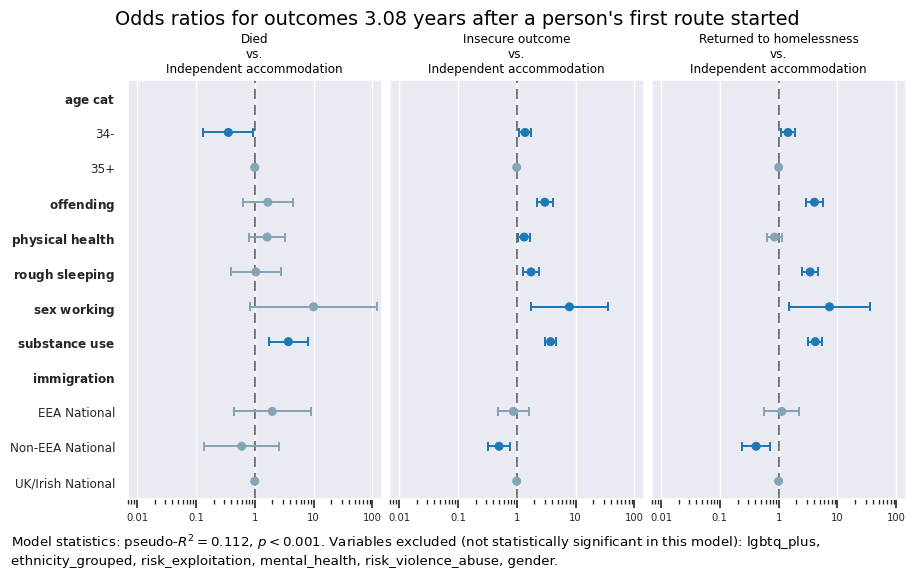

```python
figure_minor_i += 1
ref_cats_used = {k: v for k, v in ref_cats.items() if k in ["age_cat", "uk_immigration_status"]}
shorter_iv = {r"uk\ immigration\ status": "immigration"}
cols_removed = [col for col in cols_to_remove_nonMD if col != "multiple_disadvantage"]
fig_str = plot_odds_r(dv_str, dv.cat.categories[0], ref_cats_used, results_or_final, replacements=shorter_iv, cols_removed=cols_removed)
plt.show(block=False)
```

# People with multiple returns during 7.5 yrs

## Prepare DV

```python
# Get DV
dv_str = "People with multiple returns during 7.5 yrs"
dv = dv_dict[dv_str].iloc[:, 0]
```

## Prepare IVs

```python
selected_ch = {
    "demographics":  ["gender", "age_cat", "global_majority", "lgbtq_plus",
                      # "ethnicity_detailed", "ethnicity_grouped",
                      # "uk_immigration_status", "english_2nd_language",
                      ],
    "ethnicity_related": ["ethnicity_grouped", "uk_immigration_status"],
    "support_needs": ["offending", "physical_health", "mental_health", "substance_use", "multiple_disadvantage",
                      "rough_sleeping", "sex_working", "risk_violence_abuse", "risk_exploitation",],
    # "route_variables": ["referral_agency", "rt_duration_weeks", "rt_entry_point",]
}
cols_to_exclude = []
X, Xc, iv_df, iv_cols_used, ref_cats, binaries, dummy_cols = get_ivs(dv, cols_to_exclude, selected_ch)
```

## Model building

### Start with block for demographic variables

```python
block_ch = list(selected_ch.values())[0]
block_ch_d = ["(Intercept)"] + cols_with_dummies(block_ch, dummy_cols)
```

### Test associations between IVs for initial block

#### Cramer’s V

**Results**

p values indicated by asterisks: `***` if `p < 0.001`, `**` if `p < 0.01`, `*` if `p < 0.05`

```python
chi2_crv_results, disp = iv_assoc(iv_df, block_ch)
with pd.option_context("display.float_format", "{:,.3f}".format):
    display(disp)
```

| iv1 | iv2 | g | ac | gm | lp |
| --- | --- | --- | --- | --- | --- |
| gender | V | NaN | 0.151 | 0.030 | 0.223 |
|  | * | NaN | *** |  | *** |
| age_cat | V | 0.151 | NaN | 0.109 | 0.089 |
|  | * | *** | NaN | *** | *** |
| global_majority | V | 0.030 | 0.109 | NaN | 0.020 |
|  | * |  | *** | NaN |  |
| lgbtq_plus | V | 0.223 | 0.089 | 0.020 | NaN |
|  | * | *** | *** |  | NaN |

#### Variance Inflation Factor (VIF)

**Results**

```python
# Test multicollinearity with VIF
vif_data = vif(Xc[block_ch_d[1:]])
with pd.option_context("display.float_format", "{:,.3f}".format):
    display(vif_data)
```

| Feature | VIF |
| --- | --- |
| age_cat_34- | 1.400 |
| gender_Female | 1.253 |
| global_majority | 1.190 |
| lgbtq_plus | 1.109 |
| gender_Non-Binary | 1.048 |

### Logit iteration 0

**Results**

```python
cols_to_remove = []
values_to_remove = []
results, summary, results_or = binomial_regression(dv, Xc[block_ch_d], cols_to_remove, dummy_cols)
```

Logit Regression Results

| Dep. Variable: | multiple_returns | No. Observations: | 2823 |
| --- | --- | --- | --- |
| Model: | Logit | Df Residuals: | 2817 |
| Method: | MLE | Df Model: | 5 |
| Date: | Sun, 21 Jun 2026 | Pseudo R-squ.: | 0.01837 |
| Time: | 14:49:48 | Log-Likelihood: | -833.67 |
| converged: | False | LL-Null: | -849.27 |
| Covariance Type: | nonrobust | LLR p-value: | 8.574e-06 |

|  | coef | std err | z | P>\|z\| | [0.025 | 0.975] |
| --- | --- | --- | --- | --- | --- | --- |
| (Intercept) | -2.1811 | 0.096 | -22.760 | 0.000 | -2.369 | -1.993 |
| gender_Female | -0.2088 | 0.155 | -1.350 | 0.177 | -0.512 | 0.094 |
| gender_Non-Binary | -18.8147 | 9822.246 | -0.002 | 0.998 | -1.93e+04 | 1.92e+04 |
| age_cat_34- | 0.2349 | 0.137 | 1.720 | 0.085 | -0.033 | 0.503 |
| global_majority | -0.9110 | 0.196 | -4.658 | 0.000 | -1.294 | -0.528 |
| lgbtq_plus | -0.1194 | 0.280 | -0.426 | 0.670 | -0.669 | 0.430 |

| Odds Ratios | p | * | odds_r | [0.025 | 0.975] |
| --- | --- | --- | --- | --- | --- |
| gender_Non-Binary | 0.998 |  | 0.000 | 0.000 | inf |
| lgbtq_plus | 0.670 |  | 0.887 | 0.512 | 1.537 |
| gender_Female | 0.177 |  | 0.812 | 0.599 | 1.099 |
| age_cat_34- | 0.085 |  | 1.265 | 0.968 | 1.653 |
| global_majority | 0.000 | * | 0.402 | 0.274 | 0.590 |
| (Intercept) | 0.000 | * | 0.113 | 0.094 | 0.136 |

```
Psuedo R^2: 0.018365655501145772
--------------------------------------------------
```